# RESEARCH PROTOCOL Large-scale evidence generation and evaluation across a network of databases for hypertension stepped-care treatment (LEGEND-HtnStepCare)

Version: 0.0.4

# 1 List of Abbreviations

| ACEi | Angiotensin-converting enzyme inhibitor |
| --- | --- |
| ARB | Angiotensin receptor blocker |
| BB | Beta blocker |
| CCB | Calcium channel blocker |
| CDM | Common data model |
| dCCB | Dihydropyridine calcium channel blocker |
| HTN | Hypertension |
| LEGEND | Large-scale Evidence Generation and Evaluation across a Network of Databases |
| CDM | Common data model |
| MACE | Major adverse cardiovascular event |
| MDRR | Minimum detectable risk ratio |
| OHDSI | Observational Health Data Science and Informatics |
| OMOP | Observational Medical Outcomes Partnership |
| PS | Propensity score |
| RAS | Renin-angiotensin system |
| RCT | Randomized controlled trial |
| THZ | Thiazide or thiazide-like diuretics |

# 2 Responsible Parties

## 2.1 Investigators

| Investigator | Institution/Affiliation |
| --- | --- |
| Chungsoo Kim | Section of Cardiovascular Medicine, Yale School of Medicine, New Haven, CT, USA |
| Rohan Khera | Section of Cardiovascular Medicine, Yale School of Medicine, New Haven, CT, USA |
| George Hripcsak | Department of Biomedical Informatics, Columbia University, New York, NY, USA |
| Patrick B. Ryan | Observational Health Data Analytics, Janssen Research and Development, Titusville, NJ, USA |
| Harlan M. Krumholz | Section of Cardiovascular Medicine, Yale School of Medicine, New Haven, CT, USA |
| Marc A. Suchard | Department of Biostatistics, University of California, Los Angeles, Los Angeles, CA, USA |
| Yuan Lu* | Section of Cardiovascular Medicine, Yale School of Medicine, New Haven, CT, USA |

* Principal Investigator

## 2.2 Disclosures

This study is undertaken within Observational Health Data Sciences and Informatics (OHDSI), an open collaboration. **CK** reported no disclosure. **RK** is a founder of Evidence2Health, and receives grant funding from the US National Institutes of Health. **GH** receives grant funding from the US National Institutes of Health and the US Food & Drug Administration and contracts from Johnson and Johnson. **PBR** reported being an employee and shareholder of Johnson and Johnson. **HMK** received expenses and/or personal fees from UnitedHealth, Element Science, Aetna, Reality Labs, Tesseract/4Catalyst, F-Prime, the Siegfried and Jensen Law Firm, Arnold and Porter Law Firm, and Martin/Baughman Law Firm. He is a co-founder of Refactor Health and HugoHealth, and is associated with contracts, through Yale New Haven Hospital, from the Centers for Medicare & Medicaid Services and through Yale University from Johnson & Johnson. **MAS** receives grant funding from the US National Institutes of Health, the US Department of Veterans Affairs and the US Food & Drug Administration and contracts from Johnson and Johnson and IQVIA. **YL** received support from the Sentara Research Foundation, the National Heart, Lung, and Blood Institute (grant Nos. R01HL169954, R01HL169171) and the Patient-Centered Outcomes Research Institute (No. HM-2022C2-28354).

# 3 Abstract

**Background and Significance**: Hypertension is a major cause of morbidity and mortality globally and is associated with an elevated risk of cardiovascular events. Recommended antihypertensive agents can be applied to patients as a single agent (monotherapy) or in combination. In the case of combination, initial combination strategy can be considered, or stepped care strategy using a monotherapy followed by adding other agents use can be considered.

Many patients are unable to reach their target blood pressure with a monotherapy, therefore, they often use two or more medications in combination. Recent European hypertension guidelines recommend initial combination treatment for general patients with hypertension[1]; however, the US guidelines maintain a recommendation of stepped care for most patients with uncontrolled blood pressure[2]. Our team has already generated large-scale evidence comparing the effectiveness of each monotherapy[3] and initial combination therapy for hypertension[4]. Now, we will explore how the choice of step therapy medication affects patients’ cardiovascular and safety outcomes.

**Study Aims**: To determine real-world comparative effectiveness and safety of stepped care strategy of hypertension using health information encompassing millions of patients with hypertension, with a focus on individual at comorbidity risk and other key subgroups for treatment heterogeneity.

**Study Description**: We will conduct large-scale, systematic, observational studies to make pairwise comparisons of all stepped care regimens at the drug-, class- and population subgroup-level within our proposed Large-Scale Evidence Generations Across a Network of Database for Hypertension Stepped Care (LEGEND-HTNStepCare) initiative. LEGEND-HTNStepCare will leverage the Observational Health Data Sciences and Informatics (OHDSI) Community that provides access to a standing global network of administrative claims and electronic health record (EHR) data sources. LEGEND-HTNStepCare will study:

- **Population**: Adult patients with hypertension who newly added a secondary antihypertensive agent for their uncontrolled blood pressure by monotherapy
- **Exposures**: The exposure of interest is a combination of monotherapy with the following drug groups (except beta-blocker [BB]), followed by an addition of drugs from other groups. For example, patients with dihydropyridine calcium channel blocker (dCCB) added after angiotension converting enzyme inhibitor (ACEI) monotherapy.
  - Renin-angiotensin system (RAS) agents:
    - ACEI: Benazepril, Captopril, Enalapril, Fosinopril, Lisinopril, Moexipril, Perindopril, Quinapril, Ramipril, Trandolapril
    - Angiotensin receptor blocker (ARB): Azilsartan, Candesartan, Eprosartan, Irbesartan, Losartan, Olmesartan, Telmisartan, Valsartan
  - Thiazide and thiazide-like diuretics (THZ): Chlorthalidone, Hydrochlorothiazide, Indapamide, Metolazone
  - CCB:
    - dCCB: Amlodipine, Felodipine, Isradipine, Nicardipine, Nifedipine, Nisoldipine
    - non-dihypdropyridine CCB (ndCCB): Diltiazem, Verapamil
  - BB (second-line only): Atenolol, Acebutolol, Betaxolol, Bisoprolol, Carvedilol, Labetalol, Metoprolol, Nadolol, Nebivolol, Penbutolol, Pindolol, Propranolol
- **Outcomes**:
  - Primary: 3- and 4-point major adverse cardiovascular events (MACE)
  - Secondary effectiveness: Acute myocardial infarction, Hospitalization with heart failure, Sudden cardiac death, Stroke, Transient ischemic attack, Ischemic stroke, Hemorrhagic stroke, Revascularization, All-cause mortality
  - Secondary safety: Abdominal pain, Abnormal weight gain, Abnormal weight loss, Acute pancreatitis, Acute renal failure, Anaphylactic reaction, Anemia, Angioedema, Angle-closure glaucoma, Anxiety, Bone fracture, Bradycardia, Breast Cancer, Cardiac arrhythmia, Chest pain or angina, Chronic kidney disease, Cough, Decreased libido, Dementia, Depression, Diarrhea, End stage renal disease, Fall, Gastrointestinal bleeding, Genitourinary infection, Gout, Headache, Hepatic failure, Hyperkalemia, Hypoglycemia, Hypokalemia, Hypomagnesemia, Hyponatremia, Hypotension, Impotence, Insomnia, Interstitial lung disease, Lung cancer, Malignant neoplasm, Measured renal dysfunction, Nausea, Neutropenia, Non-melanoma skin cancer, Open-angle glaucoma, Peripheral edema, Photosensitivity, Pneumonitis, Pulmonary fibrosis, Rash, Rhabdomyolysis, Seizure, Stevens-Johnson syndrome/toxic epidermal necrolysis, Sucide and suicidal ideation, Syncope, Thrombocytopenia, Tinnitus, Type 2 diabetes, Vasculitis, Venous thromboembolism, Vertigo, Vomiting

For each data source and comparison, LEGEND-HTNStepCare will employ a state-of-the-art design:

- **Design**: Observational, active-comparator, new-user cohort study design

Our systematic framework will address residual confounding, publication bias and $p$-hacking using data-driven, large-scale propensity adjustment for measured confounding, a large set of negative control outcome experiments to address unmeasured and systematic bias, pre-specification and full disclosure of hypotheses tested and their results. These approaches capitalize on mature OHDSI open source resources and a large body of clinical and quantitative research that the LEGEND-HTNStepCare investigators originated and continue to drive. Finally, LEGEND-HTNStepCare is dedicated to open science and transparency and will publicly share all our analytic code from reproducible cohort definitions through turn-key software, enabling other research groups to leverage our methods, data, and results in order to verify and extend our findings.

# 4 Amendments and Updates

| Number | Date | Section of study protocol | Amendment or update | Reason |
| --- | --- | --- | --- | --- |
| 1 | 14-Apr-2024 | All | Update | Initial draft |
| 2 | 15-Feb-2025 | All | Update | Protocol refinement |
| 3 | 25-Jun-2025 | Abstract, Milestones, Main text | Update | Protocol refinement |
| 4 | 08-Jul-2025 | All | Update | Study outcome refinement |

# 5 Milestones

| Milestone | Planned / actual date |
| --- | --- |
| Protocol online release | 31-July-2025 / |
| Protocol registration | 31-July-2025 / |
| Analytic package ready | 30-Aug-2025 / |
| Collecting data partners | 30-Sep-2025 / |
| Start of analysis | 01-Oct-2025 / |
| End of analysis | 31-Dec-2025 / |
| Results presentation | 28-Feb-2026 / |

# 6 Rationale and Background

Over 100 million US adults have hypertension, a leading cause of mortality and morbidity, and 70% of them cannot achieve adequate blood pressure control with monotherapy alone[5]. Although recent clinical practice guidelines suggest initiating therapy with two drugs[1,2,6], more than 50% of people currently treated for hypertension start with a single medication [7,8]. For these patients, clinical guidelines propose adding a second antihypertensive drug for treatment escalation[2,7–9]. However, the guidelines provide little guidance on which specific agents to add for which patients. There are no large randomized controlled trials (RCTs) to guide recommendations about the choice of the second drug[[2];]. RCTs comparing antihypertensive drugs are not only expensive and time-consuming, but also cannot possibly test all the relevant drug combinations recommended by the guidelines. Given the abundance of potential strategies, there is a critical need to generate real-world evidence to guide the choice of comparators in future RCTs and to support guideline recommendations. Advances in observational research design using real-world data provide an opportunity to produce high-quality evidence through strategies that support causal inference, enhance generalizability, and minimize bias. While this evidence will not supersede RCT evidence, it can identify promising directions for trials and provide Level of Evidence B for guideline recommendations[10]. Such research can be purposeful, pre-specified, and have strategies to prevent publication bias, p-hacking, and findings due to chance. In our prior work, we have successfully demonstrated how these methods can be applied to evaluate the effectiveness and safety of first-line antihypertensive monotherapies[3,11–14]. This will be the first study that applies these massive real-world datasets and reproducible methods to comprehensively evaluate the effectiveness and safety of the second antihypertensive agents added to monotherapy as a hypertension stepped care.

# 7 Study Objectives

The overall objective in this protocol is to determine the comparative effectiveness and safety of the stepped care strategy in real-world settings. The central hypothesis is that there is heterogeneity in the effectiveness and safety of the secondary antihypertensive agent, and the optimal choice depends on patient characteristics and the initial therapy. Our long-term goal is to produce real-world evidence to inform decisions about RCTs for hypertension treatment escalation and to provide the highest quality non-randomized evidence to support guideline recommendations. The approach is distinctive due to breadth and depth of the data and the use of state-of-the-art observational research methods to produce high-quality evidence. Our preliminary data demonstrate a large variation in prescription patterns of the second agents added to monotherapy[8], providing ample opportunity to leverage practice variation to test our hypothesis. The following three specific aims are proposed:

1. To determine the comparative effectiveness of the stepped-care strategy on major cardiovascular outcomes (e.g., myocardial infarction, stroke, heart failure).
2. To determine the comparative risk of the second antihypertensive agents on potential drug-related adverse events (e.g., acute renal failure, angioedema, gastrointestinal bleeding, hyperkalemia).
3. To assess heterogeneity in effectiveness and safety of the stepped care strategy among key patient subgroups defined by age, sex, race, ethnicity, and comorbidity.

# 8 Research Methods

LEGEND-HTNStepCare will execute three systematic, large-scale observational studies of second-line antihypertensive agents to estimate the relative risks of cardiovascular effectiveness and safety outcomes.

1. The **Class-vs-Class Study** will provide all pairwise comparisons between the stepped care combination with antihypertensive agent classes to evaluate their comparative effects on cardiovascular risk (Objective 1) and patient-centered safety outcomes (Objective 2);
2. The **Drug-vs-Drug Study** will furnish head-to-head pairwise comparisons between individual agents within and across classes in stepped care combination (both Objectives 1 and 2); and
3. The **Heterogeneity Study** will refine these comparisons for hypertension patients for important subgroups (Objective 3).

In contrast to a single comparison approach, LEGEND-HTNStepCare will provide a comprehensive view of the findings and their consistency across populations, drugs, and outcomes. We will model each study on our successful collaborative research evaluating the comparative effectiveness of antihypertensive monotherapy previously published in The Lancet [3].

Table 8.1 lists the major classes of antihypertensive agents and those ingredients licensed in the U.S. within each class.

For each comparison, we are interested in the relative risk of each of the cardiovascular and safety outcomes described in Section 8.5.

Table 8.1: Antihypertensive drug classes and individual agents within each class

| ACEI | ARB | dCCB | ndCCB | Thiazide | BB |
| --- | --- | --- | --- | --- | --- |
| benazepril | azilsartan | amlodipine | diltiazem | chlorthalidone | acebutolol |
| captopril | candesartan | felodipine | verapamil | hydrochlorothiazide | atenolol |
| enalapril | eprosartan | isradipine |  | indapamide | betaxolol |
| fosinopril | irbesartan | nicardipine |  | metolazone | bisoprolol |
| lisinopril | losartan | nifedipine |  |  | carvedilol |
| moexipril | olmesartan | nisoldipine |  |  | labetalol |
| perindopril | telmisartan |  |  |  | metoprolol |
| quinapril | valsartan |  |  |  | nebivolol |
| ramipril |  |  |  |  | nadolol |
| trandolapril |  |  |  |  | penbutolol |
|  |  |  |  |  | pindolol |
|  |  |  |  |  | propranolol |

## 8.1 Study Design

For each study, we will employ an active comparator new-user cohort study design[15]. New-user cohort design is advocated as the primary design to be considered for comparative effectiveness and drug safety. By identifying patients who start a new treatment course and using therapy initiation as the start of follow-up, the new-user design models a randomized controlled trial (RCT) where treatment commences at the index study visit. Exploiting such an index date allows a clear separation of baseline patient characteristics that occur prior to the index date and are usable as covariates in the analysis without concern of inadvertently introducing mediator variables that arise between exposure and outcome. Excluding prevalent users, as those without a sufficient washout period prior to first exposure occurrence, further reduces bias due to balancing mediators on the causal pathway, time-varying hazards, and depletion of susceptibles. Our systematic framework across studies will further address residual confounding, publication bias, and p-hacking using data-driven, large-scale propensity score (PS) adjustment for measured confounding, a large set of negative control outcome experiments to address unmeasured and systematic bias, and full disclosure of hypotheses tested. Figure 8.1 below illustrates our design for all studies that the following sections describe in more detail.

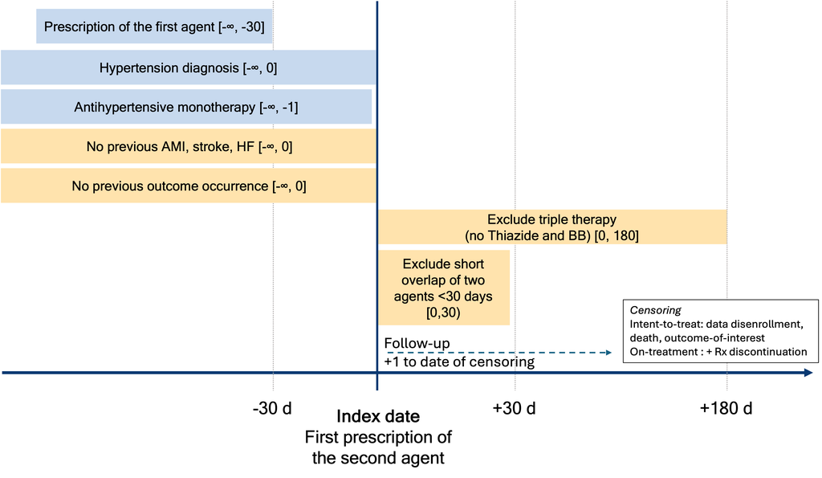

Figure 8.1: Schematic of LEGEND-HtnStepCare new-user cohort design for the Class-vs-Class, Drug-vs-Drug and Heterogeneity studies.

## 8.2 Data Sources

We will execute LEGEND-HTNStepCare as a series of OHDSI network studies. All data partners within OHDSI are encouraged to participate voluntarily and can do so conveniently, because of the community’s shared Observational Medical Outcome Partnership (OMOP) common data model (CDM) and OHDSI tool-stack [16]. Many OHDSI community data partners have already committed to participate, and we will recruit further data partners through OHDSI’s standard recruitment process, which includes protocol publication on OHDSI’s GitHub, an announcement in OHDSI’s research forum, presentation at the weekly OHDSI all-hands-on meeting, and direct requests to data holders.

Table 8.2: Committed LEGEND-HtnStepCare data sources and the populations they cover.

[output not shown]

## 8.3 Study Population

We will include all subjects in a data source who meet the inclusion criteria for the stepped care exposure cohorts. Broadly, these cohorts will consist of hypertension patients with any of ACEIs, ARBs, THZs, and CCBs previously as a first-line hypertension treatment. We describe specific definitions of exposure cohorts for each study in the following sections.

## 8.4 Exposure Comparators

### 8.4.1 Class-vs-Class Study comparisons

The **Class-vs-Class** Study will construct twenty-three exposure cohorts for secondary use of any drug ingredient within the major classes in Table 8.1. Cohort entry (index date) for each patient is their first observed exposure to any drug ingredient for secondary added drug classes (different from the class of first-line). Consistent with an idealized target trial for hypertension therapy and cardiovascular risk, inclusion criteria for patients based on the index date will include:

We will construct and compare separately cohorts patients either with

- At least 1 months use of first-line antihypertensive agents use before the index date.

In this case, a month of first-line antihypertensive agents is consistent with the 2017 AHA/ACC guidelines. We will use cohort diagnostics, such as achieving covariate balance and clinical empirical equipoise between exposure cohorts (Section 9) and stakeholder input to guide the possible need to exclude other prior diagnoses, such as heart failure.

For example, Appendix A. 1. reports the complete OHDSI cohort description for new users of TZD following the first-line ACEI. This description lists the complete specification of cohort entry events, inclusion criteria, cohort exit events, and all associated standard OMOP concept sets used in the definition. [CapR](https://github.com/OHDSI/Capr) automatically translates these definitions into network-deployable SQL source code. Significantly fewer numbers of patients strongly suggest data source-specific differences in prescribing practices that may introduce residual bias and sufficient sample sizes are required to construct effective PS models.

For each data source, we will then execute all 42 pairwise class comparisons for which the data source yields $\ge$ 1,000 patients in each arm.

### 8.4.2 Drug-vs-Drug Study comparisons

The **Drug-vs-Drug** Study will construct 1,070 exposure cohorts for new users of each drug ingredient in Table 8.1. We will apply the same cohort definition, inclusion criteria and patient count minimum as described in Section 8.4.1.

Theoretically, $\binom{1070}{2}$ = 571,915 comparisons are possible. However, we want to take into account the fact that Class-vs-Class comparisons will be performed and practical situation when stepped care is performed. Therefore, we will focus primary clinical interpretation and scientific publishing to the 3,400 comparisons where the first-line drug is the same and the second line drug is a different ingredient within the same class, e.g, Acebutolol following first-line amlodipine vs. Atenolol following first-line amlodipine.

Appendix A.5 reports the complete OHDSI cohort description for new-users of acebutolol added to amlodipine monotherapy. Again, we programmatically construct all new-user drug-level cohort and automatically translate into SQL.

### 8.4.3 Heterogeneity Study comparisons

The **Heterogeneity Study** will further stratify all class- and drug-level exposure cohorts in Section 8.4.1 and 8.4.2 by clinically important patient characteristics that modify cardiovascular risk of relative treatment heterogeneity to provide patient-focused treatment recommendations. These factors will include:

- Age (18 - 44 / 45 - 64 / $\ge$ 65 at the index date)
- Sex (women / men)
- Race (White / African American or black / Hispanic)

Appendix A. 3 presents complete OHDSI cohort specifications for these subgroups.

### 8.4.4 Validation

We will validate exposure cohorts and aggregate drug utilization using comprehensive cohort characterization tools against data sources. Chief among these tools stands OHDSI’s CohortDiagnostics package (https://github.com/OHDSI/CohortDiagnostics). For any cohort and data source mapped to OMOP CDM, this package systematically generates incidence new-user rates (stratified by age, sex, and calendar year), cohort characteristics (all comorbidities, drug use, procedures, health utilization) and the actual codes found in the data triggering the various rules in the cohort definitions. This can allow researchers and stakeholders to understand the heterogeneity of source coding for exposures and health outcomes as well as the impact of various inclusion criteria on overall cohort counts (details described in Section 9).

## 8.5 Outcomes

We originally identified outcomes for LEGEND-HTN from clinical trial endpoints from clinical guidelines, and systematic reviews. We augmented these with adverse events from the US’s structured product labels of hypertension drugs. For each outcome, we developed an operational phenotype definition to determine if observational data could, in fact, support evaluation of the outcome. We used the same approach to design, implement, and evaluate all phenotypes. Specifically, clinical guidelines and systematic review of clinical trials of hypertension treatments informed our clinical definition of cardiovascular outcomes. We developed all exposure cohorts according to the definition itself through ATLAS and CapR. We did not perform source record verification or other validation methods.

- 3-point MACE including acute myocardial infarction, stroke, and sudden cardiac death, and
- 4-point MACE that additionally includes heart failure hospitalization.

Secondary outcomes include:

- individual MACE components - acute myocardial infarction, stroke (transient ischemic attack, ischemic stroke, and hemorrhagic stroke), sudden cardiac death, and hospitalization with heart failure
- All-cause death

In data sources with laboratory measurements, secondary outcomes further include:

- Blood pressure control (systolic blood pressure < 130 mmHg and diastolic blood pressure < 80 mmHg)

We will also study antihypertensive agents’ adverse events and safety concerns highlighted in the 2017 ACC/AHA guidelines and from RCTs, including SPRINT trial[17].

To assess across-source consistency and general clinical validity, we will characterize outcome incidence, stratified by age, sex, and index year for each data source.

We will employ the same level of systematic rigor in studying outcomes regardless of their primary or secondary label.

A majority of outcome definitions have been previously implemented and validated in our own work [18–24] based heavily on prior development by others (see prior development in Table 8.3).

To assess across-source consistency and general clinical validity, we will characterize outcome incidence, stratified by age, sex and index year for each data source.

Table 8.3: LEGEND-HtnSteppedCare study outcomes

| Phenotype | Brief logical description | Prior development |
| --- | --- | --- |
| **Cardiovascular outcomes** |  |  |
| 3-point MACE | Condition record of acute myocardial infarction, hemorrhagic or ischemic stroke or sudden cardiac death during an inpatient or ER visit | [25–37] |
| 4-point MACE | 3-Point MACE $+$ inpatient or ER visit (hospitalization) with heart failure condition record | [20,25–43] |
| Acute myocardial infarction | Condition record of acute myocardial infarction during an inpatient or ER vist | [25–30] |
| Stroke | Condition record of hemorrhagic or ischemic stroke during an inpatient or ER visit | [31–36] |
| Hospitalization with heart failure | Inpatient or ER visit with heart failure condition record | [20,38–43] |
| Sudden cardiac death | Condition record of sudden cardiac death during an inpatient or ER visit | [28,37] |
| Transient ischemic attack | Transient ischemic attack condition record during an inpatient or ER visit; successive records with > 30 day gap are considered independent episodes | [31,36] |
| Hemorrhagic stroke | Intracranial, cerebral or subarachnoid hemorrhage condition record during an inpatient or ER visit; successive records with > 180 day gap are considered independent episodes | [31–35] |
| Ischemic stroke | Ischemic stroke condition record during an inpatient or ER visit; successive records with > 180 day gap are considered independent episodes | [26,28,29,31,36] |
| Revascularization | Procedure record of percutaneous coronary intervention or coronary artery bypass grafting during an inpatient or ER visit | [19] |
| All-cause mortality | Death record of any type | [28,44,45] |
| **Patient-centered safety outcomes** |  |  |
| Abdominal pain | Abdominal pain condition record of any type; successive records with > 90 day gap are considered independent episodes | [46–48] |
| Abnormal weight gain | Abnormal weight gain record of any type; successive records with > 90 day gap are considered independent episodes; note, weight measurements not used | [49] |
| Abnormal weight loss | Abnormal weight loss record of any type; successive records with > 90 day gap are considered independent episodes; note, weight measurements not used | [50] |
| Acute pancreatitis | Condition record of acute pancreatitis during an inpatient or ER visit | [51–54] |
| Acute renal failure | Condition record of acute renal failure during an inpatient or ER visit | [22,55–62] |
| Anaphylactoid reaction | Anaphylactoid reaction condition record during an inpatient or ER visit; successive records with >7 day gap are considered independent episodes | [63,64] |
| Anemia | The first condition record of anemia | [65–67] |
| Angioedema | Angioedema condition record during an inpatient or ER visit; successive records with >7 day gap are considered independent episodes | [68,69] |
| Anxiety | The first condition record of anxiety, which is followed by another anxiety condition record or a drug used to treat anxiety | [70–73] |
| Bone fracture | Bone fracture condition record of any type; successive records with > 90 day gap are considered independent episodes |  |
| Bradycardia | The first condition record of bradycardia, which is followed by another bradycardia condition record | [74,75] |
| Cardiac arrhythmia | The first condition record of cardiac arrhythmia, which is followed by another cardiac arrhythmia condition record, at least two drug records for a drug used to treat arrhythmias, or a procedure to tr… | [37,76–79] |
| Chest pain | The first condition record of chest pain or angina | [80] |
| Chronic kidney disease | The first condition record of chronic kidney disease, which is followed by either another chronic kidney disease condition record or a dialysis procedure or observation | [57,81–88] |
| Cough | Cough condition record of any type; successive records with > 90 day gap are considered independent episodes | [89,90] |
| Decreased libido | The first condition record of decreased libido | [91] |
| Dementia | The first condition record of dementia | [92–98] |
| Depression | The first condition record of depression, which is followed by another depression condition record, at least two drugs used to treat depression without another indication, or two psychotherapy procedu… | [71,72,98–102] |
| Diarrhea | Diarrhea condition record of any type; successive records with > 30 day gap are considered independent episodes | [103–105] |
| End stage renal disease | End stage renal disease (ESRD) is defined by at least one diagnosis in any setting, followed by at least one additional diagnosis or a dialysis-related procedure within 90 days | [54,86,106] |
| Fall | Fall condition record of any type; successive records with >180 day gap are considered independent episodes | [107–109] |
| Gastrointestinal bleeding | Gastrointestinal hemorrhage condition record during an inpatient or ER visit; successive records with > 30 day gap are considered independent episodes | [110–116] |
| Genitourinary infection | Condition record of any type of genital or urinary tract infection during an outpatient or ER vists | [117] |
| Gout | The first condition record of gout | [118–121] |
| Headache | Headache condition record of any type; successive records with > 30 day gap are considered independent episodes | [122,123] |
| Hepatic failure | The first condition record of hepatic failure, necrosis, or coma | [124–131] |
| Hyperkalemia | Condition record for hyperkalemia or potassium measurements > 5.6 mmol/L; successive records with >90 day gap are considered independent episodes | [132–134] |
| Hypoglycemia | Hypoglycemia condition record of any type; successive records with > 90 day gap are considered independent episodes | [135] |
| Hypokalemia | Hypokalemia condition record of any type; successive records with > 90 day gap are considered independent episodes | [136] |
| Hypomagnesemia | Hypomagnesemia condition record of any type; successive records with > 90 day gap are considered independent episodes | [137,138] |
| Hyponatremia | Hyponatremia condition record of any type; successive records with > 90 day gap are considered independent episodes | [139,140] |
| Hypotension | Hypotension condition record of any type; successive records with > 90 day gap are considered independent episodes | [141] |
| Impotence | The first condition record of impotence | [142–145] |
| Joint pain | Joint pain condition record of any type; successive records with > 90 days gap are considered independent episodes |  |
| Lower extremity amputation | Procedure record of below knee lower extremity amputation during inpatient or outpatient visit | [20,23] |
| Malignant neoplasm | First occurrence of malignant neoplasm, followed by at least one additional diagnosis of the same type (melanoma, bladder, brain, breast, colon and rectum, kidney, leukemia, liver, lung, lymphoma, mul… | [146–158] |
| Measured renal dysfunction | First creatinine measurement with value > 3 mg/dL | [62] |
| Nausea | Nausea condition record of any type; successive records with > 30 day gap are considered independent episodes | [110,159,160] |
| Neutropenia or agranulocytosis | The first condition record of neutropenia or agranulocytosis | [161,162] |
| Peripheral edema | Edema condition record of any type; successive records with > 180 day gap are considered independent episodes |  |
| Photosensitivity | Condition record of drug-induced photosensitivity during any type of visit |  |
| Rash | Rash condition record of any type; successive records with >90 day gap are considered independent episodes | [68] |
| Rhabdomyolysis | Rhabdomyolysis condition record or muscle disorder condition record with creatine measurement 5*ULN during an inpatient or ER visit; successive records with >90 day gap are considered independent epis… | [163,164] |
| Syncope | Syncope condition record of any type; successive records with > 180 day gap are considered independent episodes | [141] |
| Thrombocytopenia | The first condition record of thrombocytopenia | [165–167] |
| Type 2 diabetes mellitus | The first condition record of Type 2 Diabetes Mellitus, which is followed by another Type 2 Diabetes Mellitus condition record, at least 2 drugs used to treat Type 2 diabetes, or at least 2 HbA1c meas… | [98,168–170] |
| Vasculitis | The first condition record of vasculitis, which is followed by another vasculitis condition record or drug to treat vasculiits | [171,172] |
| Venous thromboembolism | Venous thromboembolism condition record of any type; successive records with > 180 day gap are considered independent episodes | [173–176] |
| Vertigo | The first condition record of vertigo | [177] |
| Vomiting | Vomiting condition record of any type; successive records with > 30 day gap are considered independent episodes | [110,159,160] |

## 8.6 Analysis

### 8.6.1 Contemporary utilization of drug classes and individual agents

For all cohorts in the three studies, we will describe overall utilization as well as temporal trends in the use of each drug class and agents within the class. Further, we will evaluate these trends in patient groups by age (18-44 / 45-64 / $\ge$ 65 years), sex, race, and geographic regions. These data will provide insight into the current patterns of use ad possible disparities. These data are critical to guide the real-world application of treatment decision pathways for the treatment of patients with hypertension.

Specifically, we will calculate and validate aggregate drug utilization using the OHDSI’s CohortDiagnostics package against data sources. The CohortDiagnostics package works in two steps: 1) Generate the utilization results and diagnostics against a data source, and 2) Explore the generated utilization and diagnostics in a user-friendly graphical interface R-Shiny app. Through the interface, one can explore patient profiles of a random sample of subjects in a cohort. These diagnostics provide a consistent methodology to evaluate cohort definition and phenotype algorithms across a variety of observational databases. This will enable researchers and stakeholders to become informed on the appropriateness of including specific data sources within analyses, exposing potential risks related to heterogeneity and variability in patient care delivery that, when not addressed in the design, could result in errors such as high correlated covariates in PS matching of a target and a comparator cohort. Thus, the added value of this approach is twofold in terms of exposing data quality for a study question and ensuring face validity checks are performed on proposed covariates to be used for balancing PS.

### 8.6.2 Relative risk of cardiovascular and patient-centered outcomes

We will execute a systematic process to estimate the relative risk of cardiovascular and patient-centered outcomes between new users of second-line HTN agents. The process will adjust for measured confounding, control for further residual (unmeasured) bias and accommodate important design choices to best emulate the nearly impossible to execute, idealized RCT that our stakeholders envision across data source populations, comparators, outcomes, and subgroups.

To adjust for potential measured confounding and improve the balance between cohorts, we will build large-scale PS models for each pairwise comparison and data source using a consistent data-driven process through regularized regression. This process engineers a large set of predefined baseline patient characteristics, including age, sex, race, index month/year, other demographics, prior conditions, drug exposures, procedures, laboratory measurements, and health service utilization behaviors, to provide the most accurate prediction of treatment and balance patient cohorts across many characteristics. Construction of condition, drug, procedures and observations include occurrences within 365, 180, and 30 days prior to index date and are aggregated at several SNOMED (condition) and ingredient/ATC class (drug) levels. Other demographic measures include comorbidity risk scores (Charlson comorbidity index, DCSI, CHADS2, CHAD2VASc). From prior work, feature counts have ranged in the 1,000s-10,000s, and these large-scale PS models have outperformed hdPS in simulation and real-world examples [178].

We will:

- Exclude patients who have experienced the outcome prior to their index date,
- Stratify and variable-ratio match patients by PS, and
- Use Cox proportional hazards models

to estimate hazard ratios (HRs) between alternative target and comparator treatments for the risk of each outcome in each data source. In addition, we will perform a sensitivity analysis that does not exclude individuals who previously experienced a blood pressure control outcome before the index date. The regression will condition on the PS strata/matching-unit with treatment allocation as the sole explanatory variable and censor patients at the end of their time-at-risk (TAR) or data source observation period. We will prefer stratification over matching if both sufficiently balance patients (see Section 9), as the former optimizes patient inclusions and thus generalizability.

- Intent-to-treat (TAR: index + 1 → end of observation) captures both direct treatment effects and (long-term) behavioral/treatment changes that initial assignment triggers [179];
- On-treatment-1 (TAR: index + 1 → treatment discontinuation) is more patient-centered [180] and captures direct treatment effect while allowing for escalation with additional antihypertensive agents; and
- On-treatment-2 (TAR: index + 1 → discontinuation or escalation with other antihypertensive agents) carries the least possible confounding with other concurrent antihypertensive agents.
- Landmark design (TAR: index + 365 → end of observation) excludes patients who lose follow-up or experience the outcome within the first year, to reduce time-related bias [181].

We will aggregate HR estimates across data sources to produce meta-analytic estimates using a random-effects meta-analysis. The classic meta-analysis assumes that per-data source likelihoods are approximately normally distributed. This assumption fails when outcomes are rare as we expect for some safety events. Here, our recent research shows that as the number of data sources increases, the non-normality effect increases to where coverage of 95% confidence intervals (CIs) can be as low as 5%. To counter this, we will also apply a Bayesian meta-analysis model that neither assumes normality nor requires patient-level data sharing by building on composite likelihood methods and enables us to introduce appropriate overlap weights between data sources.

Residual study bias from unmeasured and systematic sources often remains in observational studies even after controlling for measured confounding through PS-adjustment. For each comparison-outcome effect, we will conduct negative control (falsification) outcome experiments, where the null hypothesis of no effect is believed to be true, using approximately 100 controls. We identified these controls through a data-rich algorithm that identifies prevalent OMOP condition concept occurrences that lack evidence of association with exposures in published literature, drug-product labeling and spontaneous reports, and were then adjudicated by clinical review. We previously validated 60 of the controls in LEGEND-HTN study. Appendix C lists these negative controls and their OMOP condition concept IDs. Using the empirical null distributions from these experiments, we will calibrate each study effect HR estimate, its 95% CI and the p-value to reject the null hypothesis of no differential effect. We will declare an HR as significantly different from no effect when its calibrated p < 0.05 without correcting for multiple testing. Finally, blinded to all trial results, study investigators will evaluate study diagnostics for all comparisons to assess if they were likely to yield unbiased estimates (Section 9).

### 8.6.3 Sensitivity analyses and missingness

Because of the potential confounding effect of blood pressure at baseline between treatment choice and outcomes and to better understand the impact of limited blood pressure level measurements on effectiveness and safety estimation that arises in some EHR data, we will perform pre-specified sensitivity analyses for all studies within data sources that contain reliable blood pressure measurements. Within a study, for each exposure pair, we will first rebuild PS models where we additionally include baseline blood pressure as patient characteristics, stratify or matching patients under the new PS models that directly adjust for potential confounding by blood pressure and then estimate effectiveness and safety HRs.

A limitation of the Cox model is that no doubly robust procedure is believed to exist for estimating HRs, due to their non-collapsibility. Doubly robust procedures combine baseline patient characteristic-adjusted outcome and PS models to control for confounding and, in theory, remain unbiased when either (but not necessarily both) model is correctly specified. Doubly robust procedures do exist for hazard differences, and we will validate the appropriateness of our univariable Cox modelling by comparing estimate differences under an additive hazards model with and without doubly robust-adjustment. In practice, however, neither the outcome nor the PS model is correctly specified, leading to systematic error in the observational setting.

Missing data of potential concern are patient demographics (sex, age, race) for our inclusion criteria. We will include only individuals whose baseline eligibility can be characterized that will most notably influence race subgroup assessments in the **Heterogeneity Study**. No further missing data can arise in our large-scale PS models because all features, with the exception of demographics, simply indicate the presence or absence of health records in a given time-period. Finally, we limit the impact of missing data, such as prescription information, relating to exposure time-at-risk by entertaining multiple definitions [182]. In all reports, we will clearly tabulate numbers of missing observations and patient attrition.

# 9 Sample Size and Study Power

Within each data source, we will execute all comparisons with $\ge$ 1,000 eligible patients per arm. Blinded to effect estimates, investigators and stakeholders will evaluate extensive study diagnostics for each comparison to assess reliability and generalizability, and only report risk estimates that pass [183–185]. These diagnostics will include

1. Minimum detectable risk ratio (MDRR) as a typical proxy for power,
2. Preference score distributions to evaluate empirical equipoise [186] and population generalizability,
3. Extensive patient characteristics to evaluate cohort balance before and after PS-adjustment,
4. Negative control calibration plots to assess residual bias and systematic error

We will define cohorts to stand in empirical equipoise if the majority of patients carry preference scores between 0.3 and 0.7 and to achieve balance if all after-adjustment characteristics return absolute standardized mean differences $<$ 0.1 [187].

# 10 Strengths and Limitations

## 10.1 Strengths

The strengths of the LEGEND-HTNStepCare study stem from the research question, the methodologies employed, and our commitment to open science: * This study is poised to be the first to systematically address the critical clinical question: What are the comparative benefits and risks of adding different second antihypertensive drugs to monotherapy in patients with hypertension? * We are employing massive, diverse real-world datasets and cutting-edge observational research methods to provide comprehensive estimates of effectiveness and safety for second antihypertensive drugs added to monotherapy. These tools have previously evaluated antihypertensive monotherapies, but have not been used to assess the addition of a second drug when monotherapy is insufficient for managing hypertension. * Unlike typical observational research, this study will minimize residual bias by employing reproducible methods to mitigate observed confounding. We will enhance transparency by reporting diagnostics such as empirical equipoise and covariate balance, and by using a large set of control outcomes to detect and correct for any remaining systematic errors. This approach marks a significant advancement in observational research. * We will assess antihypertensive medications at both class and individual drug levels, evaluating effectiveness and safety across patient subgroups defined by demographic and clinical characteristics. This comprehensive approach has not been adequately explored in previous studies. * Our commitment to Open Science includes making all study artifacts—such as the study protocol, analytical code, and full results—publicly available. We will also provide real-time access to these materials for external analysis and interpretation, a practice that goes beyond the transparency typically seen in past studies.

## 10.2 Limitations

Some additional aspects merit consideration: * Residual Confounding: Despite our sophisticated analytic approach and diagnostics, residual confounding remains a possibility. We anticipate that ongoing and future randomized controlled trials (RCTs) will shed further light on this issue. We will use two distinct methods to triangulate residual confounding: large-scale propensity score (PS) adjustment and the use of numerous negative controls. Our PS adjustment incorporates tens of thousands of baseline covariates for matching and stratification. * Medication Adherence: Merely having a prescription does not guarantee medication consumption. We will conduct sensitivity analyses using pharmacy refill data to infer adherence, and perform on-treatment analysis to adjust for potential discrepancies in adherence across different drug classes. * Dose Variability: We will conduct sensitivity analyses among patients maintaining consistent dosing throughout the on-treatment period to account for differences in dosing and potency. * Medication Indication: Some patients, like those with congestive heart failure, might be prescribed antihypertensive medications for reasons other than lowering blood pressure. We will exclude such patients from the study cohort during sensitivity analyses. * Informative Censoring: There is a risk that censoring at the end of the on-treatment periods could be informative. We will utilize extensive negative controls to detect and adjust for any potential bias introduced by this censoring. * Overlap of Patients Across Databases: While our study is designed to minimize patient overlap across databases by adhering to federated analytic principles, we acknowledge that some overlap may occur. We will ensure that patient experiences are reported distinctly for each database.

# 11 Protection of Human Subjects

LEGEND-HTNStepCare does not involve human subject research. The project does, however, use human data collected during routine healthcare provision. Most often the data are de-identified within data source. All data partners executing the LEGEND-HtnStepCare studies within their data sources will have received institutional review board (IRB) approval or waiver for participation in accordance to their institutional governance prior to execution (see Table 11.1). LEGEND-HTNStepCare executes across a federated and distributed data network, where analysis code is sent to participating data partners and only aggregate summary statistics are returned, with no sharing of patient-level data between organizations.

Table 11.1: IRB approval or waiver statement from partners.

| Data source | Statement |
| --- | --- |
| Yale New Haven Health System (YNHHS) | Use of the YNHHS EHR data source was approved by the Yale University Institutional Review Board as an OHDSI network study (IRB#2000026013). |
| Sentara Healthcare System (Sentara) | Use of the Sentara EHR data source was approved by the Senatara Health Institutional Review Board as an OHDSI network study (IRB# pending). |
| Department of Veterans Affairs (VA) | Use of the VA EHR data source was approved by the Department of Veterans Affairs Central Institutional Review Board and was determined to meet the criteria for exemption under Exemption category4(3) a… |

# 12 Management and Reporting of Adverse Events and Adverse Reactions

LEGEND-HtnStepCare uses coded data that already exist in electronic databases. In these types of databases, it is not usually possible to link (i.e., identify a potential causal association between) a particular product and medical event for any specific individual. Thus, the minimum criteria for reporting an adverse event (i.e., identifiable patient, identifiable reporter, a suspect product and event) are not available and adverse events are not reportable as individual adverse event reports. The study results will be assessed for medically important findings.

# 13 Plans for Disseminating and Communicating Study Results

Open science aims to make scientific research, including its data process and software, and its dissemination, through publication and presentation, accessible to all levels of an inquiring society, amateur or professional [188] and is a governing principle of LEGEND-HtnStepCare. Open science delivers reproducible, transparent and reliable evidence. All aspects of LEGEND-HtnStepCare (except private patient data) will be open and we will actively encourage other interested researchers, clinicians and patients to participate. This differs fundamentally from traditional studies that rarely open their analytic tools or share all result artifacts, and inform the community about hard-to-verify conclusions at completion.

## 13.1 Transparent and re-usable research tools

We will publicly register this protocol and announce its availability for feedback from stakeholders, the OHDSI community and within clinical professional societies. This protocol will link to open source code for all steps to generating diagnostics, effect estimates, figures and tables. Such transparency is possible because we will construct our studies on top of the OHDSI toolstack of open source software tools that are community developed and rigorously tested [184]. We will publicly host LEGEND-HtnStepCare source code at (https://github.com/ohdsi-studies/LegendHtnStepCare), allowing public contribution and review, and free re-use for anyone’s future research.

## 13.2 Continuous sharing of results

LEGEND-HtnStepCare embodies a new approach to generating evidence from healthcare data that overcome weaknesses in the current process of answering and publishing (or not) one question at a time. Generating evidence for thousands of research and control questions using a systematic process enables us to not only evaluate that process and the coherence and consistency of the evidence, but also to avoid $p$-hacking and publication bias [183]. We will store and openly communicate all of these results as they become available using a user-friendly web-based app that serves up all descriptive statistics, study diagnostics and effect estimates for each cohort comparison and outcome. Open access to this app will be through a general public facing LEGEND-HtnStepCare webpage.

## 13.3 Scientific meetings and publications

We will deliver multiple presentations annually at scientific venues including the annual meetings of the American College of Cardiology, American Heart Association and American Medical Informatics Association. We will also prepare multiple scientific publications for clinical, informatics and statistical journals.

## 13.4 General public

We believe in sharing our findings that will guide clinical care with the general public. LEGEND-HtnStepCare will use social-media (e.g., X and LinkedIn) to facilitate this. With dedicated support from the OHDSI communications specialist, we will deliver regular press releases at key project stages, distributed via the extensive media networks of Yale, UCLA, and Columbia.

# References

1

Mancia G, Kreutz R, Brunström M, *et al.* 2023 ESH guidelines for the management of arterial hypertension the task force for the management of arterial hypertension of the european society of hypertension: Endorsed by the international society of hypertension (ISH) and the european renal association (ERA). *Journal of Hypertension* 2023;**41**:1874–2071. doi:10.1097/hjh.0000000000003480

2

Whelton PK, Carey RM, Aronow WS, *et al.* 2017 ACC/AHA/AAPA/ABC/ACPM/AGS/APhA/ASH/ASPC/NMA/PCNA guideline for the prevention, detection, evaluation, and management of high blood pressure in adults: A report of the american college of cardiology/american heart association task force on clinical practice guidelines. *Hypertension* 2018;**71**:e13–115. doi:doi:10.1161/HYP.0000000000000065

3

Suchard MA, Schuemie MJ, Krumholz HM, *et al.* Comprehensive comparative effectiveness and safety of first-line antihypertensive drug classes: A systematic, multinational, large-scale analysis. *The Lancet* 2019;**394**:1816–26. doi:https://doi.org/10.1016/S0140-6736(19)32317-7

4

You SC, Jung S, Swerdel JN, *et al.* Comparison of first-line dual combination treatments in hypertension: Real-world evidence from multinational heterogeneous cohorts. *Korean Circ J* 2020;**50**:52–68.https://doi.org/10.4070/kcj.2019.0173

5

Hypertension cascade: Hypertension prevalence, treatment and control estimates among US adults aged 18 years and older applying the criteria from the american college of cardiology and american heart association’s 2017 hypertension guideline-NHANES 2017-2020. 2023;**2024**.https://millionhearts.hhs.gov/data-reports/hypertension-prevalence.html

6

Unger T, Borghi C, Charchar F, *et al.* 2020 international society of hypertension global hypertension practice guidelines. *Hypertension* 2020;**75**:1334–57. doi:doi:10.1161/HYPERTENSIONAHA.120.15026

7

Hripcsak G, Ryan PB, Duke JD, *et al.* Characterizing treatment pathways at scale using the OHDSI network. *Proceedings of the National Academy of Sciences* 2016;**113**:7329–36. doi:doi:10.1073/pnas.1510502113

8

Lu Y, Van Zandt M, Liu Y, *et al.* Analysis of dual combination therapies used in treatment of hypertension in a multinational cohort. *JAMA Network Open* 2022;**5**:e223877–7. doi:10.1001/jamanetworkopen.2022.3877

9

James PA, Oparil S, Carter BL, *et al.* 2014 evidence-based guideline for the management of high blood pressure in adults: Report from the panel members appointed to the eighth joint national committee (JNC 8). *JAMA* 2014;**311**:507–20. doi:10.1001/jama.2013.284427

10

Sheldrick RC. Randomized trials vs real-world evidence: How can both inform decision-making? *JAMA* 2023;**329**:1352–3. doi:10.1001/jama.2023.4855

11

Anand TV, Bu F, Schuemie MJ, *et al.* Comparative safety and effectiveness of angiotensin converting enzyme inhibitors and thiazides and thiazide-like diuretics under strict monotherapy. *The Journal of Clinical Hypertension* 2024;**n/a**. doi:https://doi.org/10.1111/jch.14793

12

You SC, Krumholz HM, Suchard MA, *et al.* Comprehensive comparative effectiveness and safety of first-line β-blocker monotherapy in hypertensive patients. *Hypertension* 2021;**77**:1528–38. doi:doi:10.1161/HYPERTENSIONAHA.120.16402

13

Chen R, Suchard MA, Krumholz HM, *et al.* Comparative first-line effectiveness and safety of ACE (angiotensin-converting enzyme) inhibitors and angiotensin receptor blockers: A multinational cohort study. *Hypertension* 2021;**78**:591–603. doi:doi:10.1161/HYPERTENSIONAHA.120.16667

14

Hripcsak G, Suchard MA, Shea S, *et al.* Comparison of cardiovascular and safety outcomes of chlorthalidone vs hydrochlorothiazide to treat hypertension. *JAMA Internal Medicine* 2020;**180**:542–51. doi:10.1001/jamainternmed.2019.7454

15

Lund JL, Richardson DB, Stürmer T. The active comparator, new user study design in pharmacoepidemiology: Historical foundations and contemporary application. *Current Epidemiology Reports* 2015;**2**:221–8. doi:10.1007/s40471-015-0053-5

16

Schuemie M, Reps J, Black A, *et al.* Health-analytics data to evidence suite (HADES): Open-source software for observational research. *Stud Health Technol Inform* 2024;**310**:966–70. doi:10.3233/shti231108

17

null null. A randomized trial of intensive versus standard blood-pressure control. *New England Journal of Medicine* 2015;**373**:2103–16. doi:10.1056/NEJMoa1511939

18

Suchard MA, Schuemie MJ, Krumholz HM, *et al.* Comprehensive comparative effectiveness and safety of first-line antihypertensive drug classes: A systematic, multinational, large-scale analysis. *The Lancet* 2019;**394**:1816–26.

19

You SC, Rho Y, Bikdeli B, *et al.* Association of ticagrelor versus clopidogrel with net adverse clinical events in patients with acute coronary syndrome undergoing percutaneous coronary intervention in clinical practice. *Journal of the American Medical Association*;in press.

20

Ryan PB, Buse JB, Schuemie MJ, *et al.* Comparative effectiveness of canagliflozin, SGLT2 inhibitors and non-SGLT2 inhibitors on the risk of hospitalization for heart failure and amputation in patients with type 2 diabetes mellitus: A real-world meta-analysis of 4 observational databases (OBSERVE-4D). *Diabetes, Obesity & Metabolism* 2018;**20**:2585–2597. doi: 10.1111/dom.13424. Epub 2018 Jun 25.

21

Wang Y, Desai M, Ryan PB, *et al.* Incidence of diabetic ketoacidosis among patients with type 2 diabetes mellitus treated with SGLT2 inhibitors and other antihyperglycemic agents. *Diabetes Research and Clinical Practice* 2017;**128**:83–90.

22

Weinstein RB, Ryan PB, Berlin JA, *et al.* Channeling bias in the analysis of risk of myocardial infarction, stroke, gastrointestinal bleeding, and acute renal failure with the use of paracetamol compared with ibuprofen. *Drug Safety: An International Journal of Medical Toxicology and Drug Experience* 2020.

23

Yuan Z, DeFalco FJ, Ryan PB, *et al.* Risk of lower extremity amputations in people with type 2 diabetes mellitus treated with sodium-glucose co-transporter-2 inhibitors in the USA: A retrospective cohort study. *Diabetes, Obesity & Metabolism* 2018;**20**:582–9.

24

Khera R, Aminorroaya A, Dhingra LS, *et al.* Comparative effectiveness of second-line antihyperglycemic agents for cardiovascular outcomes: A multinational, federated analysis of LEGEND-T2DM. *Journal of the American College of Cardiology* 2024;**84**:904–17. doi:https://doi.org/10.1016/j.jacc.2024.05.069

25

Ammann EM, Schweizer ML, Robinson JG, *et al.* Chart validation of inpatient ICD-9-CM administrative diagnosis codes for acute myocardial infarction (AMI) among intravenous immune globulin (IGIV) users in the sentinel distributed database. *Pharmacoepidemiology and Drug Safety* 2018;**27**:398–404. doi: 10.1002/pds.4398. Epub 2018 Feb 15.

26

Floyd JS, Blondon M, Moore KP, *et al.* Validation of methods for assessing cardiovascular disease using electronic health data in a cohort of veterans with diabetes. *Pharmacoepidemiology and Drug Safety* 2016;**25**:467–71. doi: 10.1002/pds.3921. Epub 2015 Nov 11.

27

Rubbo B, Fitzpatrick NK, Denaxas S, *et al.* Use of electronic health records to ascertain, validate and phenotype acute myocardial infarction: A systematic review and recommendations. *International Journal of Cardiology* 2015;**187:705-11.**:10.1016/j.ijcard.2015.03.075. Epub 2015 Mar 5.

28

Singh S, Fouayzi H, Anzuoni K, *et al.* Diagnostic algorithms for cardiovascular death in administrative claims databases: A systematic review. *Drug Safety: An International Journal of Medical Toxicology and Drug Experience* 2018;**23**:018–0754.

29

Wahl PM, Rodgers K, Schneeweiss S, *et al.* Validation of claims-based diagnostic and procedure codes for cardiovascular and gastrointestinal serious adverse events in a commercially-insured population. *Pharmacoepidemiology and Drug Safety* 2010;**19**:596–603. doi: 10.1002/pds.1924.

30

Normand SL, Morris CN, Fung KS, *et al.* Development and validation of a claims based index for adjusting for risk of mortality: The case of acute myocardial infarction. *Journal of Clinical Epidemiology* 1995;**48**:229–43.

31

Andrade SE, Harrold LR, Tjia J, *et al.* A systematic review of validated methods for identifying cerebrovascular accident or transient ischemic attack using administrative data. *Pharmacoepidemiology and Drug Safety* 2012;**21**:100–28. doi: 10.1002/pds.2312.

32

Park TH, Choi JC. Validation of stroke and thrombolytic therapy in korean national health insurance claim data. *Journal of Clinical Neurology* 2016;**12**:42–8. doi: 10.3988/jcn.2016.12.1.42. Epub 2015 Sep 11.

33

Gon Y, Kabata D, Yamamoto K, *et al.* Validation of an algorithm that determines stroke diagnostic code accuracy in a japanese hospital-based cancer registry using electronic medical records. *BMC Medical Informatics and Decision Making* 2017;**17**:157. doi: 10.1186/s12911-017-0554-x.

34

Sung SF, Hsieh CY, Lin HJ, *et al.* Validation of algorithms to identify stroke risk factors in patients with acute ischemic stroke, transient ischemic attack, or intracerebral hemorrhage in an administrative claims database. *International Journal of Cardiology* 2016;**215:277-82.**:10.1016/j.ijcard.2016.04.069. Epub 2016 Apr 14.

35

Tu K, Wang M, Young J, *et al.* Validity of administrative data for identifying patients who have had a stroke or transient ischemic attack using EMRALD as a reference standard. *The Canadian Journal of Cardiology* 2013;**29**:1388–94. doi: 10.1016/j.cjca.2013.07.676. Epub 2013 Sep 26.

36

Yuan Z, Voss EA, DeFalco FJ, *et al.* Risk prediction for ischemic stroke and transient ischemic attack in patients without atrial fibrillation: A retrospective cohort study. *Journal of Stroke and Cerebrovascular Diseases: The Official Journal of National Stroke Association* 2017;**26**:1721–1731. doi: 10.1016/j.jstrokecerebrovasdis.2017.03.036. Epub 2017 Apr 6.

37

Hennessy S, Leonard CE, Freeman CP, *et al.* Validation of diagnostic codes for outpatient-originating sudden cardiac death and ventricular arrhythmia in medicaid and medicare claims data. *Pharmacoepidemiology and Drug Safety* 2010;**19**:555–62. doi: 10.1002/pds.1869.

38

Kaspar M, Fette G, Guder G, *et al.* Underestimated prevalence of heart failure in hospital inpatients: A comparison of ICD codes and discharge letter information. *Clinical Research in Cardiology: Official Journal of the German Cardiac Society* 2018;**107**:778-787. doi: 10.1007/s00392-018-1245-z. Epub 2018 Apr 17.

39

Feder SL, Redeker NS, Jeon S, *et al.* Validation of the ICD-9 diagnostic code for palliative care in patients hospitalized with heart failure within the veterans health administration. *The American Journal of Hospice & Palliative Care* 2018;**35**:959–965. doi: 10.1177/1049909117747519. Epub 2017 Dec 18.

40

Rosenman M, He J, Martin J, *et al.* Database queries for hospitalizations for acute congestive heart failure: Flexible methods and validation based on set theory. *Journal of the American Medical Informatics Association: JAMIA* 2014;**21**:345-52. doi: 10.1136/amiajnl-2013-001942. Epub 2013 Oct 10.

41

Voors AA, Ouwerkerk W, Zannad F, *et al.* Development and validation of multivariable models to predict mortality and hospitalization in patients with heart failure. *European Journal of Heart Failure* 2017;**19**:627–634. doi: 10.1002/ejhf.785. Epub 2017 Mar 1.

42

Floyd JS, Wellman R, Fuller S, *et al.* Use of electronic health data to estimate heart failure events in a Population-Based cohort with CKD. *Clinical Journal of the American Society of Nephrology: CJASN* 2016;**11**:1954–1961. doi: 10.2215/CJN.03900416. Epub 2016 Aug 9.

43

Gini R, Schuemie MJ, Mazzaglia G, *et al.* Automatic identification of type 2 diabetes, hypertension, ischaemic heart disease, heart failure and their levels of severity from italian general practitioners’ electronic medical records: A validation study. *BMJ Open* 2016;**6**:e012413. doi: 10.1136/bmjopen-2016-012413.

44

Ooba N, Setoguchi S, Ando T, *et al.* Claims-based definition of death in japanese claims database: Validity and implications. *PLoS One* 2013;**8**:e66116. doi: 10.1371/journal.pone.0066116. Print 2013.

45

Robinson TE, Elley CR, Kenealy T, *et al.* Development and validation of a predictive risk model for all-cause mortality in type 2 diabetes. *Diabetes Res Clin Pract* 2015;**108**:482–8. doi: 10.1016/j.diabres.2015.02.015. Epub 2015 Mar 16.

46

Goldstein JL, Zhao SZ, Burke TA, *et al.* Incidence of outpatient physician claims for upper gastrointestinal symptoms among new users of celecoxib, ibuprofen, and naproxen in an insured population in the united states. *Am J Gastroenterol* 2003;**98**:2627–34. doi:10.1111/j.1572-0241.2003.08722.x

47

Rao G, Kirley K, Epner P, *et al.* Identifying, analyzing, and visualizing diagnostic paths for patients with nonspecific abdominal pain. *Appl Clin Inform* 2018;**9**:905–13. doi:10.1055/s-0038-1676338

48

Saps M, Hudgens S, Mody R, *et al.* Seasonal patterns of abdominal pain consultations among adults and children. *J Pediatr Gastroenterol Nutr* 2013;**56**:290–6. doi:10.1097/MPG.0b013e3182769796

49

Broder MS, Chang E, Cherepanov D, *et al.* Identification of potential markers for cushing disease. *Endocrine Practice: Official Journal of the American College of Endocrinology and the American Association of Clinical Endocrinologists* 2016;**22**:567–74. doi: 10.4158/EP15914.OR. Epub 2016 Jan 20.

50

Williams BA. The clinical epidemiology of fatigue in newly diagnosed heart failure. *BMC Cardiovascular Disorders* 2017;**17**:122. doi: 10.1186/s12872-017-0555-9.

51

Yabe D, Kuwata H, Kaneko M, *et al.* Use of the japanese health insurance claims database to assess the risk of acute pancreatitis in patients with diabetes: Comparison of DPP-4 inhibitors with other oral antidiabetic drugs. *Diabetes, Obesity & Metabolism* 2015;**17**:430–4. doi: 10.1111/dom.12381. Epub 2014 Sep 17.

52

Dore DD, Hussein M, Hoffman C, *et al.* A pooled analysis of exenatide use and risk of acute pancreatitis. *Current Medical Research and Opinion* 2013;**29**:1577–86. doi: 10.1185/03007995.2013.838550. Epub 2013 Sep 13.

53

Dore DD, Chaudhry S, Hoffman C, *et al.* Stratum-specific positive predictive values of claims for acute pancreatitis among commercial health insurance plan enrollees with diabetes mellitus. *Pharmacoepidemiology and Drug Safety* 2011;**20**:209–13. doi: 10.1002/pds.2077. Epub 2010 Dec 23.

54

Chen HJ, Wang JJ, Tsay WI, *et al.* Epidemiology and outcome of acute pancreatitis in end-stage renal disease dialysis patients: A 10-year national cohort study. *Nephrology, Dialysis, Transplantation: Official Publication of the European Dialysis and Transplant Association - European Renal Association* 2017;**32**:1731–1736. doi: 10.1093/ndt/gfw400.

55

Afzal Z, Schuemie MJ, Blijderveen JC van, *et al.* Improving sensitivity of machine learning methods for automated case identification from free-text electronic medical records. *BMC Medical Informatics and Decision Making* 2013;**13:30.**:10.1186/1472-6947-13-30.

56

Lenihan CR, Montez-Rath ME, Mora Mangano CT, *et al.* Trends in acute kidney injury, associated use of dialysis, and mortality after cardiac surgery, 1999 to 2008. *The Annals of Thoracic Surgery* 2013;**95**:20–8. doi: 10.1016/j.athoracsur.2012.05.131. Epub 2012 Dec 25.

57

Winkelmayer WC, Schneeweiss S, Mogun H, *et al.* Identification of individuals with CKD from medicare claims data: A validation study. *American Journal of Kidney Diseases: The Official Journal of the National Kidney Foundation* 2005;**46**:225–32. doi: 10.1053/j.ajkd.2005.04.029.

58

Grams ME, Waikar SS, MacMahon B, *et al.* Performance and limitations of administrative data in the identification of AKI. *Clinical Journal of the American Society of Nephrology: CJASN* 2014;**9**:682–9. doi: 10.2215/CJN.07650713. Epub 2014 Jan 23.

59

Arnold J, Ng KP, Sims D, *et al.* Incidence and impact on outcomes of acute kidney injury after a stroke: A systematic review and meta-analysis. *BMC Nephrology* 2018;**19**:283. doi: 10.1186/s12882-018-1085-0.

60

Sutherland SM, Byrnes JJ, Kothari M, *et al.* AKI in hospitalized children: Comparing the pRIFLE, AKIN, and KDIGO definitions. *Clinical Journal of the American Society of Nephrology: CJASN* 2015;**10**:554–61. doi: 10.2215/CJN.01900214. Epub 2015 Feb 3.

61

Waikar SS, Wald R, Chertow GM, *et al.* Validity of international classification of diseases, ninth revision, clinical modification codes for acute renal failure. *Journal of the American Society of Nephrology: JASN* 2006;**17**:1688–94. doi: 10.1681/ASN.2006010073. Epub 2006 Apr 26.

62

Rhee C, Murphy MV, Li L, *et al.* Improving documentation and coding for acute organ dysfunction biases estimates of changing sepsis severity and burden: A retrospective study. *Critical Care / the Society of Critical Care Medicine* 2015;**19:338.**:10.1186/s13054-015-1048-9.

63

Schneider G, Kachroo S, Jones N, *et al.* A systematic review of validated methods for identifying anaphylaxis, including anaphylactic shock and angioneurotic edema, using administrative and claims data. *Pharmacoepidemiol Drug Saf* 2012;**21 Suppl 1**:240–7. doi:10.1002/pds.2327

64

Walsh KE, Cutrona SL, Foy S, *et al.* Validation of anaphylaxis in the food and drug administration’s mini-sentinel. *Pharmacoepidemiol Drug Saf* 2013;**22**:1205–13. doi:10.1002/pds.3505

65

Han C, Zhao N, Rahman MU, *et al.* A case-control study of anaemia in patients with rheumatoid arthritis treated with disease-modifying antirheumatic drugs in an adult population in the US: Prevalence and impact on healthcare utilisation. *J Med Econ* 2008;**11**:255–64. doi:10.3111/13696990802066469

66

Michalik DE, Taylor BW, Panepinto JA. Identification and validation of a sickle cell disease cohort within electronic health records. *Acad Pediatr* 2017;**17**:283–7. doi:10.1016/j.acap.2016.12.005

67

Tuck MG, Alemi F, Shortle JF, *et al.* A comprehensive index for predicting risk of anemia from patients’ diagnoses. *Big Data* 2017;**5**:42–52. doi:10.1089/big.2016.0073

68

Schneider G, Kachroo S, Jones N, *et al.* A systematic review of validated methods for identifying hypersensitivity reactions other than anaphylaxis (fever, rash, and lymphadenopathy), using administrative and claims data. *Pharmacoepidemiol Drug Saf* 2012;**21 Suppl 1**:248–55. doi:10.1002/pds.2333

69

Cherepanov D, Raimundo K, Chang E, *et al.* Validation of an ICD-9-based claims algorithm for identifying patients with chronic idiopathic/spontaneous urticaria. *Ann Allergy Asthma Immunol* 2015;**114**:393–8. doi:10.1016/j.anai.2015.02.003

70

Bushnell GA, Dusetzina SB, Compton SN, *et al.* Psychotherapy claims surrounding pharmacotherapy initiation in children and adolescents with anxiety disorders. *J Child Adolesc Psychopharmacol* 2019;**29**:100–6. doi:10.1089/cap.2018.0108

71

John A, McGregor J, Fone D, *et al.* Case-finding for common mental disorders of anxiety and depression in primary care: An external validation of routinely collected data. *BMC Med Inform Decis Mak* 2016;**16**:35. doi:10.1186/s12911-016-0274-7

72

Marrie RA, Walker JR, Graff LA, *et al.* Performance of administrative case definitions for depression and anxiety in inflammatory bowel disease. *J Psychosom Res* 2016;**89**:107–13. doi:10.1016/j.jpsychores.2016.08.014

73

Castro VM, Minnier J, Murphy SN, *et al.* Validation of electronic health record phenotyping of bipolar disorder cases and controls. *Am J Psychiatry* 2015;**172**:363–72. doi:10.1176/appi.ajp.2014.14030423

74

Shin J, Gonzales M, Pletcher MJ. Risk of emergent bradycardia associated with initiation of immediate- or slow-release metoprolol. *Pharmacotherapy: The Journal of Human Pharmacology and Drug Therapy* 2013;**33**:1353–61. doi:https://doi.org/10.1002/phar.1319

75

Turgeon RD, Fernandes KA, Juurlink D, *et al.* Ticagrelor and bradycardia: A nested case-control study. *Pharmacoepidemiol Drug Saf* 2015;**24**:1281–5. doi:10.1002/pds.3884

76

Tamariz L, Harkins T, Nair V. A systematic review of validated methods for identifying venous thromboembolism using administrative and claims data. *Pharmacoepidemiol Drug Saf* 2012;**21 Suppl 1**:154–62. doi:10.1002/pds.2341

77

Gage BF, Waterman AD, Shannon W, *et al.* Validation of clinical classification schemes for predicting stroke: Results from the national registry of atrial fibrillation. *JAMA* 2001;**285**:2864–70. doi:10.1001/jama.285.22.2864

78

Jensen PN, Johnson K, Floyd J, *et al.* A systematic review of validated methods for identifying atrial fibrillation using administrative data. *Pharmacoepidemiol Drug Saf* 2012;**21 Suppl 1**:141–7. doi:10.1002/pds.2317

79

Karnik S, Tan SL, Berg B, *et al.* Predicting atrial fibrillation and flutter using electronic health records. *Annu Int Conf IEEE Eng Med Biol Soc* 2012;**2012**:5562–5. doi:10.1109/EMBC.2012.6347254

80

Zaher C, Goldberg GA, Kadlubek P. Estimating angina prevalence in a managed care population. *Am J Manag Care* 2004;**10**:S339–46.https://www.ncbi.nlm.nih.gov/pubmed/15603243

81

Chase HS, Radhakrishnan J, Shirazian S, *et al.* Under-documentation of chronic kidney disease in the electronic health record in outpatients. *J Am Med Inform Assoc* 2010;**17**:588–94. doi:10.1136/jamia.2009.001396

82

Fraccaro P, Veer S van der, Brown B, *et al.* An external validation of models to predict the onset of chronic kidney disease using population-based electronic health records from salford, UK. *BMC Med* 2016;**14**:104. doi:10.1186/s12916-016-0650-2

83

Frigaard M, Rubinsky A, Lowell L, *et al.* Validating laboratory defined chronic kidney disease in the electronic health record for patients in primary care. *BMC Nephrol* 2019;**20**:3. doi:10.1186/s12882-018-1156-2

84

Holzmann MJ, Carlsson AC, Hammar N, *et al.* Chronic kidney disease and 10-year risk of cardiovascular death. *Eur J Prev Cardiol* 2016;**23**:1187–94. doi:10.1177/2047487315614491

85

Luong DTA, Tran D, Pace WD, *et al.* Extracting deep phenotypes for chronic kidney disease using electronic health records. *EGEMS (Wash DC)* 2017;**5**:9. doi:10.5334/egems.226

86

Muntner P, Gutierrez OM, Zhao H, *et al.* Validation study of medicare claims to identify older US adults with CKD using the reasons for geographic and racial differences in stroke (REGARDS) study. *Am J Kidney Dis* 2015;**65**:249–58. doi:10.1053/j.ajkd.2014.07.012

87

Nadkarni GN, Gottesman O, Linneman JG, *et al.* Development and validation of an electronic phenotyping algorithm for chronic kidney disease. *AMIA Annu Symp Proc* 2014;**2014**:907–16.https://www.ncbi.nlm.nih.gov/pubmed/25954398

88

Robertson LM, Denadai L, Black C, *et al.* Is routine hospital episode data sufficient for identifying individuals with chronic kidney disease? A comparison study with laboratory data. *Health Informatics J* 2016;**22**:383–96. doi:10.1177/1460458214562286

89

Chen CC, Balderston McGuiness C, Krishnarajah G, *et al.* Estimated incidence of pertussis in people aged <50 years in the united states. *Hum Vaccin Immunother* 2016;**12**:2536–45. doi:10.1080/21645515.2016.1186313

90

Fathima S, Simmonds KA, Drews SJ, *et al.* How well do ICD-9 physician claim diagnostic codes identify confirmed pertussis cases in alberta, canada? A canadian immunization research network (CIRN) study. *BMC Health Serv Res* 2017;**17**:479. doi:10.1186/s12913-017-2321-1

91

Masterson JM, Soodana-Prakash N, Patel AS, *et al.* Elevated body mass index is associated with secondary hypogonadism among men presenting to a tertiary academic medical center. *World J Mens Health* 2019;**37**:93–8.https://doi.org/10.5534/wjmh.180047

92

Ostbye T, Taylor Jr D. H., Clipp EC, *et al.* Identification of dementia: Agreement among national survey data, medicare claims, and death certificates. *Health Serv Res* 2008;**43**:313–26. doi:10.1111/j.1475-6773.2007.00748.x

93

Sibbett RA, Russ TC, Deary IJ, *et al.* Dementia ascertainment using existing data in UK longitudinal and cohort studies: A systematic review of methodology. *BMC Psychiatry* 2017;**17**:239. doi:10.1186/s12888-017-1401-4

94

Amra S, O’Horo JC, Singh TD, *et al.* Derivation and validation of the automated search algorithms to identify cognitive impairment and dementia in electronic health records. *J Crit Care* 2017;**37**:202–5. doi:10.1016/j.jcrc.2016.09.026

95

Jaakkimainen RL, Bronskill SE, Tierney MC, *et al.* Identification of physician-diagnosed alzheimer’s disease and related dementias in population-based administrative data: A validation study using family physicians’ electronic medical records. *J Alzheimers Dis* 2016;**54**:337–49. doi:10.3233/JAD-160105

96

Kosteniuk JG, Morgan DG, O’Connell ME, *et al.* Incidence and prevalence of dementia in linked administrative health data in saskatchewan, canada: A retrospective cohort study. *BMC Geriatr* 2015;**15**:73. doi:10.1186/s12877-015-0075-3

97

McGuinness LA, Warren-Gash C, Moorhouse LR, *et al.* The validity of dementia diagnoses in routinely collected electronic health records in the united kingdom: A systematic review. *Pharmacoepidemiol Drug Saf* 2019;**28**:244–55. doi:10.1002/pds.4669

98

Williamson T, Green ME, Birtwhistle R, *et al.* Validating the 8 CPCSSN case definitions for chronic disease surveillance in a primary care database of electronic health records. *Ann Fam Med* 2014;**12**:367–72. doi:10.1370/afm.1644

99

Alaghehbandan R, Macdonald D, Barrett B, *et al.* Using administrative databases in the surveillance of depressive disorders–case definitions. *Popul Health Manag* 2012;**15**:372–80. doi:10.1089/pop.2011.0084

100

Cepeda MS, Reps J, Fife D, *et al.* Finding treatment-resistant depression in real-world data: How a data-driven approach compares with expert-based heuristics. *Depress Anxiety* 2018;**35**:220–8. doi:10.1002/da.22705

101

Davidson AJ, Xu S, Oronce CIA, *et al.* Monitoring depression rates in an urban community: Use of electronic health records. *J Public Health Manag Pract* 2018;**24**:E6–14. doi:10.1097/PHH.0000000000000751

102

Doktorchik C, Patten S, Eastwood C, *et al.* Validation of a case definition for depression in administrative data against primary chart data as a reference standard. *BMC Psychiatry* 2019;**19**:9. doi:10.1186/s12888-018-1990-6

103

Buono JL, Mathur K, Averitt AJ, *et al.* Economic burden of irritable bowel syndrome with diarrhea: Retrospective analysis of a U.S. Commercially insured population. *J Manag Care Spec Pharm* 2017;**23**:453–460. doi: 10.18553/jmcp.2016.16138. Epub 2016 Nov 21.

104

Krishnarajah G, Duh MS, Korves C, *et al.* Public health impact of complete and incomplete rotavirus vaccination among commercially and medicaid insured children in the united states. *PloS One* 2016;**11**:e0145977. doi: 10.1371/journal.pone.0145977. eCollection 2016.

105

Panozzo CA, Becker-Dreps S, Pate V, *et al.* Direct, indirect, total, and overall effectiveness of the rotavirus vaccines for the prevention of gastroenteritis hospitalizations in privately insured US children, 2007-2010. *American Journal of Epidemiology* 2014;**179**:895–909. doi: 10.1093/aje/kwu001. Epub 2014 Feb 26.

106

Shen AK, Kelman JA, Warnock R, *et al.* Beneficiary characteristics and vaccinations in the end-stage renal disease medicare beneficiary population, an analysis of claims data 2006-2015. *Vaccine* 2017;**35**:7302–8. doi:10.1016/j.vaccine.2017.10.105

107

Homer ML, Palmer NP, Fox KP, *et al.* Predicting falls in people aged 65 years and older from insurance claims. *Am J Med* 2017;**130**:744 e17–23. doi:10.1016/j.amjmed.2017.01.003

108

Kim DH, Schneeweiss S, Glynn RJ, *et al.* Measuring frailty in medicare data: Development and validation of a claims-based frailty index. *J Gerontol A Biol Sci Med Sci* 2018;**73**:980–7. doi:10.1093/gerona/glx229

109

McCoy Jr T. H., Castro VM, Cagan A, *et al.* Validation of a risk stratification tool for fall-related injury in a state-wide cohort. *BMJ Open* 2017;**7**:e012189. doi:10.1136/bmjopen-2016-012189

110

Goldstein JL, Zhao SZ, Burke TA, *et al.* Incidence of outpatient physician claims for upper gastrointestinal symptoms among new users of celecoxib, ibuprofen, and naproxen in an insured population in the united states. *The American Journal of Gastroenterology* 2003;**98**:2627-34. doi: 10.1111/j.1572-0241.2003.08722.x.

111

Wahl PM, Rodgers K, Schneeweiss S, *et al.* Validation of claims-based diagnostic and procedure codes for cardiovascular and gastrointestinal serious adverse events in a commercially-insured population. *Pharmacoepidemiology and Drug Safety* 2010;**19**:596–603. doi:https://doi.org/10.1002/pds.1924

112

Curtis JR, Chen SY, Werther W, *et al.* Validation of ICD-9-CM codes to identify gastrointestinal perforation events in administrative claims data among hospitalized rheumatoid arthritis patients. *Pharmacoepidemiol Drug Saf* 2011;**20**:1150–8. doi:10.1002/pds.2215

113

Lanza LL, Walker AM, Bortnichak EA, *et al.* Peptic ulcer and gastrointestinal hemorrhage associated with nonsteroidal anti-inflammatory drug use in patients younger than 65 years. A large health maintenance organization cohort study. *Arch Intern Med* 1995;**155**:1371–7.https://www.ncbi.nlm.nih.gov/pubmed/7794085

114

Lin KJ, Garcia Rodriguez LA, Hernandez-Diaz S. Systematic review of peptic ulcer disease incidence rates: Do studies without validation provide reliable estimates? *Pharmacoepidemiol Drug Saf* 2011;**20**:718–28. doi:10.1002/pds.2153

115

Patorno E, Gagne JJ, Lu CY, *et al.* The role of hemoglobin laboratory test results for the detection of upper gastrointestinal bleeding outcomes resulting from the use of medications in observational studies. *Drug Saf* 2017;**40**:91–100. doi:10.1007/s40264-016-0472-3

116

Valkhoff VE, Coloma PM, Masclee GM, *et al.* Validation study in four health-care databases: Upper gastrointestinal bleeding misclassification affects precision but not magnitude of drug-related upper gastrointestinal bleeding risk. *J Clin Epidemiol* 2014;**67**:921–31. doi:10.1016/j.jclinepi.2014.02.020

117

Nichols GA, Brodovicz KG, Kimes TM, *et al.* Prevalence and incidence of urinary tract and genital infections among patients with and without type 2 diabetes. *Journal of Diabetes and Its Complications* 2017;**31**:1587–91.

118

Cadzow M, Merriman TR, Dalbeth N. Performance of gout definitions for genetic epidemiological studies: Analysis of UK biobank. *Arthritis Res Ther* 2017;**19**:181. doi:10.1186/s13075-017-1390-1

119

Harrold LR, Saag KG, Yood RA, *et al.* Validity of gout diagnoses in administrative data. *Arthritis Rheum* 2007;**57**:103–8. doi:10.1002/art.22474

120

MacFarlane LA, Liu CC, Solomon DH, *et al.* Validation of claims-based algorithms for gout flares. *Pharmacoepidemiol Drug Saf* 2016;**25**:820–6. doi:10.1002/pds.4044

121

Malik A, Dinnella JE, Kwoh CK, *et al.* Poor validation of medical record ICD-9 diagnoses of gout in a veterans affairs database. *J Rheumatol* 2009;**36**:1283–6. doi:10.3899/jrheum.081195

122

Hurwitz EL, Vassilaki M, Li D, *et al.* Variations in patterns of utilization and charges for the care of headache in north carolina, 2000-2009: A statewide claims’ data analysis. *J Manipulative Physiol Ther* 2016;**39**:229–39. doi:10.1016/j.jmpt.2016.02.008

123

Rizzoli P, Loder E, Joshi S. Validity of cluster headache diagnoses in an electronic health record data repository. *Headache* 2016;**56**:1132–6. doi:10.1111/head.12850

124

Bui CL, Kaye JA, Castellsague J, *et al.* Validation of acute liver injury cases in a population-based cohort study of oral antimicrobial users. *Curr Drug Saf* 2014;**9**:23–8. doi:10.2174/15748863113086660051

125

Cheetham TC, Lee J, Hunt CM, *et al.* An automated causality assessment algorithm to detect drug-induced liver injury in electronic medical record data. *Pharmacoepidemiol Drug Saf* 2014;**23**:601–8. doi:10.1002/pds.3531

126

Jinjuvadia K, Kwan W, Fontana RJ. Searching for a needle in a haystack: Use of ICD-9-CM codes in drug-induced liver injury. *Am J Gastroenterol* 2007;**102**:2437–43. doi:10.1111/j.1572-0241.2007.01456.x

127

Lo Re 3rd V., Carbonari DM, Forde KA, *et al.* Validity of diagnostic codes and laboratory tests of liver dysfunction to identify acute liver failure events. *Pharmacoepidemiol Drug Saf* 2015;**24**:676–83. doi:10.1002/pds.3774

128

Lo Re 3rd V., Haynes K, Goldberg D, *et al.* Validity of diagnostic codes to identify cases of severe acute liver injury in the US food and drug administration’s mini-sentinel distributed database. *Pharmacoepidemiol Drug Saf* 2013;**22**:861–72. doi:10.1002/pds.3470

129

Overby CL, Pathak J, Gottesman O, *et al.* A collaborative approach to developing an electronic health record phenotyping algorithm for drug-induced liver injury. *J Am Med Inform Assoc* 2013;**20**:e243–52. doi:10.1136/amiajnl-2013-001930

130

Udo R, Maitland-van der Zee AH, Egberts TC, *et al.* Validity of diagnostic codes and laboratory measurements to identify patients with idiopathic acute liver injury in a hospital database. *Pharmacoepidemiol Drug Saf* 2016;**25 Suppl 1**:21–8. doi:10.1002/pds.3824

131

Wing K, Bhaskaran K, Smeeth L, *et al.* Optimising case detection within UK electronic health records: Use of multiple linked databases for detecting liver injury. *BMJ Open* 2016;**6**:e012102. doi:10.1136/bmjopen-2016-012102

132

Abbas S, Ihle P, Harder S, *et al.* Risk of hyperkalemia and combined use of spironolactone and long-term ACE inhibitor/angiotensin receptor blocker therapy in heart failure using real-life data: A population- and insurance-based cohort. *Pharmacoepidemiol Drug Saf* 2015;**24**:406–13. doi: 10.1002/pds.3748. Epub 2015 Feb 12.

133

Betts KA, Woolley JM, Mu F, *et al.* The prevalence of hyperkalemia in the united states. *Curr Med Res Opin* 2018;**34**:971–978. doi: 10.1080/03007995.2018.1433141. Epub 2018 Feb 21.

134

Fitch K, Woolley JM, Engel T, *et al.* The clinical and economic burden of hyperkalemia on medicare and commercial payers. *Am Health Drug Benefits* 2017;**10**:202–210.

135

Leonard CE, Han X, Brensinger CM, *et al.* Comparative risk of serious hypoglycemia with oral antidiabetic monotherapy: A retrospective cohort study. *Pharmacoepidemiology and Drug Safety* 2018;**27**:9–18.

136

Krogager ML, Torp-Pedersen C, Mortensen RN, *et al.* Short-term mortality risk of serum potassium levels in hypertension: A retrospective analysis of nationwide registry data. *Eur Heart J* 2017;**38**:104–12. doi:10.1093/eurheartj/ehw129

137

Koulouridis I, Alfayez M, Tighiouart H, *et al.* Out-of-hospital use of proton pump inhibitors and hypomagnesemia at hospital admission: A nested case-control study. *Am J Kidney Dis* 2013;**62**:730–7. doi:10.1053/j.ajkd.2013.02.373

138

Markovits N, Loebstein R, Halkin H, *et al.* The association of proton pump inhibitors and hypomagnesemia in the community setting. *J Clin Pharmacol* 2014;**54**:889–95. doi:10.1002/jcph.316

139

Movig KL, Leufkens HG, Lenderink AW, *et al.* Validity of hospital discharge international classification of diseases (ICD) codes for identifying patients with hyponatremia. *J Clin Epidemiol* 2003;**56**:530–5. doi:10.1016/s0895-4356(03)00006-4

140

Shea AM, Curtis LH, Szczech LA, *et al.* Sensitivity of international classification of diseases codes for hyponatremia among commercially insured outpatients in the united states. *BMC Nephrol* 2008;**9**:5. doi:10.1186/1471-2369-9-5

141

Chrischilles E, Rubenstein L, Chao J, *et al.* Initiation of nonselective alpha1-antagonist therapy and occurrence of hypotension-related adverse events among men with benign prostatic hyperplasia: A retrospective cohort study. *Clinical Therapeutics* 2001;**23**:727–43.

142

Bekelman JE, Mitra N, Efstathiou J, *et al.* Outcomes after intensity-modulated versus conformal radiotherapy in older men with nonmetastatic prostate cancer. *Int J Radiat Oncol Biol Phys* 2011;**81**:e325–34. doi:10.1016/j.ijrobp.2011.02.006

143

Frederick LR, Cakir OO, Arora H, *et al.* Undertreatment of erectile dysfunction: Claims analysis of 6.2 million patients. *J Sex Med* 2014;**11**:2546–53. doi:10.1111/jsm.12647

144

McVary K, Foley KA, Long SR, *et al.* Identifying patients with benign prostatic hyperplasia through a diagnosis of, or treatment for, erectile dysfunction. *Curr Med Res Opin* 2008;**24**:775–84. doi:10.1185/030079908X260916

145

Mulhall JP, Luo X, Zou KH, *et al.* Relationship between age and erectile dysfunction diagnosis or treatment using real-world observational data in the USA. *Int J Clin Pract* 2016;**70**:1012–8. doi:10.1111/ijcp.12908

146

Czwikla J, Jobski K, Schink T. The impact of the lookback period and definition of confirmatory events on the identification of incident cancer cases in administrative data. *BMC Med Res Methodol* 2017;**17**:122. doi:10.1186/s12874-017-0407-4

147

Abraha I, Montedori A, Serraino D, *et al.* Accuracy of administrative databases in detecting primary breast cancer diagnoses: A systematic review. *BMJ Open* 2018;**8**:e019264. doi:10.1136/bmjopen-2017-019264

148

Abraha I, Serraino D, Montedori A, *et al.* Sensitivity and specificity of breast cancer ICD-9-CM codes in three italian administrative healthcare databases: A diagnostic accuracy study. *BMJ Open* 2018;**8**:e020627. doi:10.1136/bmjopen-2017-020627

149

Baldi I, Vicari P, Di Cuonzo D, *et al.* A high positive predictive value algorithm using hospital administrative data identified incident cancer cases. *J Clin Epidemiol* 2008;**61**:373–9. doi:10.1016/j.jclinepi.2007.05.017

150

Cea Soriano L, Soriano-Gabarro M, Garcia Rodriguez LA. Validity and completeness of colorectal cancer diagnoses in a primary care database in the united kingdom. *Pharmacoepidemiol Drug Saf* 2016;**25**:385–91. doi:10.1002/pds.3877

151

Creighton N, Walton R, Roder D, *et al.* Validation of administrative hospital data for identifying incident pancreatic and periampullary cancer cases: A population-based study using linked cancer registry and administrative hospital data in new south wales, australia. *BMJ Open* 2016;**6**:e011161. doi:10.1136/bmjopen-2016-011161

152

Dregan A, Moller H, Murray-Thomas T, *et al.* Validity of cancer diagnosis in a primary care database compared with linked cancer registrations in england. Population-based cohort study. *Cancer Epidemiol* 2012;**36**:425–9. doi:10.1016/j.canep.2012.05.013

153

Goldsbury D, Weber M, Yap S, *et al.* Identifying incident colorectal and lung cancer cases in health service utilisation databases in australia: A validation study. *BMC Med Inform Decis Mak* 2017;**17**:23. doi:10.1186/s12911-017-0417-5

154

Gupta S, Nathan PC, Baxter NN, *et al.* Validity of administrative data in identifying cancer-related events in adolescents and young adults: A population-based study using the IMPACT cohort. *Med Care* 2018;**56**:e32–8. doi:10.1097/MLR.0000000000000777

155

Kim SC, Gillet VG, Feldman S, *et al.* Validation of claims-based algorithms for identification of high-grade cervical dysplasia and cervical cancer. *Pharmacoepidemiol Drug Saf* 2013;**22**:1239–44. doi:10.1002/pds.3520

156

Nordstrom BL, Whyte JL, Stolar M, *et al.* Identification of metastatic cancer in claims data. *Pharmacoepidemiol Drug Saf* 2012;**21 Suppl 2**:21–8. doi:10.1002/pds.3247

157

Stavrou E, Pesa N, Pearson SA. Hospital discharge diagnostic and procedure codes for upper gastro-intestinal cancer: How accurate are they? *BMC Health Serv Res* 2012;**12**:331. doi:10.1186/1472-6963-12-331

158

Goldberg DS, Lewis JD, Halpern SD, *et al.* Validation of a coding algorithm to identify patients with hepatocellular carcinoma in an administrative database. *Pharmacoepidemiol Drug Saf* 2013;**22**:103–7. doi:10.1002/pds.3367

159

Donga PZ, Bilir SP, Little G, *et al.* Comparative treatment-related adverse event cost burden in immune thrombocytopenic purpura. *Journal of Medical Economics* 2017;**20**:1200–1206. doi: 10.1080/13696998.2017.1370425. Epub 2017 Sep 8.

160

Marrett E, Kwong WJ, Frech F, *et al.* Health care utilization and costs associated with nausea and vomiting in patients receiving oral Immediate-Release opioids for outpatient acute pain management. *Pain Ther* 2016;**5**:215-226. doi: 10.1007/s40122-016-0057-y. Epub 2016 Oct 4.

161

Kim SY, Solomon DH, Liu J, *et al.* Accuracy of identifying neutropenia diagnoses in outpatient claims data. *Pharmacoepidemiol Drug Saf* 2011;**20**:709–13. doi:10.1002/pds.2157

162

Weycker D, Sofrygin O, Seefeld K, *et al.* Technical evaluation of methods for identifying chemotherapy-induced febrile neutropenia in healthcare claims databases. *BMC Health Serv Res* 2013;**13**:60. doi:10.1186/1472-6963-13-60

163

Andrade SE, Graham DJ, Staffa JA, *et al.* Health plan administrative databases can efficiently identify serious myopathy and rhabdomyolysis. *J Clin Epidemiol* 2005;**58**:171–4. doi:10.1016/j.jclinepi.2004.10.004

164

Chan SL, Tham MY, Tan SH, *et al.* Development and validation of algorithms for the detection of statin myopathy signals from electronic medical records. *Clin Pharmacol Ther* 2017;**101**:667–74. doi:10.1002/cpt.526

165

Donga PZ, Bilir SP, Little G, *et al.* Comparative treatment-related adverse event cost burden in immune thrombocytopenic purpura. *J Med Econ* 2017;**20**:1200–6. doi:10.1080/13696998.2017.1370425

166

Wahl PM, Terrell DR, George JN, *et al.* Validation of claims-based diagnostic codes for idiopathic thrombotic thrombocytopenic purpura in a commercially-insured population. *Thromb Haemost* 2010;**103**:1203–9. doi:10.1160/TH09-08-0595

167

Moulis G, Germain J, Adoue D, *et al.* Validation of immune thrombocytopenia diagnosis code in the french hospital electronic database. *Eur J Intern Med* 2016;**32**:e21–2. doi:10.1016/j.ejim.2016.02.021

168

Khokhar B, Jette N, Metcalfe A, *et al.* Systematic review of validated case definitions for diabetes in ICD-9-coded and ICD-10-coded data in adult populations. *BMJ Open* 2016;**6**:e009952. doi:10.1136/bmjopen-2015-009952

169

Leong A, Dasgupta K, Bernatsky S, *et al.* Systematic review and meta-analysis of validation studies on a diabetes case definition from health administrative records. *PLoS One* 2013;**8**:e75256. doi:10.1371/journal.pone.0075256

170

Chen G, Khan N, Walker R, *et al.* Validating ICD coding algorithms for diabetes mellitus from administrative data. *Diabetes Res Clin Pract* 2010;**89**:189–95. doi:10.1016/j.diabres.2010.03.007

171

Thorpe CT, Thorpe JM, Jiang T, *et al.* Healthcare utilization and expenditures for united states medicare beneficiaries with systemic vasculitis. *Semin Arthritis Rheum* 2018;**47**:507–19. doi:10.1016/j.semarthrit.2017.08.005

172

England BR, Mikuls TR, Xie F, *et al.* Herpes zoster as a risk factor for incident giant cell arteritis. *Arthritis & Rheumatology* 2017;**69**:2351–8. doi:https://doi.org/10.1002/art.40236

173

Tamariz L, Harkins T, Nair V. A systematic review of validated methods for identifying venous thromboembolism using administrative and claims data. *Pharmacoepidemiol Drug Saf* 2012;**21**:154–62. doi: 10.1002/pds.2341.

174

Burwen DR, Wu C, Cirillo D, *et al.* Venous thromboembolism incidence, recurrence, and mortality based on women’s health initiative data and medicare claims. *Thromb Res* 2017;**150:78-85.**:10.1016/j.thromres.2016.11.015. Epub 2016 Nov 15.

175

Coleman CI, Peacock WF, Fermann GJ, *et al.* External validation of a multivariable claims-based rule for predicting in-hospital mortality and 30-day post-pulmonary embolism complications. *BMC Health Serv Res* 2016;**16**:610. doi: 10.1186/s12913-016-1855-y.

176

Ammann EM, Cuker A, Carnahan RM, *et al.* Chart validation of inpatient international classification of diseases, ninth revision, clinical modification (ICD-9-CM) administrative diagnosis codes for venous thromboembolism (VTE) among intravenous immune globulin (IGIV) users in the sentinel distributed database. *Medicine* 2018;**97**:e9960. doi: 10.1097/MD.0000000000009960.

177

Koo M, Chen JC, Hwang JH. Risk of peripheral artery occlusive disease in patients with vertigo, tinnitus, or sudden deafness: A secondary case-control analysis of a nationwide, population-based health claims database. *PLoS One* 2016;**11**:e0162629. doi:10.1371/journal.pone.0162629

178

Tian Y, Schuemie MJ, Suchard MA. Evaluating large-scale propensity score performance through real-world and synthetic data experiments. *International Journal of Epidemiology* 2018;**47**:2005–14.

179

Hernán MA, Hernández-Dı́az S. Beyond the intention-to-treat in comparative effectiveness research. *Clinical Trials* 2012;**9**:48–55.

180

Murray EJ, Caniglia EC, Swanson SA, *et al.* Patients and investigators prefer measures of absolute risk in subgroups for pragmatic randomized trials. *Journal of Clinical Epidemiology* 2018;**103**:10–21.

181

Dafni U. Landmark analysis at the 25-year landmark point. *Circulation: Cardiovascular Quality and Outcomes* 2011;**4**:363–71. doi:10.1161/CIRCOUTCOMES.110.957951

182

Schneeweiss S, Patrick AR, Stürmer T, *et al.* Increasing levels of restriction in pharmacoepidemiologic database studies of elderly and comparison with randomized trial results. *Medical Care* 2007;**45**:S131–42.

183

Schuemie MJ, Ryan PB, Hripcsak G, *et al.* Improving reproducibility by using high-throughput observational studies with empirical calibration. *Philosophical Transactions Series A, Mathematical, Physical, and Engineering Sciences* 2018;**376**.

184

Schuemie MJ, Cepeda MS, Suchard MA, *et al.* How confident are we about observational findings in health care: A benchmark study. *Harvard Data Science Review* 2020;**2**.

185

Conover MM, Ryan PB, Chen Y, *et al.* Objective study validity diagnostics: A framework requiring pre-specified, empirical verification to increase trust in the reliability of real-world evidence. *Journal of the American Medical Informatics Association* 2025;**32**:518–25. doi:10.1093/jamia/ocae317

186

Walker AM, Patrick AR, Lauer MS, *et al.* A tool for assessing the feasibility of comparative effectiveness research. *Comp Eff Res* 2013;**2013**:11–20.

187

Austin PC. Balance diagnostics for comparing the distribution of baseline covariates between treatment groups in propensity-score matched samples. *Statistics in Medicine* 2009;**28**:3083–107.

188

Woelfle M, Olliaro P, Todd MH. Open science is a research accelerator. *Nature Chemistry* 2011;**3**:745–8.

# A Exposure Cohort Definitions

### A.1.1 Cohort Entry Events

People with continuous observation of 365 days before event may enter the cohort when observing any of the following:

1. drug exposure of ‘Second agent’ for the first time in the person’s history, who are >= 18 years old. Limit cohort entry events to the earliest event per person.

### A.1.2 Additional Inclusion Criteria

#### I. rule1

Entry events having at least 1 drug exposure of ‘First agent’, starting anytime up to 30 days before cohort entry start date.

#### II. rule2

Entry events having at least 1 condition occurrence of ‘Hypertension’, starting anytime on or before cohort entry start date.

#### III. rule3

Entry events having exactly 1 distinct standard concepts from drug exposure of ‘Antihypertensives’, starting anytime prior to cohort entry start date.

#### IV. rule4

Entry events having no drug exposures of ‘Other agents’, starting between 0 days before and 180 days after cohort entry start date.

#### V. rule5

Entry events having no condition occurrences of ‘Previous CV events including acute MI, stroke, HF’, starting anytime prior to cohort entry start date.

### A.1.3 Cohort Exit

The cohort end date will be based on a continuous exposure to ‘Second agent’: allowing 30 days between exposures, adding 30 days after exposure ends, and using days supply and exposure end date for exposure duration.

### A.1.4 Cohort Eras

Remaining events will be combined into cohort eras if they are within 0 days of each other.

### A.1.5 Concept: Second agent

| Concept ID | Concept Name | Code | Vocabulary | Excluded | Descendants | Mapped |
| --- | --- | --- | --- | --- | --- | --- |
| 1307046 | metoprolol | 6918 | RxNorm | NO | YES | NO |
| 1313200 | nadolol | 7226 | RxNorm | NO | YES | NO |
| 1314002 | atenolol | 1202 | RxNorm | NO | YES | NO |
| 1314577 | nebivolol | 31555 | RxNorm | NO | YES | NO |
| 1319998 | acebutolol | 149 | RxNorm | NO | YES | NO |
| 1322081 | betaxolol | 1520 | RxNorm | NO | YES | NO |
| 1327978 | penbutolol | 7973 | RxNorm | NO | YES | NO |
| 1338005 | bisoprolol | 19484 | RxNorm | NO | YES | NO |
| 1345858 | pindolol | 8332 | RxNorm | NO | YES | NO |
| 1346823 | carvedilol | 20352 | RxNorm | NO | YES | NO |
| 1353766 | propranolol | 8787 | RxNorm | NO | YES | NO |
| 1386957 | labetalol | 6185 | RxNorm | NO | YES | NO |

### A.1.6 Concept: First agent

| Concept ID | Concept Name | Code | Vocabulary | Excluded | Descendants | Mapped |
| --- | --- | --- | --- | --- | --- | --- |
| 1308216 | lisinopril | 29046 | RxNorm | NO | YES | NO |
| 1310756 | moexipril | 30131 | RxNorm | NO | YES | NO |
| 1331235 | quinapril | 35208 | RxNorm | NO | YES | NO |
| 1334456 | ramipril | 35296 | RxNorm | NO | YES | NO |
| 1335471 | benazepril | 18867 | RxNorm | NO | YES | NO |
| 1340128 | captopril | 1998 | RxNorm | NO | YES | NO |
| 1341927 | enalapril | 3827 | RxNorm | NO | YES | NO |
| 1342439 | trandolapril | 38454 | RxNorm | NO | YES | NO |
| 1363749 | fosinopril | 50166 | RxNorm | NO | YES | NO |
| 1373225 | perindopril | 54552 | RxNorm | NO | YES | NO |
| 1510704 | amlodipine / celecoxib Oral Product | 2047711 | RxNorm | YES | YES | NO |
| 1510705 | amlodipine / celecoxib Pill | 2047712 | RxNorm | YES | YES | NO |
| 2064627 | amlodipine / chlorthalidone / telmisartan Oral Tablet | OMOP4965915 | RxNorm Extension | YES | YES | NO |
| 21035025 | Amiloride / Furosemide Oral Solution | OMOP402978 | RxNorm Extension | YES | YES | NO |
| 21052206 | Chlorothiazide / Spironolactone Oral Solution | OMOP358547 | RxNorm Extension | YES | YES | NO |
| 21071954 | Chlorothiazide / Spironolactone Oral Capsule | OMOP358549 | RxNorm Extension | YES | YES | NO |
| 21071955 | Chlorothiazide / Spironolactone Injectable Solution | OMOP358550 | RxNorm Extension | YES | YES | NO |
| 21130571 | Chlorothiazide / Spironolactone Oral Suspension | OMOP358548 | RxNorm Extension | YES | YES | NO |
| 21132694 | Atenolol / Chlorthalidone Oral Solution | OMOP395909 | RxNorm Extension | YES | YES | NO |
| 21152528 | Atenolol / Chlorthalidone Oral Suspension | OMOP395911 | RxNorm Extension | YES | YES | NO |
| 21152932 | Amiloride / Furosemide Oral Suspension | OMOP402980 | RxNorm Extension | YES | YES | NO |
| 35146103 | irbesartan / Trichlormethiazide Oral Tablet | OMOP4803186 | RxNorm Extension | YES | YES | NO |
| 35150194 | Amlodipine / irbesartan Oral Tablet | OMOP4807246 | RxNorm Extension | YES | YES | NO |
| 35406763 | Amlodipine / Indapamide / Perindopril Delayed Release Oral Tablet | OMOP1140348 | RxNorm Extension | YES | YES | NO |
| 35408893 | Bisoprolol / Perindopril Delayed Release Oral Tablet | OMOP1142478 | RxNorm Extension | YES | YES | NO |
| 36212160 | betaxolol / pilocarpine Ophthalmic Product | 1153805 | RxNorm | YES | YES | NO |
| 36212261 | captopril / hydrochlorothiazide Oral Product | 1155750 | RxNorm | YES | YES | NO |
| 36212262 | captopril / hydrochlorothiazide Pill | 1155751 | RxNorm | YES | YES | NO |
| 36212293 | chlorthalidone / clonidine Oral Product | 1155783 | RxNorm | YES | YES | NO |
| 36212294 | chlorthalidone / clonidine Pill | 1155784 | RxNorm | YES | YES | NO |

[output cut: 521 more lines]

### A.1.7 Concept: Hypertension

| Concept ID | Concept Name | Code | Vocabulary | Excluded | Descendants | Mapped |
| --- | --- | --- | --- | --- | --- | --- |
| 320128 | Essential hypertension | 59621000 | SNOMED | NO | YES | NO |
| 4034031 | Benign essential hypertension complicating AND/OR reason for care during pregnancy | 23717007 | SNOMED | YES | YES | NO |
| 4083723 | Essential hypertension complicating AND/OR reason for care during childbirth | 18416000 | SNOMED | YES | YES | NO |
| 4215640 | Benign essential hypertension complicating AND/OR reason for care during childbirth | 71874008 | SNOMED | YES | YES | NO |
| 4302591 | Essential hypertension complicating AND/OR reason for care during pregnancy | 78808002 | SNOMED | YES | YES | NO |

### A.1.8 Concept: Antihypertensives

| Concept ID | Concept Name | Code | Vocabulary | Excluded | Descendants | Mapped |
| --- | --- | --- | --- | --- | --- | --- |
| 904542 | triamterene | 10763 | RxNorm | NO | YES | NO |
| 907013 | metolazone | 6916 | RxNorm | NO | YES | NO |
| 932745 | bumetanide | 1808 | RxNorm | NO | YES | NO |
| 942350 | torsemide | 38413 | RxNorm | NO | YES | NO |
| 956874 | furosemide | 4603 | RxNorm | NO | YES | NO |
| 970250 | spironolactone | 9997 | RxNorm | NO | YES | NO |
| 974166 | hydrochlorothiazide | 5487 | RxNorm | NO | YES | NO |
| 978555 | indapamide | 5764 | RxNorm | NO | YES | NO |
| 991382 | amiloride | 644 | RxNorm | NO | YES | NO |
| 1305447 | methyldopa | 6876 | RxNorm | NO | YES | NO |
| 1307046 | metoprolol | 6918 | RxNorm | NO | YES | NO |
| 1307863 | verapamil | 11170 | RxNorm | NO | YES | NO |
| 1308216 | lisinopril | 29046 | RxNorm | NO | YES | NO |
| 1308842 | valsartan | 69749 | RxNorm | NO | YES | NO |
| 1309068 | minoxidil | 6984 | RxNorm | NO | YES | NO |
| 1309799 | eplerenone | 298869 | RxNorm | NO | YES | NO |
| 1310756 | moexipril | 30131 | RxNorm | NO | YES | NO |
| 1313200 | nadolol | 7226 | RxNorm | NO | YES | NO |
| 1314002 | atenolol | 1202 | RxNorm | NO | YES | NO |
| 1314577 | nebivolol | 31555 | RxNorm | NO | YES | NO |
| 1317640 | telmisartan | 73494 | RxNorm | NO | YES | NO |
| 1317967 | aliskiren | 325646 | RxNorm | NO | YES | NO |
| 1318137 | nicardipine | 7396 | RxNorm | NO | YES | NO |
| 1318853 | nifedipine | 7417 | RxNorm | NO | YES | NO |
| 1319880 | nisoldipine | 7435 | RxNorm | NO | YES | NO |
| 1319998 | acebutolol | 149 | RxNorm | NO | YES | NO |
| 1322081 | betaxolol | 1520 | RxNorm | NO | YES | NO |
| 1326012 | isradipine | 33910 | RxNorm | NO | YES | NO |
| 1327978 | penbutolol | 7973 | RxNorm | NO | YES | NO |
| 1328165 | diltiazem | 3443 | RxNorm | NO | YES | NO |
| 1331235 | quinapril | 35208 | RxNorm | NO | YES | NO |
| 1332418 | amlodipine | 17767 | RxNorm | NO | YES | NO |
| 1334456 | ramipril | 35296 | RxNorm | NO | YES | NO |
| 1335471 | benazepril | 18867 | RxNorm | NO | YES | NO |
| 1338005 | bisoprolol | 19484 | RxNorm | NO | YES | NO |
| 1340128 | captopril | 1998 | RxNorm | NO | YES | NO |
| 1341238 | terazosin | 37798 | RxNorm | NO | YES | NO |
| 1341927 | enalapril | 3827 | RxNorm | NO | YES | NO |
| 1342439 | trandolapril | 38454 | RxNorm | NO | YES | NO |
| 1344965 | guanfacine | 40114 | RxNorm | NO | YES | NO |
| 1345858 | pindolol | 8332 | RxNorm | NO | YES | NO |
| 1346686 | eprosartan | 83515 | RxNorm | NO | YES | NO |
| 1346823 | carvedilol | 20352 | RxNorm | NO | YES | NO |
| 1347384 | irbesartan | 83818 | RxNorm | NO | YES | NO |
| 1350489 | prazosin | 8629 | RxNorm | NO | YES | NO |
| 1351557 | candesartan | 214354 | RxNorm | NO | YES | NO |
| 1353766 | propranolol | 8787 | RxNorm | NO | YES | NO |
| 1353776 | felodipine | 4316 | RxNorm | NO | YES | NO |
| 1363053 | doxazosin | 49276 | RxNorm | NO | YES | NO |
| 1363749 | fosinopril | 50166 | RxNorm | NO | YES | NO |
| 1367500 | losartan | 52175 | RxNorm | NO | YES | NO |
| 1373225 | perindopril | 54552 | RxNorm | NO | YES | NO |
| 1373928 | hydralazine | 5470 | RxNorm | NO | YES | NO |
| 1386957 | labetalol | 6185 | RxNorm | NO | YES | NO |
| 1395058 | chlorthalidone | 2409 | RxNorm | NO | YES | NO |
| 1398937 | clonidine | 2599 | RxNorm | NO | YES | NO |
| 40226742 | olmesartan | 321064 | RxNorm | NO | YES | NO |
| 40235485 | azilsartan | 1091643 | RxNorm | NO | YES | NO |

### A.1.9 Concept: Other agents

| Concept ID | Concept Name | Code | Vocabulary | Excluded | Descendants | Mapped |
| --- | --- | --- | --- | --- | --- | --- |
| 904542 | triamterene | 10763 | RxNorm | NO | YES | NO |
| 907013 | metolazone | 6916 | RxNorm | NO | YES | NO |
| 932745 | bumetanide | 1808 | RxNorm | NO | YES | NO |
| 942350 | torsemide | 38413 | RxNorm | NO | YES | NO |
| 956874 | furosemide | 4603 | RxNorm | NO | YES | NO |
| 970250 | spironolactone | 9997 | RxNorm | NO | YES | NO |
| 974166 | hydrochlorothiazide | 5487 | RxNorm | NO | YES | NO |
| 978555 | indapamide | 5764 | RxNorm | NO | YES | NO |
| 991382 | amiloride | 644 | RxNorm | NO | YES | NO |
| 1305447 | methyldopa | 6876 | RxNorm | NO | YES | NO |
| 1307863 | verapamil | 11170 | RxNorm | NO | YES | NO |
| 1308842 | valsartan | 69749 | RxNorm | NO | YES | NO |
| 1309068 | minoxidil | 6984 | RxNorm | NO | YES | NO |
| 1309799 | eplerenone | 298869 | RxNorm | NO | YES | NO |
| 1317640 | telmisartan | 73494 | RxNorm | NO | YES | NO |
| 1317967 | aliskiren | 325646 | RxNorm | NO | YES | NO |
| 1318137 | nicardipine | 7396 | RxNorm | NO | YES | NO |
| 1318853 | nifedipine | 7417 | RxNorm | NO | YES | NO |
| 1319880 | nisoldipine | 7435 | RxNorm | NO | YES | NO |
| 1326012 | isradipine | 33910 | RxNorm | NO | YES | NO |
| 1328165 | diltiazem | 3443 | RxNorm | NO | YES | NO |
| 1332418 | amlodipine | 17767 | RxNorm | NO | YES | NO |
| 1341238 | terazosin | 37798 | RxNorm | NO | YES | NO |
| 1344965 | guanfacine | 40114 | RxNorm | NO | YES | NO |
| 1346686 | eprosartan | 83515 | RxNorm | NO | YES | NO |
| 1347384 | irbesartan | 83818 | RxNorm | NO | YES | NO |
| 1350489 | prazosin | 8629 | RxNorm | NO | YES | NO |
| 1351557 | candesartan | 214354 | RxNorm | NO | YES | NO |
| 1353776 | felodipine | 4316 | RxNorm | NO | YES | NO |
| 1363053 | doxazosin | 49276 | RxNorm | NO | YES | NO |
| 1367500 | losartan | 52175 | RxNorm | NO | YES | NO |
| 1373928 | hydralazine | 5470 | RxNorm | NO | YES | NO |
| 1395058 | chlorthalidone | 2409 | RxNorm | NO | YES | NO |
| 1398937 | clonidine | 2599 | RxNorm | NO | YES | NO |
| 40226742 | olmesartan | 321064 | RxNorm | NO | YES | NO |
| 40235485 | azilsartan | 1091643 | RxNorm | NO | YES | NO |
| 1308216 | lisinopril | 29046 | RxNorm | YES | YES | NO |
| 1310756 | moexipril | 30131 | RxNorm | YES | YES | NO |
| 1331235 | quinapril | 35208 | RxNorm | YES | YES | NO |
| 1334456 | ramipril | 35296 | RxNorm | YES | YES | NO |
| 1335471 | benazepril | 18867 | RxNorm | YES | YES | NO |
| 1340128 | captopril | 1998 | RxNorm | YES | YES | NO |
| 1341927 | enalapril | 3827 | RxNorm | YES | YES | NO |
| 1342439 | trandolapril | 38454 | RxNorm | YES | YES | NO |
| 1363749 | fosinopril | 50166 | RxNorm | YES | YES | NO |
| 1373225 | perindopril | 54552 | RxNorm | YES | YES | NO |
| 1307046 | metoprolol | 6918 | RxNorm | YES | YES | NO |
| 1313200 | nadolol | 7226 | RxNorm | YES | YES | NO |
| 1314002 | atenolol | 1202 | RxNorm | YES | YES | NO |
| 1314577 | nebivolol | 31555 | RxNorm | YES | YES | NO |
| 1319998 | acebutolol | 149 | RxNorm | YES | YES | NO |
| 1322081 | betaxolol | 1520 | RxNorm | YES | YES | NO |
| 1327978 | penbutolol | 7973 | RxNorm | YES | YES | NO |
| 1338005 | bisoprolol | 19484 | RxNorm | YES | YES | NO |
| 1345858 | pindolol | 8332 | RxNorm | YES | YES | NO |
| 1346823 | carvedilol | 20352 | RxNorm | YES | YES | NO |
| 1353766 | propranolol | 8787 | RxNorm | YES | YES | NO |
| 1386957 | labetalol | 6185 | RxNorm | YES | YES | NO |

### A.1.10 Concept: Previous CV events including acute MI, stroke, HF

| Concept ID | Concept Name | Code | Vocabulary | Excluded | Descendants | Mapped |
| --- | --- | --- | --- | --- | --- | --- |
| 372924 | Cerebral artery occlusion | 20059004 | SNOMED | NO | NO | NO |
| 375557 | Cerebral embolism | 75543006 | SNOMED | NO | NO | NO |
| 376713 | Cerebral hemorrhage | 274100004 | SNOMED | NO | NO | NO |
| 432923 | Subarachnoid hemorrhage | 21454007 | SNOMED | NO | NO | NO |
| 439847 | Intracranial hemorrhage | 1386000 | SNOMED | NO | NO | NO |
| 441874 | Cerebral thrombosis | 71444005 | SNOMED | NO | NO | NO |
| 316139 | Heart failure | 84114007 | SNOMED | NO | YES | NO |
| 443454 | Cerebral infarction | 432504007 | SNOMED | NO | YES | NO |
| 4329847 | Myocardial infarction | 22298006 | SNOMED | NO | YES | NO |
| 314666 | Old myocardial infarction | 1755008 | SNOMED | YES | YES | NO |
| 315295 | Congestive rheumatic heart failure | 82523003 | SNOMED | YES | YES | NO |

## A.2 Escalation Exit Criteria (On-treatment 2)

The cohort end date will be based on a continuous exposure to ‘Second agent’: allowing 30 days between exposures, adding 30 days after exposure ends, and using days supply and exposure end date for exposure duration.

The person also exists the cohort when encountering any of the following events:

1. drug exposures of ‘Other agents’.

## A.3 Heterogenity Study Inclusion Criteria

### A.3.1 Young age subgroup

People with continuous observation of 365 days before event may enter the cohort when observing any of the following:

1. drug exposure of ‘Second agent’ for the first time in the person’s history, who are between 18 and 44 years old.

Limit cohort entry events to the earliest event per person.

### A.3.2 Middle age subgroup

People with continuous observation of 365 days before event may enter the cohort when observing any of the following:

1. drug exposure of ‘Second agent’ for the first time in the person’s history, who are between 45 and 64 years old.

Limit cohort entry events to the earliest event per person.

### A.3.3 Old age subgroup

People with continuous observation of 365 days before event may enter the cohort when observing any of the following:

1. drug exposure of ‘Second agent’ for the first time in the person’s history, who are >= 65 years old.

Limit cohort entry events to the earliest event per person.

### A.3.4 Female subgroup

People with continuous observation of 365 days before event may enter the cohort when observing any of the following:

1. drug exposure of ‘Second agent’ for the first time in the person’s history, who are female >= 18 years old.

Limit cohort entry events to the earliest event per person.

### A.3.5 Male subgroup

People with continuous observation of 365 days before event may enter the cohort when observing any of the following:

1. drug exposure of ‘Second agent’ for the first time in the person’s history, who are male >= 18 years old.

Limit cohort entry events to the earliest event per person.

### A.3.6 Black or African American subgroup

rule6

Entry events with the following event criteria: race is: “black or african american” or “black”.

## A.4 Drug-vs-Drug Exposure (First amlodipine adding acebutolol

### A.4.1 Cohort Entry Events

People with continuous observation of 365 days before event may enter the cohort when observing any of the following:

1. drug exposure of ‘Second agent’ for the first time in the person’s history, who are >= 18 years old. Limit cohort entry events to the earliest event per person.

### A.4.2 Additional Inclusion Criteria

#### I. rule1

Entry events having at least 1 drug exposure of ‘First agent’, starting anytime up to 30 days before cohort entry start date.

#### II. rule2

Entry events having at least 1 condition occurrence of ‘Hypertension’, starting anytime on or before cohort entry start date.

#### III. rule3

Entry events having exactly 1 distinct standard concepts from drug exposure of ‘Antihypertensives’, starting anytime prior to cohort entry start date.

#### IV. rule4

Entry events having no drug exposures of ‘Other agents’, starting between 0 days before and 180 days after cohort entry start date.

#### V. rule5

Entry events having no condition occurrences of ‘Previous CV events including acute MI, stroke, HF’, starting anytime prior to cohort entry start date.

### A.4.3 Cohort Exit

The cohort end date will be based on a continuous exposure to ‘Second agent’: allowing 30 days between exposures, adding 30 days after exposure ends, and using days supply and exposure end date for exposure duration.

### A.4.4 Cohort Eras

Remaining events will be combined into cohort eras if they are within 0 days of each other.

### A.4.5 Concept: Second agent

| Concept ID | Concept Name | Code | Vocabulary | Excluded | Descendants | Mapped |
| --- | --- | --- | --- | --- | --- | --- |
| 1319998 | acebutolol | 149 | RxNorm | NO | YES | NO |

### A.4.6 Concept: First agent

| Concept ID | Concept Name | Code | Vocabulary | Excluded | Descendants | Mapped |
| --- | --- | --- | --- | --- | --- | --- |
| 1332418 | amlodipine | 17767 | RxNorm | NO | YES | NO |
| 1510704 | amlodipine / celecoxib Oral Product | 2047711 | RxNorm | YES | YES | NO |
| 1510705 | amlodipine / celecoxib Pill | 2047712 | RxNorm | YES | YES | NO |
| 2064627 | amlodipine / chlorthalidone / telmisartan Oral Tablet | OMOP4965915 | RxNorm Extension | YES | YES | NO |
| 21035025 | Amiloride / Furosemide Oral Solution | OMOP402978 | RxNorm Extension | YES | YES | NO |
| 21052206 | Chlorothiazide / Spironolactone Oral Solution | OMOP358547 | RxNorm Extension | YES | YES | NO |
| 21071954 | Chlorothiazide / Spironolactone Oral Capsule | OMOP358549 | RxNorm Extension | YES | YES | NO |
| 21071955 | Chlorothiazide / Spironolactone Injectable Solution | OMOP358550 | RxNorm Extension | YES | YES | NO |
| 21130571 | Chlorothiazide / Spironolactone Oral Suspension | OMOP358548 | RxNorm Extension | YES | YES | NO |
| 21132694 | Atenolol / Chlorthalidone Oral Solution | OMOP395909 | RxNorm Extension | YES | YES | NO |
| 21152528 | Atenolol / Chlorthalidone Oral Suspension | OMOP395911 | RxNorm Extension | YES | YES | NO |
| 21152932 | Amiloride / Furosemide Oral Suspension | OMOP402980 | RxNorm Extension | YES | YES | NO |
| 35146103 | irbesartan / Trichlormethiazide Oral Tablet | OMOP4803186 | RxNorm Extension | YES | YES | NO |
| 35150194 | Amlodipine / irbesartan Oral Tablet | OMOP4807246 | RxNorm Extension | YES | YES | NO |
| 35406763 | Amlodipine / Indapamide / Perindopril Delayed Release Oral Tablet | OMOP1140348 | RxNorm Extension | YES | YES | NO |
| 35408893 | Bisoprolol / Perindopril Delayed Release Oral Tablet | OMOP1142478 | RxNorm Extension | YES | YES | NO |
| 36212160 | betaxolol / pilocarpine Ophthalmic Product | 1153805 | RxNorm | YES | YES | NO |
| 36212261 | captopril / hydrochlorothiazide Oral Product | 1155750 | RxNorm | YES | YES | NO |
| 36212262 | captopril / hydrochlorothiazide Pill | 1155751 | RxNorm | YES | YES | NO |
| 36212293 | chlorthalidone / clonidine Oral Product | 1155783 | RxNorm | YES | YES | NO |
| 36212294 | chlorthalidone / clonidine Pill | 1155784 | RxNorm | YES | YES | NO |
| 36212295 | chlorthalidone / hydralazine / oxprenolol Oral Product | 1155785 | RxNorm | YES | YES | NO |
| 36212296 | chlorthalidone / hydralazine / oxprenolol Pill | 1155786 | RxNorm | YES | YES | NO |
| 36212297 | chlorthalidone / metoprolol Oral Product | 1155787 | RxNorm | YES | YES | NO |
| 36212298 | chlorthalidone / metoprolol Pill | 1155788 | RxNorm | YES | YES | NO |
| 36212299 | chlorthalidone / oxprenolol Oral Product | 1155789 | RxNorm | YES | YES | NO |
| 36212300 | chlorthalidone / oxprenolol Pill | 1155790 | RxNorm | YES | YES | NO |
| 36212301 | chlorthalidone / reserpine Oral Product | 1155791 | RxNorm | YES | YES | NO |
| 36212302 | chlorthalidone / reserpine Pill | 1155792 | RxNorm | YES | YES | NO |
| 36212303 | chlorthalidone / triamterene Oral Product | 1155793 | RxNorm | YES | YES | NO |

[output cut: 512 more lines]

### A.4.7 Concept: Hypertension

| Concept ID | Concept Name | Code | Vocabulary | Excluded | Descendants | Mapped |
| --- | --- | --- | --- | --- | --- | --- |
| 320128 | Essential hypertension | 59621000 | SNOMED | NO | YES | NO |
| 4034031 | Benign essential hypertension complicating AND/OR reason for care during pregnancy | 23717007 | SNOMED | YES | YES | NO |
| 4083723 | Essential hypertension complicating AND/OR reason for care during childbirth | 18416000 | SNOMED | YES | YES | NO |
| 4215640 | Benign essential hypertension complicating AND/OR reason for care during childbirth | 71874008 | SNOMED | YES | YES | NO |
| 4302591 | Essential hypertension complicating AND/OR reason for care during pregnancy | 78808002 | SNOMED | YES | YES | NO |

### A.4.8 Concept: Antihypertensives

| Concept ID | Concept Name | Code | Vocabulary | Excluded | Descendants | Mapped |
| --- | --- | --- | --- | --- | --- | --- |
| 904542 | triamterene | 10763 | RxNorm | NO | YES | NO |
| 907013 | metolazone | 6916 | RxNorm | NO | YES | NO |
| 932745 | bumetanide | 1808 | RxNorm | NO | YES | NO |
| 942350 | torsemide | 38413 | RxNorm | NO | YES | NO |
| 956874 | furosemide | 4603 | RxNorm | NO | YES | NO |
| 970250 | spironolactone | 9997 | RxNorm | NO | YES | NO |
| 974166 | hydrochlorothiazide | 5487 | RxNorm | NO | YES | NO |
| 978555 | indapamide | 5764 | RxNorm | NO | YES | NO |
| 991382 | amiloride | 644 | RxNorm | NO | YES | NO |
| 1305447 | methyldopa | 6876 | RxNorm | NO | YES | NO |
| 1307046 | metoprolol | 6918 | RxNorm | NO | YES | NO |
| 1307863 | verapamil | 11170 | RxNorm | NO | YES | NO |
| 1308216 | lisinopril | 29046 | RxNorm | NO | YES | NO |
| 1308842 | valsartan | 69749 | RxNorm | NO | YES | NO |
| 1309068 | minoxidil | 6984 | RxNorm | NO | YES | NO |
| 1309799 | eplerenone | 298869 | RxNorm | NO | YES | NO |
| 1310756 | moexipril | 30131 | RxNorm | NO | YES | NO |
| 1313200 | nadolol | 7226 | RxNorm | NO | YES | NO |
| 1314002 | atenolol | 1202 | RxNorm | NO | YES | NO |
| 1314577 | nebivolol | 31555 | RxNorm | NO | YES | NO |
| 1317640 | telmisartan | 73494 | RxNorm | NO | YES | NO |
| 1317967 | aliskiren | 325646 | RxNorm | NO | YES | NO |
| 1318137 | nicardipine | 7396 | RxNorm | NO | YES | NO |
| 1318853 | nifedipine | 7417 | RxNorm | NO | YES | NO |
| 1319880 | nisoldipine | 7435 | RxNorm | NO | YES | NO |
| 1319998 | acebutolol | 149 | RxNorm | NO | YES | NO |
| 1322081 | betaxolol | 1520 | RxNorm | NO | YES | NO |
| 1326012 | isradipine | 33910 | RxNorm | NO | YES | NO |
| 1327978 | penbutolol | 7973 | RxNorm | NO | YES | NO |
| 1328165 | diltiazem | 3443 | RxNorm | NO | YES | NO |
| 1331235 | quinapril | 35208 | RxNorm | NO | YES | NO |
| 1332418 | amlodipine | 17767 | RxNorm | NO | YES | NO |
| 1334456 | ramipril | 35296 | RxNorm | NO | YES | NO |
| 1335471 | benazepril | 18867 | RxNorm | NO | YES | NO |
| 1338005 | bisoprolol | 19484 | RxNorm | NO | YES | NO |
| 1340128 | captopril | 1998 | RxNorm | NO | YES | NO |
| 1341238 | terazosin | 37798 | RxNorm | NO | YES | NO |
| 1341927 | enalapril | 3827 | RxNorm | NO | YES | NO |
| 1342439 | trandolapril | 38454 | RxNorm | NO | YES | NO |
| 1344965 | guanfacine | 40114 | RxNorm | NO | YES | NO |
| 1345858 | pindolol | 8332 | RxNorm | NO | YES | NO |
| 1346686 | eprosartan | 83515 | RxNorm | NO | YES | NO |
| 1346823 | carvedilol | 20352 | RxNorm | NO | YES | NO |
| 1347384 | irbesartan | 83818 | RxNorm | NO | YES | NO |
| 1350489 | prazosin | 8629 | RxNorm | NO | YES | NO |
| 1351557 | candesartan | 214354 | RxNorm | NO | YES | NO |
| 1353766 | propranolol | 8787 | RxNorm | NO | YES | NO |
| 1353776 | felodipine | 4316 | RxNorm | NO | YES | NO |
| 1363053 | doxazosin | 49276 | RxNorm | NO | YES | NO |
| 1363749 | fosinopril | 50166 | RxNorm | NO | YES | NO |
| 1367500 | losartan | 52175 | RxNorm | NO | YES | NO |
| 1373225 | perindopril | 54552 | RxNorm | NO | YES | NO |
| 1373928 | hydralazine | 5470 | RxNorm | NO | YES | NO |
| 1386957 | labetalol | 6185 | RxNorm | NO | YES | NO |
| 1395058 | chlorthalidone | 2409 | RxNorm | NO | YES | NO |
| 1398937 | clonidine | 2599 | RxNorm | NO | YES | NO |
| 40226742 | olmesartan | 321064 | RxNorm | NO | YES | NO |
| 40235485 | azilsartan | 1091643 | RxNorm | NO | YES | NO |

### A.4.9 Concept: Other agents

| Concept ID | Concept Name | Code | Vocabulary | Excluded | Descendants | Mapped |
| --- | --- | --- | --- | --- | --- | --- |
| 904542 | triamterene | 10763 | RxNorm | NO | YES | NO |
| 907013 | metolazone | 6916 | RxNorm | NO | YES | NO |
| 932745 | bumetanide | 1808 | RxNorm | NO | YES | NO |
| 942350 | torsemide | 38413 | RxNorm | NO | YES | NO |
| 956874 | furosemide | 4603 | RxNorm | NO | YES | NO |
| 970250 | spironolactone | 9997 | RxNorm | NO | YES | NO |
| 974166 | hydrochlorothiazide | 5487 | RxNorm | NO | YES | NO |
| 978555 | indapamide | 5764 | RxNorm | NO | YES | NO |
| 991382 | amiloride | 644 | RxNorm | NO | YES | NO |
| 1305447 | methyldopa | 6876 | RxNorm | NO | YES | NO |
| 1307046 | metoprolol | 6918 | RxNorm | NO | YES | NO |
| 1307863 | verapamil | 11170 | RxNorm | NO | YES | NO |
| 1308216 | lisinopril | 29046 | RxNorm | NO | YES | NO |
| 1308842 | valsartan | 69749 | RxNorm | NO | YES | NO |
| 1309068 | minoxidil | 6984 | RxNorm | NO | YES | NO |
| 1309799 | eplerenone | 298869 | RxNorm | NO | YES | NO |
| 1310756 | moexipril | 30131 | RxNorm | NO | YES | NO |
| 1313200 | nadolol | 7226 | RxNorm | NO | YES | NO |
| 1314002 | atenolol | 1202 | RxNorm | NO | YES | NO |
| 1314577 | nebivolol | 31555 | RxNorm | NO | YES | NO |
| 1317640 | telmisartan | 73494 | RxNorm | NO | YES | NO |
| 1317967 | aliskiren | 325646 | RxNorm | NO | YES | NO |
| 1318137 | nicardipine | 7396 | RxNorm | NO | YES | NO |
| 1318853 | nifedipine | 7417 | RxNorm | NO | YES | NO |
| 1319880 | nisoldipine | 7435 | RxNorm | NO | YES | NO |
| 1322081 | betaxolol | 1520 | RxNorm | NO | YES | NO |
| 1326012 | isradipine | 33910 | RxNorm | NO | YES | NO |
| 1327978 | penbutolol | 7973 | RxNorm | NO | YES | NO |
| 1328165 | diltiazem | 3443 | RxNorm | NO | YES | NO |
| 1331235 | quinapril | 35208 | RxNorm | NO | YES | NO |
| 1334456 | ramipril | 35296 | RxNorm | NO | YES | NO |
| 1335471 | benazepril | 18867 | RxNorm | NO | YES | NO |
| 1338005 | bisoprolol | 19484 | RxNorm | NO | YES | NO |
| 1340128 | captopril | 1998 | RxNorm | NO | YES | NO |
| 1341238 | terazosin | 37798 | RxNorm | NO | YES | NO |
| 1341927 | enalapril | 3827 | RxNorm | NO | YES | NO |
| 1342439 | trandolapril | 38454 | RxNorm | NO | YES | NO |
| 1344965 | guanfacine | 40114 | RxNorm | NO | YES | NO |
| 1345858 | pindolol | 8332 | RxNorm | NO | YES | NO |
| 1346686 | eprosartan | 83515 | RxNorm | NO | YES | NO |
| 1346823 | carvedilol | 20352 | RxNorm | NO | YES | NO |
| 1347384 | irbesartan | 83818 | RxNorm | NO | YES | NO |
| 1350489 | prazosin | 8629 | RxNorm | NO | YES | NO |
| 1351557 | candesartan | 214354 | RxNorm | NO | YES | NO |
| 1353766 | propranolol | 8787 | RxNorm | NO | YES | NO |
| 1353776 | felodipine | 4316 | RxNorm | NO | YES | NO |
| 1363053 | doxazosin | 49276 | RxNorm | NO | YES | NO |
| 1363749 | fosinopril | 50166 | RxNorm | NO | YES | NO |
| 1367500 | losartan | 52175 | RxNorm | NO | YES | NO |
| 1373225 | perindopril | 54552 | RxNorm | NO | YES | NO |
| 1373928 | hydralazine | 5470 | RxNorm | NO | YES | NO |
| 1386957 | labetalol | 6185 | RxNorm | NO | YES | NO |
| 1395058 | chlorthalidone | 2409 | RxNorm | NO | YES | NO |
| 1398937 | clonidine | 2599 | RxNorm | NO | YES | NO |
| 40226742 | olmesartan | 321064 | RxNorm | NO | YES | NO |
| 40235485 | azilsartan | 1091643 | RxNorm | NO | YES | NO |
| 1332418 | amlodipine | 17767 | RxNorm | YES | YES | NO |
| 1319998 | acebutolol | 149 | RxNorm | YES | YES | NO |

### A.4.10 Concept: Previous CV events including acute MI, stroke, HF

| Concept ID | Concept Name | Code | Vocabulary | Excluded | Descendants | Mapped |
| --- | --- | --- | --- | --- | --- | --- |
| 372924 | Cerebral artery occlusion | 20059004 | SNOMED | NO | NO | NO |
| 375557 | Cerebral embolism | 75543006 | SNOMED | NO | NO | NO |
| 376713 | Cerebral hemorrhage | 274100004 | SNOMED | NO | NO | NO |
| 432923 | Subarachnoid hemorrhage | 21454007 | SNOMED | NO | NO | NO |
| 439847 | Intracranial hemorrhage | 1386000 | SNOMED | NO | NO | NO |
| 441874 | Cerebral thrombosis | 71444005 | SNOMED | NO | NO | NO |
| 316139 | Heart failure | 84114007 | SNOMED | NO | YES | NO |
| 443454 | Cerebral infarction | 432504007 | SNOMED | NO | YES | NO |
| 4329847 | Myocardial infarction | 22298006 | SNOMED | NO | YES | NO |
| 314666 | Old myocardial infarction | 1755008 | SNOMED | YES | YES | NO |
| 315295 | Congestive rheumatic heart failure | 82523003 | SNOMED | YES | YES | NO |

# B Outcome Cohort Definitions

## B.1 3-point MACE

### B.1.1 Cohort Entry Events

People may enter the cohort when observing any of the following:

1. condition occurrences of ‘Acute myocardial Infarction’.
2. condition occurrences of ‘Sudden cardiac death’.
3. condition occurrences of ‘Ischemic stroke’.
4. condition occurrences of ’ Intracranial bleed Hemorrhagic stroke’.

Restrict entry events to having at least 1 visit occurrence of ‘Inpatient or ER visit’, starting anytime on or before cohort entry start date and ending between 0 days before and all days after cohort entry start date.

### B.1.2 Cohort Exit

The cohort end date will be offset from index event’s start date plus 7 days.

### B.1.3 Cohort Eras

Remaining events will be combined into cohort eras if they are within 180 days of each other.

### B.1.4 Concept: Inpatient or ER visit

| Concept ID | Concept Name | Code | Vocabulary | Excluded | Descendants | Mapped |
| --- | --- | --- | --- | --- | --- | --- |
| 262 | Emergency Room and Inpatient Visit | ERIP | Visit | NO | YES | NO |
| 9203 | Emergency Room Visit | ER | Visit | NO | YES | NO |
| 9201 | Inpatient Visit | IP | Visit | NO | YES | NO |

### B.1.5 Concept: Acute myocardial Infarction

| Concept ID | Concept Name | Code | Vocabulary | Excluded | Descendants | Mapped |
| --- | --- | --- | --- | --- | --- | --- |
| 4329847 | Myocardial infarction | 22298006 | SNOMED | NO | YES | NO |
| 314666 | Old myocardial infarction | 1755008 | SNOMED | YES | YES | NO |

### B.1.6 Concept: Sudden cardiac death

| Concept ID | Concept Name | Code | Vocabulary | Excluded | Descendants | Mapped |
| --- | --- | --- | --- | --- | --- | --- |
| 4048809 | Brainstem death | 230802007 | SNOMED | NO | YES | NO |
| 321042 | Cardiac arrest | 410429000 | SNOMED | NO | YES | NO |
| 442289 | Death in less than 24 hours from onset of symptoms | 53559009 | SNOMED | NO | YES | NO |
| 4317150 | Sudden cardiac death | 95281009 | SNOMED | NO | YES | NO |
| 4132309 | Sudden death | 26636000 | SNOMED | NO | YES | NO |
| 437894 | Ventricular fibrillation | 71908006 | SNOMED | YES | YES | NO |

### B.1.7 Concept: Ischemic stroke

| Concept ID | Concept Name | Code | Vocabulary | Excluded | Descendants | Mapped |
| --- | --- | --- | --- | --- | --- | --- |
| 372924 | Cerebral artery occlusion | 20059004 | SNOMED | NO | NO | NO |
| 375557 | Cerebral embolism | 75543006 | SNOMED | NO | NO | NO |
| 443454 | Cerebral infarction | 432504007 | SNOMED | NO | YES | NO |
| 441874 | Cerebral thrombosis | 71444005 | SNOMED | NO | NO | NO |

### B.1.8 Concept: Intracranial bleed Hemorrhagic stroke

| Concept ID | Concept Name | Code | Vocabulary | Excluded | Descendants | Mapped |
| --- | --- | --- | --- | --- | --- | --- |
| 376713 | Cerebral hemorrhage | 274100004 | SNOMED | NO | NO | NO |
| 439847 | Intracranial hemorrhage | 1386000 | SNOMED | NO | NO | NO |
| 432923 | Subarachnoid hemorrhage | 21454007 | SNOMED | NO | NO | NO |
| 43530727 | Spontaneous cerebral hemorrhage | 291571000119106 | SNOMED | NO | NO | NO |
| 4148906 | Spontaneous subarachnoid hemorrhage | 270907008 | SNOMED | NO | NO | NO |

### B.1.9 Concept: Heart Failure

| Concept ID | Concept Name | Code | Vocabulary | Excluded | Descendants | Mapped |
| --- | --- | --- | --- | --- | --- | --- |
| 315295 | Congestive rheumatic heart failure | 82523003 | SNOMED | YES | YES | NO |
| 316139 | Heart failure | 84114007 | SNOMED | NO | YES | NO |

## B.2 4-point MACE

### B.2.1 Cohort Entry Events

People may enter the cohort when observing any of the following:

1. condition occurrences of ‘Acute myocardial Infarction’.
2. condition occurrences of ‘Sudden cardiac death’.
3. condition occurrences of ‘Ischemic stroke’.
4. condition occurrences of ‘Iintracranial bleed Hemorrhagic stroke’.
5. condition occurrences of ‘Heart Failure’.

Restrict entry events to having at least 1 visit occurrence of ‘Inpatient or ER visit’, starting anytime on or before cohort entry start date and ending between 0 days before and all days after cohort entry start date.

### B.2.2 Cohort Exit

The cohort end date will be offset from index event’s start date plus 7 days.

### B.2.3 Cohort Eras

Remaining events will be combined into cohort eras if they are within 180 days of each other.

### B.2.4 Concept: Inpatient or ER visit

| Concept ID | Concept Name | Code | Vocabulary | Excluded | Descendants | Mapped |
| --- | --- | --- | --- | --- | --- | --- |
| 262 | Emergency Room and Inpatient Visit | ERIP | Visit | NO | YES | NO |
| 9203 | Emergency Room Visit | ER | Visit | NO | YES | NO |
| 9201 | Inpatient Visit | IP | Visit | NO | YES | NO |

### B.2.5 Concept: Acute myocardial Infarction

| Concept ID | Concept Name | Code | Vocabulary | Excluded | Descendants | Mapped |
| --- | --- | --- | --- | --- | --- | --- |
| 4329847 | Myocardial infarction | 22298006 | SNOMED | NO | YES | NO |
| 314666 | Old myocardial infarction | 1755008 | SNOMED | YES | YES | NO |

### B.2.6 Concept: Sudden cardiac death

| Concept ID | Concept Name | Code | Vocabulary | Excluded | Descendants | Mapped |
| --- | --- | --- | --- | --- | --- | --- |
| 4048809 | Brainstem death | 230802007 | SNOMED | NO | YES | NO |
| 321042 | Cardiac arrest | 410429000 | SNOMED | NO | YES | NO |
| 442289 | Death in less than 24 hours from onset of symptoms | 53559009 | SNOMED | NO | YES | NO |
| 4317150 | Sudden cardiac death | 95281009 | SNOMED | NO | YES | NO |
| 4132309 | Sudden death | 26636000 | SNOMED | NO | YES | NO |
| 437894 | Ventricular fibrillation | 71908006 | SNOMED | YES | YES | NO |

### B.2.7 Concept: Ischemic stroke

| Concept ID | Concept Name | Code | Vocabulary | Excluded | Descendants | Mapped |
| --- | --- | --- | --- | --- | --- | --- |
| 372924 | Cerebral artery occlusion | 20059004 | SNOMED | NO | NO | NO |
| 375557 | Cerebral embolism | 75543006 | SNOMED | NO | NO | NO |
| 443454 | Cerebral infarction | 432504007 | SNOMED | NO | YES | NO |
| 441874 | Cerebral thrombosis | 71444005 | SNOMED | NO | NO | NO |

### B.2.8 Concept: Iintracranial bleed Hemorrhagic stroke

| Concept ID | Concept Name | Code | Vocabulary | Excluded | Descendants | Mapped |
| --- | --- | --- | --- | --- | --- | --- |
| 376713 | Cerebral hemorrhage | 274100004 | SNOMED | NO | NO | NO |
| 439847 | Intracranial hemorrhage | 1386000 | SNOMED | NO | NO | NO |
| 432923 | Subarachnoid hemorrhage | 21454007 | SNOMED | NO | NO | NO |
| 43530727 | Spontaneous cerebral hemorrhage | 291571000119106 | SNOMED | NO | NO | NO |
| 4148906 | Spontaneous subarachnoid hemorrhage | 270907008 | SNOMED | NO | NO | NO |

### B.2.9 Concept: Heart Failure

| Concept ID | Concept Name | Code | Vocabulary | Excluded | Descendants | Mapped |
| --- | --- | --- | --- | --- | --- | --- |
| 315295 | Congestive rheumatic heart failure | 82523003 | SNOMED | YES | YES | NO |
| 316139 | Heart failure | 84114007 | SNOMED | NO | YES | NO |

## B.3 Acute myocardial infarction

### B.3.1 Cohort Entry Events

People may enter the cohort when observing any of the following:

1. condition occurrences of ‘[LEGEND-HtnStepCare] Acute myocardial Infarction’.

Restrict entry events to having at least 1 visit occurrence of ‘Inpatient or ER visit’, starting anytime on or before cohort entry start date and ending between 0 days before and all days after cohort entry start date.

### B.3.2 Cohort Exit

The cohort end date will be offset from index event’s start date plus 7 days.

### B.3.3 Cohort Eras

Remaining events will be combined into cohort eras if they are within 180 days of each other.

### B.3.4 Concept: Inpatient or ER visit

| Concept ID | Concept Name | Code | Vocabulary | Excluded | Descendants | Mapped |
| --- | --- | --- | --- | --- | --- | --- |
| 262 | Emergency Room and Inpatient Visit | ERIP | Visit | NO | YES | NO |
| 9203 | Emergency Room Visit | ER | Visit | NO | YES | NO |
| 9201 | Inpatient Visit | IP | Visit | NO | YES | NO |

### B.3.5 Concept: [LEGEND-HtnStepCare] Acute myocardial Infarction

| Concept ID | Concept Name | Code | Vocabulary | Excluded | Descendants | Mapped |
| --- | --- | --- | --- | --- | --- | --- |
| 4329847 | Myocardial infarction | 22298006 | SNOMED | NO | YES | NO |
| 314666 | Old myocardial infarction | 1755008 | SNOMED | YES | YES | NO |

## B.4 Stroke

### B.4.1 Cohort Entry Events

People may enter the cohort when observing any of the following:

1. condition occurrences of ‘[LEGEND-HtnStepCare] Stroke (ischemic or hemorrhagic)’.

Restrict entry events to having at least 1 visit occurrence of ‘Inpatient or ER visit’, starting between all days before and 1 days after cohort entry start date and ending between 0 days before and all days after cohort entry start date.

### B.4.2 Cohort Exit

The cohort end date will be offset from index event’s start date plus 7 days.

### B.4.3 Cohort Eras

Remaining events will be combined into cohort eras if they are within 180 days of each other.

### B.4.4 Concept: Inpatient or ER visit

| Concept ID | Concept Name | Code | Vocabulary | Excluded | Descendants | Mapped |
| --- | --- | --- | --- | --- | --- | --- |
| 262 | Emergency Room and Inpatient Visit | ERIP | Visit | NO | YES | NO |
| 9203 | Emergency Room Visit | ER | Visit | NO | YES | NO |
| 9201 | Inpatient Visit | IP | Visit | NO | YES | NO |

### B.4.5 Concept: [LEGEND-HtnStepCare] Stroke (ischemic or hemorrhagic)

| Concept ID | Concept Name | Code | Vocabulary | Excluded | Descendants | Mapped |
| --- | --- | --- | --- | --- | --- | --- |
| 372924 | Cerebral artery occlusion | 20059004 | SNOMED | NO | NO | NO |
| 375557 | Cerebral embolism | 75543006 | SNOMED | NO | NO | NO |
| 376713 | Cerebral hemorrhage | 274100004 | SNOMED | NO | NO | NO |
| 443454 | Cerebral infarction | 432504007 | SNOMED | NO | YES | NO |
| 441874 | Cerebral thrombosis | 71444005 | SNOMED | NO | NO | NO |
| 439847 | Intracranial hemorrhage | 1386000 | SNOMED | NO | NO | NO |
| 432923 | Subarachnoid hemorrhage | 21454007 | SNOMED | NO | NO | NO |
| 43530727 | Spontaneous cerebral hemorrhage | 291571000119106 | SNOMED | NO | NO | NO |
| 4148906 | Spontaneous subarachnoid hemorrhage | 270907008 | SNOMED | NO | NO | NO |

## B.5 Hospitalization with heart failure

### B.5.1 Cohort Entry Events

People enter the cohort when observing any of the following:

1. visit occurrences of ‘Inpatient or ER visit’; having at least 1 condition occurrence of ‘[LEGEND-HtnStepCare] Heart Failure’, starting between 0 days before and all days after ‘Inpatient or ER visit’ start date and starting anytime on or before ‘Inpatient or ER visit’ end date.

### B.5.2 Cohort Exit

The cohort end date will be offset from index event’s end date plus 0 days.

### B.5.3 Cohort Eras

Remaining events will be combined into cohort eras if they are within 7 days of each other.

### B.5.4 Concept: Inpatient or ER visit

| Concept ID | Concept Name | Code | Vocabulary | Excluded | Descendants | Mapped |
| --- | --- | --- | --- | --- | --- | --- |
| 262 | Emergency Room and Inpatient Visit | ERIP | Visit | NO | YES | NO |
| 9203 | Emergency Room Visit | ER | Visit | NO | YES | NO |
| 9201 | Inpatient Visit | IP | Visit | NO | YES | NO |

### B.5.5 Concept: [LEGEND-HtnStepCare] Heart Failure

| Concept ID | Concept Name | Code | Vocabulary | Excluded | Descendants | Mapped |
| --- | --- | --- | --- | --- | --- | --- |
| 315295 | Congestive rheumatic heart failure | 82523003 | SNOMED | YES | YES | NO |
| 316139 | Heart failure | 84114007 | SNOMED | NO | YES | NO |

## B.6 Sudden cardiac death

### B.6.1 Cohort Entry Events

People may enter the cohort when observing any of the following:

1. condition occurrences of ‘[LEGEND HTN] Sudden cardiac death’.

Restrict entry events to having at least 1 visit occurrence of ‘Inpatient or ER visit’, starting anytime on or before cohort entry start date and ending between 0 days before and all days after cohort entry start date.

### B.6.2 Cohort Exit

The cohort end date will be offset from index event’s start date plus 7 days.

### B.6.3 Cohort Eras

Remaining events will be combined into cohort eras if they are within 180 days of each other.

### B.6.4 Concept: Inpatient or ER visit

| Concept ID | Concept Name | Code | Vocabulary | Excluded | Descendants | Mapped |
| --- | --- | --- | --- | --- | --- | --- |
| 262 | Emergency Room and Inpatient Visit | ERIP | Visit | NO | YES | NO |
| 9203 | Emergency Room Visit | ER | Visit | NO | YES | NO |
| 9201 | Inpatient Visit | IP | Visit | NO | YES | NO |

### B.6.5 Concept: [LEGEND HTN] Sudden cardiac death

| Concept ID | Concept Name | Code | Vocabulary | Excluded | Descendants | Mapped |
| --- | --- | --- | --- | --- | --- | --- |
| 4048809 | Brainstem death | 230802007 | SNOMED | NO | YES | NO |
| 321042 | Cardiac arrest | 410429000 | SNOMED | NO | YES | NO |
| 442289 | Death in less than 24 hours from onset of symptoms | 53559009 | SNOMED | NO | YES | NO |
| 4317150 | Sudden cardiac death | 95281009 | SNOMED | NO | YES | NO |
| 4132309 | Sudden death | 26636000 | SNOMED | NO | YES | NO |
| 437894 | Ventricular fibrillation | 71908006 | SNOMED | YES | YES | NO |

## B.7 Transient ischemic attack

### B.7.1 Cohort Entry Events

People may enter the cohort when observing any of the following:

1. condition occurrences of ‘[LEGEND HTN] Transient ischemic attack (TIA) Transient cerebral Ischemia (TCA)’.

Restrict entry events to having at least 1 visit occurrence of ‘Inpatient or ER visit’, starting anytime on or before cohort entry start date and ending between 0 days before and all days after cohort entry start date.

### B.7.2 Cohort Exit

The cohort end date will be offset from index event’s start date plus 7 days.

### B.7.3 Cohort Eras

Remaining events will be combined into cohort eras if they are within 30 days of each other.

### B.7.4 Concept: Inpatient or ER visit

| Concept ID | Concept Name | Code | Vocabulary | Excluded | Descendants | Mapped |
| --- | --- | --- | --- | --- | --- | --- |
| 262 | Emergency Room and Inpatient Visit | ERIP | Visit | NO | YES | NO |
| 9203 | Emergency Room Visit | ER | Visit | NO | YES | NO |
| 9201 | Inpatient Visit | IP | Visit | NO | YES | NO |

### B.7.5 Concept: [LEGEND HTN] Transient ischemic attack (TIA) Transient cerebral Ischemia (TCA)

| Concept ID | Concept Name | Code | Vocabulary | Excluded | Descendants | Mapped |
| --- | --- | --- | --- | --- | --- | --- |
| 373503 | Transient cerebral ischemia | 266257000 | SNOMED | NO | YES | NO |

## B.8 Hemorrhagic stroke

### B.8.1 Cohort Entry Events

People may enter the cohort when observing any of the following:

1. condition occurrences of ‘[LEGEND HTN] intracranial bleed Hemorrhagic stroke’.

Restrict entry events to having at least 1 visit occurrence of ‘Inpatient or ER visit’, starting anytime on or before cohort entry start date and ending between 0 days before and all days after cohort entry start date.

### B.8.2 Cohort Exit

The cohort end date will be offset from index event’s start date plus 7 days.

### B.8.3 Cohort Eras

Remaining events will be combined into cohort eras if they are within 180 days of each other.

### B.8.4 Concept: Inpatient or ER visit

| Concept ID | Concept Name | Code | Vocabulary | Excluded | Descendants | Mapped |
| --- | --- | --- | --- | --- | --- | --- |
| 262 | Emergency Room and Inpatient Visit | ERIP | Visit | NO | YES | NO |
| 9203 | Emergency Room Visit | ER | Visit | NO | YES | NO |
| 9201 | Inpatient Visit | IP | Visit | NO | YES | NO |

### B.8.5 Concept: [LEGEND HTN] intracranial bleed Hemorrhagic stroke

| Concept ID | Concept Name | Code | Vocabulary | Excluded | Descendants | Mapped |
| --- | --- | --- | --- | --- | --- | --- |
| 376713 | Cerebral hemorrhage | 274100004 | SNOMED | NO | NO | NO |
| 439847 | Intracranial hemorrhage | 1386000 | SNOMED | NO | NO | NO |
| 432923 | Subarachnoid hemorrhage | 21454007 | SNOMED | NO | NO | NO |

## B.9 Ischemic stroke

### B.9.1 Cohort Entry Events

People may enter the cohort when observing any of the following:

1. condition occurrences of ‘[LEGEND HTN] Ischemic stroke’.

Restrict entry events to having at least 1 visit occurrence of ‘Inpatient or ER visit’, starting between all days before and 1 days after cohort entry start date and ending between 0 days before and all days after cohort entry start date.

### B.9.2 Cohort Exit

The cohort end date will be offset from index event’s start date plus 7 days.

### B.9.3 Cohort Eras

Remaining events will be combined into cohort eras if they are within 180 days of each other.

### B.9.4 Concept: [LEGEND HTN] Ischemic stroke

| Concept ID | Concept Name | Code | Vocabulary | Excluded | Descendants | Mapped |
| --- | --- | --- | --- | --- | --- | --- |
| 372924 | Cerebral artery occlusion | 20059004 | SNOMED | NO | NO | NO |
| 375557 | Cerebral embolism | 75543006 | SNOMED | NO | NO | NO |
| 443454 | Cerebral infarction | 432504007 | SNOMED | NO | YES | NO |
| 441874 | Cerebral thrombosis | 71444005 | SNOMED | NO | NO | NO |

### B.9.5 Concept: Inpatient or ER visit

| Concept ID | Concept Name | Code | Vocabulary | Excluded | Descendants | Mapped |
| --- | --- | --- | --- | --- | --- | --- |
| 262 | Emergency Room and Inpatient Visit | ERIP | Visit | NO | YES | NO |
| 9203 | Emergency Room Visit | ER | Visit | NO | YES | NO |
| 9201 | Inpatient Visit | IP | Visit | NO | YES | NO |

## B.10 Revascularization

### B.10.1 Cohort Entry Events

People may enter the cohort when observing any of the following:

1. procedure occurrences of ‘PCI’.
2. procedure occurrences of ‘CABG’.

### B.10.2 Additional Inclusion Criteria

#### I. Hospitalization

Entry events having at least 1 visit occurrence of ‘Hospitalization’, starting between 0 days before and 0 days after cohort entry start date.

### B.10.3 Cohort Exit

The cohort end date will be offset from index event’s start date plus 1 day.

### B.10.4 Cohort Eras

Remaining events will be combined into cohort eras if they are within 0 days of each other.

### B.10.5 Concept: PCI

| Concept ID | Concept Name | Code | Vocabulary | Excluded | Descendants | Mapped |
| --- | --- | --- | --- | --- | --- | --- |
| 4006788 | Percutaneous transluminal coronary angioplasty | 11101003 | SNOMED | NO | YES | NO |
| 4264285 | Percutaneous transluminal coronary angioplasty by rotoablation | 397193006 | SNOMED | NO | YES | NO |
| 4265293 | Percutaneous transluminal coronary angioplasty with rotoablation, single vessel | 397431004 | SNOMED | NO | YES | NO |
| 4225903 | Percutaneous transluminal coronary angioplasty, multiple vessels | 85053006 | SNOMED | NO | YES | NO |
| 4283892 | Placement of stent in coronary artery | 36969009 | SNOMED | NO | YES | NO |
| 4337738 | Percutaneous endarterectomy of coronary artery | 232726007 | SNOMED | NO | YES | NO |
| 4139198 | Percutaneous transluminal thrombolysis of artery | 426485003 | SNOMED | NO | YES | NO |
| 44511532 | Percutaneous transluminal thrombolysis of artery | L71.6 | OPCS4 | NO | YES | NO |
| 45770795 | Percutaneous transluminal balloon angioplasty and insertion of drug eluting stent into coronary artery | 936451000000108 | SNOMED | NO | YES | NO |
| 44789455 | Insertion of drug-eluting coronary artery stent | 203741000000101 | SNOMED | NO | NO | NO |
| 44784573 | Percutaneous transluminal atherectomy of coronary artery by rotary cutter using fluoroscopic guidance | 698740005 | SNOMED | NO | YES | NO |
| 44512256 | Percutaneous transluminal arterial thrombolysis and reconstruction | L66.1 | OPCS4 | NO | YES | NO |
| 44511273 | Unspecified percutaneous transluminal balloon angioplasty and insertion of stent into coronary artery | K75.9 | OPCS4 | NO | YES | NO |
| 44511272 | Other specified percutaneous transluminal balloon angioplasty and insertion of stent into coronary artery | K75.8 | OPCS4 | NO | NO | NO |
| 44511271 | Percutaneous transluminal balloon angioplasty and insertion of 3 or more stents into coronary artery NEC | K75.4 | OPCS4 | NO | YES | NO |
| 44511269 | Percutaneous transluminal balloon angioplasty and insertion of 3 or more drug-eluting stents into coronary artery | K75.2 | OPCS4 | NO | YES | NO |
| 44511268 | Percutaneous transluminal balloon angioplasty and insertion of 1-2 drug-eluting stents into coronary artery | K75.1 | OPCS4 | NO | YES | NO |
| 44511133 | Other specified transluminal balloon angioplasty of coronary artery | K49.8 | OPCS4 | NO | NO | NO |
| 44511131 | Percutaneous transluminal balloon angioplasty of bypass graft of coronary artery | K49.3 | OPCS4 | NO | YES | NO |
| 44511130 | Percutaneous transluminal balloon angioplasty of multiple coronary arteries | K49.2 | OPCS4 | NO | YES | NO |
| 43533353 | Percutaneous transluminal coronary atherectomy, with drug eluting intracoronary stent, with coronary angioplasty when performed; single major coronary artery or branch | C9602 | HCPCS | NO | YES | NO |
| 43533352 | Percutaneous transcatheter placement of drug-eluting intracoronary stent(s), with coronary angioplasty when performed; each additional branch of a major coronary artery (list separately in addition to… | C9601 | HCPCS | NO | NO | NO |
| 43533248 | Percutaneous transluminal coronary atherectomy, with drug-eluting intracoronary stent, with coronary angioplasty when performed; each additional branch of a major coronary artery (list separately in a… | C9603 | HCPCS | NO | YES | NO |
| 43533247 | Percutaneous transcatheter placement of drug eluting intracoronary stent(s), with coronary angioplasty when performed; single major coronary artery or branch | C9600 | HCPCS | NO | NO | NO |
| 43531440 | Percutaneous transluminal insertion of metal stent into coronary artery using fluoroscopic guidance | 609154002 | SNOMED | NO | YES | NO |
| 43531439 | Percutaneous insertion of drug eluting stent into coronary artery using fluoroscopic guidance | 609153008 | SNOMED | NO | NO | NO |
| 43531438 | Percutaneous insertion of stent into aneurysm of coronary artery using fluoroscopic guidance | 609152003 | SNOMED | NO | NO | NO |
| 4329263 | Placement of stent in circumflex branch of left coronary artery | 429499003 | SNOMED | NO | YES | NO |
| 4328103 | Infusion of intra-arterial thrombolytic agent with percutaneous transluminal coronary angioplasty | 75761004 | SNOMED | NO | NO | NO |
| 4264286 | Percutaneous rotational coronary endarterectomy | 397194000 | SNOMED | NO | NO | NO |
| 4238755 | Infusion of intra-arterial thrombolytic agent with percutaneous transluminal coronary angioplasty, single vessel | 91338001 | SNOMED | NO | NO | NO |
| 4216356 | Infusion of intra-arterial thrombolytic agent with percutaneous transluminal coronary angioplasty, multiple vessels | 80762004 | SNOMED | NO | NO | NO |
| 4214516 | Insertion of drug coated stent | 414509005 | SNOMED | NO | NO | NO |
| 4181025 | Percutaneous transluminal balloon angioplasty with insertion of stent into coronary artery | 429639007 | SNOMED | NO | YES | NO |
| 4178148 | Placement of stent in anterior descending branch of left coronary artery | 428488008 | SNOMED | NO | YES | NO |
| 4175997 | Percutaneous transluminal thrombolysis and reconstruction of artery | 428068004 | SNOMED | NO | YES | NO |
| 4171077 | Fluoroscopic angiography of coronary artery and insertion of stent | 418982001 | SNOMED | NO | NO | NO |
| 4020653 | Percutaneous transluminal balloon angioplasty of bypass graft of coronary artery | 175066001 | SNOMED | NO | YES | NO |
| 2001506 | Insertion of drug-eluting coronary artery stent(s) | 36.07 | ICD9Proc | NO | NO | NO |
| 2001505 | Insertion of non-drug-eluting coronary artery stent(s) | 36.06 | ICD9Proc | NO | NO | NO |
| 2000064 | Percutaneous transluminal coronary angioplasty [PTCA] | 00.66 | ICD9Proc | NO | YES | NO |
| 2001500 | Single vessel percutaneous transluminal coronary angioplasty [PTCA] or coronary atherectomy without mention of thrombolytic agent | 36.01 | ICD9Proc | NO | YES | NO |
| 2001504 | Multiple vessel percutaneous transluminal coronary angioplasty [PTCA] or coronary atherectomy performed during the same operation, with or without mention of thrombolytic agent | 36.05 | ICD9Proc | NO | NO | NO |
| 2001501 | Single vessel percutaneous transluminal coronary angioplasty [PTCA] or coronary atherectomy with mention of thrombolytic agent | 36.02 | ICD9Proc | NO | YES | NO |

### B.10.6 Concept: Hospitalization

| Concept ID | Concept Name | Code | Vocabulary | Excluded | Descendants | Mapped |
| --- | --- | --- | --- | --- | --- | --- |
| 262 | Emergency Room and Inpatient Visit | ERIP | Visit | NO | YES | NO |
| 9203 | Emergency Room Visit | ER | Visit | NO | YES | NO |
| 9201 | Inpatient Visit | IP | Visit | NO | YES | NO |

### B.10.7 Concept: CABG

| Concept ID | Concept Name | Code | Vocabulary | Excluded | Descendants | Mapped |
| --- | --- | --- | --- | --- | --- | --- |
| 2001516 | Abdominal-coronary artery bypass | 36.17 | ICD9Proc | NO | YES | NO |
| 4284104 | Aortocoronary artery bypass graft | 67166004 | SNOMED | NO | YES | NO |
| 4229433 | Aortocoronary artery bypass graft with prosthesis | 8876004 | SNOMED | NO | YES | NO |
| 4146972 | Aortocoronary artery bypass graft with saphenous vein graft | 3546002 | SNOMED | NO | YES | NO |
| 4228305 | Aortocoronary artery bypass graft with three vein grafts | 405599002 | SNOMED | NO | YES | NO |
| 4228304 | Aortocoronary artery bypass graft with two vein grafts | 405598005 | SNOMED | NO | YES | NO |
| 4063237 | Aortocoronary artery bypass graft with vein graft | 17073005 | SNOMED | NO | YES | NO |
| 4148030 | Aortocoronary bypass grafting | 309814006 | SNOMED | NO | YES | NO |
| 4008625 | Aortocoronary bypass of four or more coronary arteries | 10190003 | SNOMED | NO | YES | NO |
| 4106548 | Aortocoronary bypass of one coronary artery | 29819009 | SNOMED | NO | YES | NO |
| 4031996 | Aortocoronary bypass of three coronary arteries | 14323007 | SNOMED | NO | YES | NO |
| 4234990 | Aortocoronary bypass of two coronary arteries | 90487008 | SNOMED | NO | YES | NO |
| 45889469 | Arterial Grafting for Coronary Artery Bypass | 1006216 | CPT4 | NO | YES | NO |
| 4240486 | Carotid-subclavian artery bypass graft with vein | 59012002 | SNOMED | NO | YES | NO |
| 4336464 | Coronary artery bypass graft | 232717009 | SNOMED | NO | YES | NO |
| 4337056 | Coronary artery bypass graft x 1 | 232719007 | SNOMED | NO | YES | NO |
| 4000733 | Coronary artery bypass graft, anastomosis of artery of thorax to coronary artery | 119565001 | SNOMED | NO | YES | NO |
| 4336467 | Coronary artery bypass grafts greater than 5 | 232724005 | SNOMED | NO | YES | NO |
| 4336465 | Coronary artery bypass grafts x 2 | 232720001 | SNOMED | NO | YES | NO |
| 4339629 | Coronary artery bypass grafts x 3 | 232721002 | SNOMED | NO | YES | NO |
| 4337737 | Coronary artery bypass grafts x 4 | 232722009 | SNOMED | NO | YES | NO |
| 4336466 | Coronary artery bypass grafts x 5 | 232723004 | SNOMED | NO | YES | NO |
| 4233421 | Coronary artery bypass with autogenous graft of internal mammary artery, single graft | 359601003 | SNOMED | NO | YES | NO |
| 4305509 | Coronary artery bypass with autogenous graft, five grafts | 82247006 | SNOMED | NO | YES | NO |
| 4309432 | Coronary artery bypass with autogenous graft, four grafts | 39202005 | SNOMED | NO | YES | NO |
| 4011931 | Coronary artery bypass with autogenous graft, three grafts | 10326007 | SNOMED | NO | YES | NO |
| 4253805 | Coronary artery bypass with autogenous graft, two grafts | 74371005 | SNOMED | NO | YES | NO |
| 45887879 | Coronary artery bypass, using arterial graft(s) | 1006217 | CPT4 | NO | YES | NO |
| 2107242 | Coronary artery bypass, using arterial graft(s); 2 coronary arterial grafts | 33534 | CPT4 | NO | YES | NO |
| 2107243 | Coronary artery bypass, using arterial graft(s); 3 coronary arterial grafts | 33535 | CPT4 | NO | YES | NO |
| 2107244 | Coronary artery bypass, using arterial graft(s); 4 or more coronary arterial grafts | 33536 | CPT4 | NO | YES | NO |
| 2107231 | Coronary artery bypass, using arterial graft(s); single arterial graft | 33533 | CPT4 | NO | YES | NO |
| 45889898 | Coronary artery bypass, using venous graft(s) and arterial graft(s) | 1006208 | CPT4 | NO | YES | NO |
| 2107223 | Coronary artery bypass, using venous graft(s) and arterial graft(s); 2 venous grafts (List separately in addition to code for primary procedure) | 33518 | CPT4 | NO | YES | NO |
| 2107224 | Coronary artery bypass, using venous graft(s) and arterial graft(s); 3 venous grafts (List separately in addition to code for primary procedure) | 33519 | CPT4 | NO | YES | NO |
| 2107226 | Coronary artery bypass, using venous graft(s) and arterial graft(s); 4 venous grafts (List separately in addition to code for primary procedure) | 33521 | CPT4 | NO | YES | NO |
| 2107227 | Coronary artery bypass, using venous graft(s) and arterial graft(s); 5 venous grafts (List separately in addition to code for primary procedure) | 33522 | CPT4 | NO | YES | NO |
| 2107228 | Coronary artery bypass, using venous graft(s) and arterial graft(s); 6 or more venous grafts (List separately in addition to code for primary procedure) | 33523 | CPT4 | NO | YES | NO |
| 2107222 | Coronary artery bypass, using venous graft(s) and arterial graft(s); single vein graft (List separately in addition to code for primary procedure) | 33517 | CPT4 | NO | YES | NO |
| 45887862 | Coronary artery bypass, vein only | 1006200 | CPT4 | NO | YES | NO |
| 2107217 | Coronary artery bypass, vein only; 2 coronary venous grafts | 33511 | CPT4 | NO | YES | NO |
| 2107218 | Coronary artery bypass, vein only; 3 coronary venous grafts | 33512 | CPT4 | NO | YES | NO |
| 2107219 | Coronary artery bypass, vein only; 4 coronary venous grafts | 33513 | CPT4 | NO | YES | NO |
| 2107220 | Coronary artery bypass, vein only; 5 coronary venous grafts | 33514 | CPT4 | NO | YES | NO |
| 2107221 | Coronary artery bypass, vein only; 6 or more coronary venous grafts | 33516 | CPT4 | NO | YES | NO |
| 2107216 | Coronary artery bypass, vein only; single coronary venous graft | 33510 | CPT4 | NO | YES | NO |
| 2001515 | Double internal mammary-coronary artery bypass | 36.16 | ICD9Proc | NO | YES | NO |
| 4000732 | Internal mammary-coronary artery bypass graft | 119564002 | SNOMED | NO | YES | NO |
| 2001514 | Single internal mammary-coronary artery bypass | 36.15 | ICD9Proc | NO | YES | NO |
| 4233420 | Single internal mammary-coronary artery bypass | 359597003 | SNOMED | NO | YES | NO |
| 45889467 | Venous Grafting Only for Coronary Artery Bypass | 1006199 | CPT4 | NO | YES | NO |
| 4020216 | Revision of bypass for coronary artery | 175036008 | SNOMED | NO | NO | NO |
| 4305852 | Off-pump coronary artery bypass | 418824004 | SNOMED | NO | NO | NO |

## B.11 All-cause mortality

### B.11.1 Cohort Entry Events

People enter the cohort when observing any of the following:

1. death of any form.

Limit cohort entry events to the earliest event per person.

### B.11.2 Cohort Exit

The person also exists the cohort at the end of continuous observation.

### B.11.3 Cohort Eras

Remaining events will be combined into cohort eras if they are within 0 days of each other.

## B.12 Abdominal pain

### B.12.1 Cohort Entry Events

People enter the cohort when observing any of the following:

1. condition occurrences of ‘[LEGEND HTN] Abdominal pain’.

### B.12.2 Cohort Exit

The cohort end date will be offset from index event’s start date plus 1 day.

### B.12.3 Cohort Eras

Remaining events will be combined into cohort eras if they are within 90 days of each other.

### B.12.4 Concept: [LEGEND HTN] Abdominal pain

| Concept ID | Concept Name | Code | Vocabulary | Excluded | Descendants | Mapped |
| --- | --- | --- | --- | --- | --- | --- |
| 200219 | Abdominal pain | 21522001 | SNOMED | NO | YES | NO |

## B.13 Abnormal weight gain

### B.13.1 Cohort Entry Events

People enter the cohort when observing any of the following:

1. observations of ‘[LEGEND HTN] Abnormal weight gain’.

### B.13.2 Cohort Exit

The cohort end date will be offset from index event’s start date plus 1 day.

### B.13.3 Cohort Eras

Remaining events will be combined into cohort eras if they are within 90 days of each other.

### B.13.4 Concept: [LEGEND HTN] Abnormal weight gain

| Concept ID | Concept Name | Code | Vocabulary | Excluded | Descendants | Mapped |
| --- | --- | --- | --- | --- | --- | --- |
| 439141 | Abnormal weight gain | 161833006 | SNOMED | NO | YES | NO |

## B.14 Abnormal weight loss

### B.14.1 Cohort Entry Events

People enter the cohort when observing any of the following:

1. observations of ‘[LEGEND HTN] Abnormal weight loss’.

### B.14.2 Cohort Exit

The cohort end date will be offset from index event’s start date plus 1 day.

### B.14.3 Cohort Eras

Remaining events will be combined into cohort eras if they are within 90 days of each other.

### B.14.4 Concept: [LEGEND HTN] Abnormal weight loss

| Concept ID | Concept Name | Code | Vocabulary | Excluded | Descendants | Mapped |
| --- | --- | --- | --- | --- | --- | --- |
| 435928 | Abnormal weight loss | 267024001 | SNOMED | NO | YES | NO |
| 40303297 | Weight loss (& abnormal) | 139091004 | SNOMED | NO | NO | NO |

## B.15 Acute pancreatitis

### B.15.1 Cohort Entry Events

People may enter the cohort when observing any of the following:

1. condition occurrences of ‘[LEGEND HTN] Acute pancreatitis’.

Restrict entry events to having at least 1 visit occurrence of ‘Inpatient or ER visit’, starting anytime on or before cohort entry start date and ending between 0 days before and all days after cohort entry start date.

### B.15.2 Cohort Exit

The cohort end date will be offset from index event’s start date plus 7 days.

### B.15.3 Cohort Eras

Remaining events will be combined into cohort eras if they are within 30 days of each other.

### B.15.4 Concept: Inpatient or ER visit

| Concept ID | Concept Name | Code | Vocabulary | Excluded | Descendants | Mapped |
| --- | --- | --- | --- | --- | --- | --- |
| 262 | Emergency Room and Inpatient Visit | ERIP | Visit | NO | YES | NO |
| 9203 | Emergency Room Visit | ER | Visit | NO | YES | NO |
| 9201 | Inpatient Visit | IP | Visit | NO | YES | NO |

### B.15.5 Concept: [LEGEND HTN] Acute pancreatitis

| Concept ID | Concept Name | Code | Vocabulary | Excluded | Descendants | Mapped |
| --- | --- | --- | --- | --- | --- | --- |
| 199074 | Acute pancreatitis | 197456007 | SNOMED | NO | YES | NO |
| 2109394 | Placement of drains, peripancreatic, for acute pancreatitis | 48000 | CPT4 | NO | NO | NO |
| 2109400 | Resection or debridement of pancreas and peripancreatic tissue for acute necrotizing pancreatitis | 48105 | CPT4 | NO | NO | NO |
| 2109395 | Placement of drains, peripancreatic, for acute pancreatitis; with cholecystostomy, gastrostomy, and jejunostomy | 48001 | CPT4 | NO | NO | NO |
| 42737025 | Resection or debridement of pancreas and peripancreatic tissue for acute necrotizing pancreatitis (Deprecated) | 48005 | CPT4 | NO | NO | NO |

## B.16 Acute renal failure

### B.16.1 Cohort Entry Events

People may enter the cohort when observing any of the following:

1. condition occurrences of ‘Acute Renal Failure’.

Restrict entry events to having at least 1 visit occurrence of ‘Inpatient or ER visit’, starting anytime on or before cohort entry start date and ending between 0 days before and all days after cohort entry start date.

### B.16.2 Cohort Exit

The cohort end date will be offset from index event’s start date plus 30 days.

### B.16.3 Cohort Eras

Remaining events will be combined into cohort eras if they are within 30 days of each other.

### B.16.4 Concept: Inpatient or ER visit

| Concept ID | Concept Name | Code | Vocabulary | Excluded | Descendants | Mapped |
| --- | --- | --- | --- | --- | --- | --- |
| 262 | Emergency Room and Inpatient Visit | ERIP | Visit | NO | YES | NO |
| 9203 | Emergency Room Visit | ER | Visit | NO | YES | NO |
| 9201 | Inpatient Visit | IP | Visit | NO | YES | NO |

### B.16.5 Concept: Acute Renal Failure

| Concept ID | Concept Name | Code | Vocabulary | Excluded | Descendants | Mapped |
| --- | --- | --- | --- | --- | --- | --- |
| 197320 | Acute renal failure syndrome | 14669001 | SNOMED | NO | YES | NO |
| 432961 | Acute renal papillary necrosis with renal failure | 298015003 | SNOMED | NO | YES | NO |
| 444044 | Acute tubular necrosis | 35455006 | SNOMED | NO | YES | NO |

## B.17 Anaphylactoid reaction

### B.17.1 Cohort Entry Events

People may enter the cohort when observing any of the following:

1. condition occurrences of ‘[LEGEND HTN] Anaphylactoid reaction’.

Restrict entry events to having at least 1 visit occurrence of ‘Inpatient or ER visit’, starting anytime on or before cohort entry start date and ending between 0 days before and all days after cohort entry start date.

### B.17.2 Cohort Exit

The cohort end date will be offset from index event’s start date plus 7 days.

### B.17.3 Cohort Eras

Remaining events will be combined into cohort eras if they are within 7 days of each other.

### B.17.4 Concept: Inpatient or ER visit

| Concept ID | Concept Name | Code | Vocabulary | Excluded | Descendants | Mapped |
| --- | --- | --- | --- | --- | --- | --- |
| 262 | Emergency Room and Inpatient Visit | ERIP | Visit | NO | YES | NO |
| 9203 | Emergency Room Visit | ER | Visit | NO | YES | NO |
| 9201 | Inpatient Visit | IP | Visit | NO | YES | NO |

### B.17.5 Concept: [LEGEND HTN] Angioedema

| Concept ID | Concept Name | Code | Vocabulary | Excluded | Descendants | Mapped |
| --- | --- | --- | --- | --- | --- | --- |
| 432791 | Angioedema | 41291007 | SNOMED | NO | YES | NO |

### B.17.6 Concept: [LEGEND HTN] Anaphylactoid reaction

| Concept ID | Concept Name | Code | Vocabulary | Excluded | Descendants | Mapped |
| --- | --- | --- | --- | --- | --- | --- |
| 441202 | Anaphylaxis | 39579001 | SNOMED | NO | YES | NO |
| 4330225 | Anaphylaxis due to hymenoptera venom | 430980000 | SNOMED | YES | YES | NO |
| 40479646 | Anaphylaxis due to latex | 441593005 | SNOMED | YES | YES | NO |
| 4299299 | Anaphylaxis secondary to bite and/or sting | 402391007 | SNOMED | YES | YES | NO |
| 4084633 | Bee sting-induced anaphylaxis | 241931004 | SNOMED | YES | YES | NO |
| 434219 | Food anaphylaxis | 91941002 | SNOMED | YES | YES | NO |
| 4086737 | Insulin-induced anaphylaxis | 241939002 | SNOMED | YES | YES | NO |
| 4084634 | Wasp sting-induced anaphylaxis | 241932006 | SNOMED | YES | YES | NO |

## B.18 Anemia

### B.18.1 Cohort Entry Events

People enter the cohort when observing any of the following:

1. condition occurrence of ‘[LEGEND HTN] Anemia’ for the first time in the person’s history.

Limit cohort entry events to the earliest event per person.

### B.18.2 Cohort Exit

The person also exists the cohort at the end of continuous observation.

### B.18.3 Cohort Eras

Remaining events will be combined into cohort eras if they are within 0 days of each other.

### B.18.4 Concept: [LEGEND HTN] Anemia

| Concept ID | Concept Name | Code | Vocabulary | Excluded | Descendants | Mapped |
| --- | --- | --- | --- | --- | --- | --- |
| 439777 | Anemia | 271737000 | SNOMED | NO | YES | NO |
| 137829 | Aplastic anemia | 306058006 | SNOMED | NO | YES | NO |
| 437090 | Hemolytic disease of fetus OR newborn due to ABO immunization | 32858009 | SNOMED | YES | YES | NO |
| 440218 | Hemolytic disease of fetus OR newborn due to isoimmunization | 387705004 | SNOMED | YES | YES | NO |
| 25518 | Sickle cell trait | 16402000 | SNOMED | NO | YES | NO |
| 24006 | Sickle cell-hemoglobin C disease | 35434009 | SNOMED | NO | YES | NO |
| 4301602 | Thrombotic thrombocytopenic purpura | 78129009 | SNOMED | YES | YES | NO |

## B.19 Angioedema

### B.19.1 Cohort Entry Events

People may enter the cohort when observing any of the following:

1. condition occurrences of ‘[LEGEND HTN] Angioedema’.

Restrict entry events to having at least 1 visit occurrence of ‘Inpatient or ER visit’, starting anytime on or before cohort entry start date and ending between 0 days before and all days after cohort entry start date.

### B.19.2 Cohort Exit

The cohort end date will be offset from index event’s start date plus 7 days.

### B.19.3 Cohort Eras

Remaining events will be combined into cohort eras if they are within 30 days of each other.

### B.19.4 Concept: Inpatient or ER visit

| Concept ID | Concept Name | Code | Vocabulary | Excluded | Descendants | Mapped |
| --- | --- | --- | --- | --- | --- | --- |
| 262 | Emergency Room and Inpatient Visit | ERIP | Visit | NO | YES | NO |
| 9203 | Emergency Room Visit | ER | Visit | NO | YES | NO |
| 9201 | Inpatient Visit | IP | Visit | NO | YES | NO |

### B.19.5 Concept: [LEGEND HTN] Angioedema

| Concept ID | Concept Name | Code | Vocabulary | Excluded | Descendants | Mapped |
| --- | --- | --- | --- | --- | --- | --- |
| 432791 | Angioedema | 41291007 | SNOMED | NO | YES | NO |

## B.20 Anxiety

### B.20.1 Cohort Entry Events

People may enter the cohort when observing any of the following:

1. condition occurrence of ‘[LEGEND HTN] Anxiety’ for the first time in the person’s history.

Limit cohort entry events to the earliest event per person.

Restrict entry events to with any of the following criteria:

1. having at least 1 condition occurrence of ‘[LEGEND HTN] Anxiety’, starting 1 days after cohort entry start date.
2. having at least 1 drug exposure of ‘[LEGEND HTN] Drugs to treat anxiety’, starting between 0 days before and 30 days after cohort entry start date.

### B.20.2 Cohort Exit

The person also exists the cohort at the end of continuous observation.

### B.20.3 Cohort Eras

Remaining events will be combined into cohort eras if they are within 0 days of each other.

### B.20.4 Concept: [LEGEND HTN] Anxiety

| Concept ID | Concept Name | Code | Vocabulary | Excluded | Descendants | Mapped |
| --- | --- | --- | --- | --- | --- | --- |
| 442077 | Anxiety disorder | 197480006 | SNOMED | NO | NO | NO |
| 37109206 | Anxiety disorder caused by drug | 22621000119103 | SNOMED | NO | YES | NO |
| 4199892 | Anxiety disorder due to a general medical condition | 52910006 | SNOMED | NO | YES | NO |
| 434613 | Generalized anxiety disorder | 21897009 | SNOMED | NO | YES | NO |
| 4338031 | Mixed anxiety and depressive disorder | 231504006 | SNOMED | NO | YES | NO |
| 381537 | Organic anxiety disorder | 17496003 | SNOMED | NO | YES | NO |
| 436074 | Panic disorder | 371631005 | SNOMED | NO | YES | NO |
| 4304010 | Phobic disorder | 386810004 | SNOMED | YES | YES | NO |

### B.20.5 Concept: [LEGEND HTN] Drugs to treat depression

| Concept ID | Concept Name | Code | Vocabulary | Excluded | Descendants | Mapped |
| --- | --- | --- | --- | --- | --- | --- |
| 21604686 | ANTIDEPRESSANTS | N06A | ATC | NO | YES | NO |

### B.20.6 Concept: [LEGEND HTN] Drugs to treat anxiety

| Concept ID | Concept Name | Code | Vocabulary | Excluded | Descendants | Mapped |
| --- | --- | --- | --- | --- | --- | --- |
| 781039 | Alprazolam | 596 | RxNorm | NO | YES | NO |
| 733301 | Buspirone | 1827 | RxNorm | NO | YES | NO |
| 990678 | Chlordiazepoxide | 2356 | RxNorm | NO | YES | NO |
| 797617 | Citalopram | 2556 | RxNorm | NO | YES | NO |
| 19050832 | clobazam | 21241 | RxNorm | NO | YES | NO |
| 798874 | Clonazepam | 2598 | RxNorm | NO | YES | NO |
| 790253 | clorazepate | 2353 | RxNorm | NO | YES | NO |
| 717607 | Desvenlafaxine | 734064 | RxNorm | NO | YES | NO |
| 723013 | Diazepam | 3322 | RxNorm | NO | YES | NO |
| 739323 | Droperidol | 3648 | RxNorm | NO | YES | NO |
| 715259 | duloxetine | 72625 | RxNorm | NO | YES | NO |
| 715939 | Escitalopram | 321988 | RxNorm | NO | YES | NO |
| 755695 | Fluoxetine | 4493 | RxNorm | NO | YES | NO |
| 751412 | Fluvoxamine | 42355 | RxNorm | NO | YES | NO |
| 777221 | Hydroxyzine | 5553 | RxNorm | NO | YES | NO |
| 791967 | Lorazepam | 6470 | RxNorm | NO | YES | NO |
| 702865 | Meprobamate | 6760 | RxNorm | NO | YES | NO |
| 724816 | Oxazepam | 7781 | RxNorm | NO | YES | NO |
| 722031 | Paroxetine | 32937 | RxNorm | NO | YES | NO |
| 739138 | Sertraline | 36437 | RxNorm | NO | YES | NO |
| 743670 | venlafaxine | 39786 | RxNorm | NO | YES | NO |

### B.20.7 Concept: [LEGEND HTN] Depression

| Concept ID | Concept Name | Code | Vocabulary | Excluded | Descendants | Mapped |
| --- | --- | --- | --- | --- | --- | --- |
| 442306 | Adjustment disorder with depressed mood | 57194009 | SNOMED | NO | YES | NO |
| 436665 | Bipolar disorder | 13746004 | SNOMED | YES | YES | NO |
| 440383 | Depressive disorder | 35489007 | SNOMED | NO | YES | NO |
| 4175329 | Organic mood disorder of depressed type | 42594001 | SNOMED | NO | YES | NO |

## B.21 Bone fracture

### B.21.1 Cohort Entry Events

People enter the cohort when observing any of the following:

1. condition occurrences of ‘Bone fracture’.

### B.21.2 Cohort Exit

The cohort end date will be offset from index event’s start date plus 1 day.

### B.21.3 Cohort Eras

Remaining events will be combined into cohort eras if they are within 90 days of each other.

### B.21.4 Concept: Bone fracture

| Concept ID | Concept Name | Code | Vocabulary | Excluded | Descendants | Mapped |
| --- | --- | --- | --- | --- | --- | --- |
| 75053 | Fracture of bone | 125605004 | SNOMED | NO | YES | NO |
| 4071354 | Open reduction of fracture with internal fixation | 20701002 | SNOMED | NO | YES | NO |

## B.22 Bradycardia

### B.22.1 Cohort Entry Events

People may enter the cohort when observing any of the following:

1. condition occurrence of ‘[LEGEND HTN] Bradycardia’ for the first time in the person’s history.

Limit cohort entry events to the earliest event per person.

Restrict entry events to having at least 1 condition occurrence of ‘[LEGEND HTN] Bradycardia’, starting 1 days after cohort entry start date.

### B.22.2 Cohort Exit

The person also exists the cohort at the end of continuous observation.

### B.22.3 Cohort Eras

Remaining events will be combined into cohort eras if they are within 0 days of each other.

### B.22.4 Concept: [LEGEND HTN] Bradycardia

| Concept ID | Concept Name | Code | Vocabulary | Excluded | Descendants | Mapped |
| --- | --- | --- | --- | --- | --- | --- |
| 4169095 | Bradycardia | 48867003 | SNOMED | NO | YES | NO |
| 316999 | Conduction disorder of the heart | 44808001 | SNOMED | NO | NO | NO |
| 4171683 | Sinus bradycardia | 49710005 | SNOMED | NO | YES | NO |
| 317302 | Sinus node dysfunction | 60423000 | SNOMED | NO | YES | NO |

## B.23 Cardiac arrhythmia

### B.23.1 Cohort Entry Events

People may enter the cohort when observing any of the following:

1. condition occurrence of ‘[LEGEND HTN] Cardiac arrhythmia’ for the first time in the person’s history.

Limit cohort entry events to the earliest event per person.

Restrict entry events to with any of the following criteria:

1. having at least 1 condition occurrence of ‘[LEGEND HTN] Cardiac arrhythmia’, starting 1 days after cohort entry start date.
2. having at least 2 drug exposures of ‘[LEGEND HTN] Drugs used to treat cardiac arrhythmia’, starting between 0 days before and all days after cohort entry start date.
3. having at least 1 procedure occurrence of ‘[LEGEND HTN] Procedures to treat cardiac arrhythmia’, starting between 0 days before and all days after cohort entry start date.

### B.23.2 Cohort Exit

The person also exists the cohort at the end of continuous observation.

### B.23.3 Cohort Eras

Remaining events will be combined into cohort eras if they are within 0 days of each other.

### B.23.4 Concept: [LEGEND HTN] Cardiac arrhythmia

| Concept ID | Concept Name | Code | Vocabulary | Excluded | Descendants | Mapped |
| --- | --- | --- | --- | --- | --- | --- |
| 44784217 | Cardiac arrhythmia | 698247007 | SNOMED | NO | YES | NO |
| 38001137 | Cardiac arrhythmia & conduction disorders w CC | 309 | DRG | NO | YES | NO |
| 38001138 | Cardiac arrhythmia & conduction disorders w/o CC/MCC | 310 | DRG | NO | YES | NO |
| 315078 | Palpitations | 80313002 | SNOMED | NO | YES | NO |
| 444070 | Tachycardia | 3424008 | SNOMED | NO | YES | NO |

### B.23.5 Concept: [LEGEND HTN] Drugs used to treat cardiac arrhythmia

| Concept ID | Concept Name | Code | Vocabulary | Excluded | Descendants | Mapped |
| --- | --- | --- | --- | --- | --- | --- |
| 21600248 | ANTIARRHYTHMICS, CLASS I AND III | C01B | ATC | NO | YES | NO |
| 43013024 | apixaban | 1364430 | RxNorm | NO | YES | NO |
| 40228152 | dabigatran etexilate | 1037042 | RxNorm | NO | YES | NO |
| 40241331 | rivaroxaban | 1114195 | RxNorm | NO | YES | NO |
| 1310149 | Warfarin | 11289 | RxNorm | NO | YES | NO |
| 1309204 | Adenosine | 296 | RxNorm | NO | YES | NO |
| 45892847 | edoxaban | 1599538 | RxNorm | NO | YES | NO |

### B.23.6 Concept: [LEGEND HTN] Procedures to treat cardiac arrhythmia

| Concept ID | Concept Name | Code | Vocabulary | Excluded | Descendants | Mapped |
| --- | --- | --- | --- | --- | --- | --- |
| 45890325 | Cardioversion, elective, electrical conversion of arrhythmia | 1012978 | CPT4 | NO | YES | NO |
| 45890400 | Operative tissue ablation and reconstruction of atria, extensive (eg, maze procedure) | 1014679 | CPT4 | NO | YES | NO |
| 2107068 | Operative tissue ablation and reconstruction of atria, performed at the time of other cardiac procedure(s), extensive (eg, maze procedure), with cardiopulmonary bypass (List separately in addition to … | 33259 | CPT4 | NO | YES | NO |
| 4051932 | Procedure for arrhythmia | 233154000 | SNOMED | NO | YES | NO |

## B.24 Chest pain

### B.24.1 Cohort Entry Events

People enter the cohort when observing any of the following:

1. condition occurrence of ‘[LEGEND HTN] Chest pain or angina’ for the first time in the person’s history.

Limit cohort entry events to the earliest event per person.

### B.24.2 Cohort Exit

The person also exists the cohort at the end of continuous observation.

### B.24.3 Cohort Eras

Remaining events will be combined into cohort eras if they are within 0 days of each other.

### B.24.4 Concept: [LEGEND HTN] Chest pain or angina

| Concept ID | Concept Name | Code | Vocabulary | Excluded | Descendants | Mapped |
| --- | --- | --- | --- | --- | --- | --- |
| 321318 | Angina pectoris | 194828000 | SNOMED | NO | YES | NO |
| 77670 | Chest pain | 29857009 | SNOMED | NO | NO | NO |

## B.25 Chronic kidney disease

### B.25.1 Cohort Entry Events

People may enter the cohort when observing any of the following:

1. condition occurrence of ‘[LEGEND HTN] Chronic kidney disease’ for the first time in the person’s history.

Limit cohort entry events to the earliest event per person.

Restrict entry events to with any of the following criteria:

1. having at least 1 condition occurrence of ‘[LEGEND HTN] Chronic kidney disease’, starting 30 days after cohort entry start date.
2. having at least 2 procedure occurrences of ‘[LEGEND HTN] Dialysis’, starting between 0 days before and all days after cohort entry start date.
3. having at least 2 observations of ‘[LEGEND HTN] Dialysis’, starting between 0 days before and all days after cohort entry start date.

### B.25.2 Cohort Exit

The person also exists the cohort at the end of continuous observation.

### B.25.3 Cohort Eras

Remaining events will be combined into cohort eras if they are within 0 days of each other.

### B.25.4 Concept: [LEGEND HTN] Chronic kidney disease

| Concept ID | Concept Name | Code | Vocabulary | Excluded | Descendants | Mapped |
| --- | --- | --- | --- | --- | --- | --- |
| 194385 | Aneurysm of renal artery | 36184004 | SNOMED | NO | YES | NO |
| 45769152 | Bartter syndrome | 707742001 | SNOMED | YES | YES | NO |
| 46271022 | Chronic kidney disease | 709044004 | SNOMED | NO | YES | NO |
| 192279 | Diabetic renal disease | 127013003 | SNOMED | NO | YES | NO |
| 4263367 | Glomerulonephritis | 36171008 | SNOMED | NO | YES | NO |
| 261071 | Glomerulosclerosis | 197661001 | SNOMED | NO | YES | NO |
| 195289 | Goodpasture’s syndrome | 50581000 | SNOMED | YES | YES | NO |
| 195737 | Hemorrhagic nephroso-nephritis | 102455002 | SNOMED | YES | YES | NO |
| 201313 | Hypertensive renal disease | 38481006 | SNOMED | NO | YES | NO |
| 43530912 | Induced termination of pregnancy complicated by renal failure | 609452007 | SNOMED | YES | YES | NO |
| 4103224 | Interstitial nephritis | 28689008 | SNOMED | NO | YES | NO |
| 193253 | Nephritis | 52845002 | SNOMED | NO | NO | NO |
| 195314 | Nephrotic syndrome | 52254009 | SNOMED | NO | YES | NO |
| 4066005 | Post-delivery acute renal failure with postnatal problem | 200118004 | SNOMED | YES | YES | NO |
| 37116834 | Postpartum acute renal failure | 733839001 | SNOMED | YES | YES | NO |
| 195014 | Renal failure following molar AND/OR ectopic pregnancy | 43629001 | SNOMED | YES | YES | NO |
| 192359 | Renal failure syndrome | 42399005 | SNOMED | NO | YES | NO |
| 197930 | Renal hypertension complicating pregnancy, childbirth and the puerperium | 198949009 | SNOMED | YES | YES | NO |
| 197320 | Acute renal failure syndrome | 14669001 | SNOMED | YES | YES | NO |

### B.25.5 Concept: [LEGEND HTN] Dialysis

| Concept ID | Concept Name | Code | Vocabulary | Excluded | Descendants | Mapped |
| --- | --- | --- | --- | --- | --- | --- |
| 4090651 | Dialysis finding | 251859005 | SNOMED | NO | YES | NO |
| 4032243 | Dialysis procedure | 108241001 | SNOMED | NO | YES | NO |
| 45889365 | Dialysis Services and Procedures | 1012740 | CPT4 | NO | YES | NO |

## B.26 Cough

### B.26.1 Cohort Entry Events

People enter the cohort when observing any of the following:

1. condition occurrences of ‘[LEGEND HTN] Cough’.

### B.26.2 Cohort Exit

The cohort end date will be offset from index event’s start date plus 1 day.

### B.26.3 Cohort Eras

Remaining events will be combined into cohort eras if they are within 90 days of each other.

### B.26.4 Concept: [LEGEND HTN] Cough

| Concept ID | Concept Name | Code | Vocabulary | Excluded | Descendants | Mapped |
| --- | --- | --- | --- | --- | --- | --- |
| 254761 | Cough | 49727002 | SNOMED | NO | YES | NO |

## B.27 Decreased libido

### B.27.1 Cohort Entry Events

People enter the cohort when observing any of the following:

1. condition occurrence of ‘[LEGEND HTN] Decreased libido’ for the first time in the person’s history.

Limit cohort entry events to the earliest event per person.

### B.27.2 Cohort Exit

The person also exists the cohort at the end of continuous observation.

### B.27.3 Cohort Eras

Remaining events will be combined into cohort eras if they are within 0 days of each other.

### B.27.4 Concept: [LEGEND HTN] Decreased libido

| Concept ID | Concept Name | Code | Vocabulary | Excluded | Descendants | Mapped |
| --- | --- | --- | --- | --- | --- | --- |
| 4087317 | Lack of libido | 248096004 | SNOMED | NO | YES | NO |
| 443262 | Lack or loss of sexual desire | 270903007 | SNOMED | NO | YES | NO |
| 436246 | Reduced libido | 8357008 | SNOMED | NO | YES | NO |

## B.28 Dementia

### B.28.1 Cohort Entry Events

People enter the cohort when observing any of the following:

1. condition occurrence of ‘[LEGEND HTN] Dementia’ for the first time in the person’s history.

Limit cohort entry events to the earliest event per person.

### B.28.2 Cohort Exit

The person also exists the cohort at the end of continuous observation.

### B.28.3 Cohort Eras

Remaining events will be combined into cohort eras if they are within 0 days of each other.

### B.28.4 Concept: [LEGEND HTN] Dementia

| Concept ID | Concept Name | Code | Vocabulary | Excluded | Descendants | Mapped |
| --- | --- | --- | --- | --- | --- | --- |
| 4182210 | Dementia | 52448006 | SNOMED | NO | YES | NO |
| 377788 | General paresis - neurosyphilis | 51928006 | SNOMED | YES | YES | NO |
| 372610 | Postconcussion syndrome | 40425004 | SNOMED | YES | YES | NO |
| 37116464 | Dementia caused by heavy metal exposure | 733184002 | SNOMED | YES | YES | NO |
| 4244346 | Dialysis dementia | 9345005 | SNOMED | YES | YES | NO |
| 37017247 | Presenile dementia co-occurrent with human immunodeficiency virus infection | 713488003 | SNOMED | YES | YES | NO |
| 37017549 | Dementia co-occurrent with human immunodeficiency virus infection | 713844000 | SNOMED | YES | YES | NO |

## B.29 Depression

### B.29.1 Cohort Entry Events

People may enter the cohort when observing any of the following:

1. condition occurrence of ‘[LEGEND HTN] Depression’ for the first time in the person’s history.

Limit cohort entry events to the earliest event per person.

Restrict entry events to with any of the following criteria:

1. having at least 1 condition occurrence of ‘[LEGEND HTN] Depression’, starting 1 days after cohort entry start date.
2. having at least 2 drug exposures of ‘[LEGEND HTN] Drugs to treat depression’, starting between 0 days before and all days after cohort entry start date; having no condition occurrences of ‘[LEGEND HTN] Other indications for drugs used to treat depression’, starting between 30 days before and 7 days after ‘[LEGEND HTN] Drugs to treat depression’ start date.
3. having at least 2 procedure occurrences of ‘[LEGEND HTN] Procedures for depression’, starting between 0 days before and all days after cohort entry start date.

### B.29.2 Cohort Exit

The person also exists the cohort at the end of continuous observation.

### B.29.3 Cohort Eras

Remaining events will be combined into cohort eras if they are within 0 days of each other.

### B.29.4 Concept: [LEGEND HTN] Depression

| Concept ID | Concept Name | Code | Vocabulary | Excluded | Descendants | Mapped |
| --- | --- | --- | --- | --- | --- | --- |
| 442306 | Adjustment disorder with depressed mood | 57194009 | SNOMED | NO | YES | NO |
| 436665 | Bipolar disorder | 13746004 | SNOMED | YES | YES | NO |
| 440383 | Depressive disorder | 35489007 | SNOMED | NO | YES | NO |
| 4175329 | Organic mood disorder of depressed type | 42594001 | SNOMED | NO | YES | NO |

### B.29.5 Concept: [LEGEND HTN] Drugs to treat depression

| Concept ID | Concept Name | Code | Vocabulary | Excluded | Descendants | Mapped |
| --- | --- | --- | --- | --- | --- | --- |
| 21604686 | ANTIDEPRESSANTS | N06A | ATC | NO | YES | NO |

### B.29.6 Concept: [LEGEND HTN] Other indications for drugs used to treat depression

| Concept ID | Concept Name | Code | Vocabulary | Excluded | Descendants | Mapped |
| --- | --- | --- | --- | --- | --- | --- |
| 438407 | Bulimia nervosa | 78004001 | SNOMED | NO | YES | NO |
| 4311708 | Diabetic peripheral neuropathy | 424736006 | SNOMED | NO | YES | NO |
| 434613 | Generalized anxiety disorder | 21897009 | SNOMED | NO | YES | NO |
| 436962 | Insomnia | 193462001 | SNOMED | NO | YES | NO |
| 440374 | Obsessive-compulsive disorder | 191736004 | SNOMED | NO | YES | NO |
| 436074 | Panic disorder | 371631005 | SNOMED | NO | YES | NO |
| 436676 | Posttraumatic stress disorder | 47505003 | SNOMED | NO | YES | NO |
| 4242733 | Premenstrual dysphoric disorder | 596004 | SNOMED | NO | YES | NO |
| 440690 | Social phobia | 25501002 | SNOMED | NO | YES | NO |

### B.29.7 Concept: [LEGEND HTN] Procedures for depression

| Concept ID | Concept Name | Code | Vocabulary | Excluded | Descendants | Mapped |
| --- | --- | --- | --- | --- | --- | --- |
| 4030840 | Electroconvulsive therapy | 23835007 | SNOMED | NO | YES | NO |
| 2795842 | Mental Health, Electroconvulsive Therapy | GZB | ICD10PCS | NO | YES | NO |
| 2795675 | Mental Health, Individual Psychotherapy | GZ5 | ICD10PCS | NO | YES | NO |
| 4327941 | Psychotherapy | 75516001 | SNOMED | NO | YES | NO |
| 45887951 | Psychotherapy Services and Procedures | 1021137 | CPT4 | NO | YES | NO |

## B.30 Diarrhea

### B.30.1 Cohort Entry Events

People enter the cohort when observing any of the following:

1. condition occurrences of ‘[LEGEND HTN} Diarrhea’.

### B.30.2 Cohort Exit

The cohort end date will be offset from index event’s start date plus 1 day.

### B.30.3 Cohort Eras

Remaining events will be combined into cohort eras if they are within 30 days of each other.

### B.30.4 Concept: [LEGEND HTN} Diarrhea

| Concept ID | Concept Name | Code | Vocabulary | Excluded | Descendants | Mapped |
| --- | --- | --- | --- | --- | --- | --- |
| 196523 | Diarrhea | 62315008 | SNOMED | NO | YES | NO |
| 4134607 | Diarrheal disorder | 128333008 | SNOMED | NO | YES | NO |
| 201773 | Enteritis of small intestine | 64613007 | SNOMED | NO | NO | NO |
| 80141 | Functional diarrhea | 47812002 | SNOMED | NO | YES | NO |
| 4207688 | Infectious enteritis | 55184003 | SNOMED | NO | NO | NO |
| 4324838 | Noninfectious enteritis | 71207007 | SNOMED | NO | NO | NO |
| 197596 | Toxic gastroenteritis | 71583005 | SNOMED | NO | YES | NO |
| 196620 | Viral enteritis | 78420004 | SNOMED | NO | YES | NO |

## B.31 End stage renal disease

### B.31.1 Cohort Entry Events

People may enter the cohort when observing any of the following:

1. condition occurrences of ‘[LEGEND HTN] End stage renal disease’.

Restrict entry events to with any of the following criteria:

1. having at least 1 condition occurrence of ‘[LEGEND HTN] End stage renal disease’, starting between 1 days after and 90 days after cohort entry start date.
2. having at least 1 procedure occurrence of ‘[LEGEND HTN] Dialysis’, starting between 0 days after and 90 days after cohort entry start date.
3. having at least 1 observation of ‘[LEGEND HTN] Dialysis’, starting between 0 days after and 90 days after cohort entry start date.

Limit these restricted entry events to the earliest event per person.

### B.31.2 Cohort Exit

The person also exists the cohort at the end of continuous observation.

### B.31.3 Cohort Eras

Remaining events will be combined into cohort eras if they are within 0 days of each other.

### B.31.4 Concept: [LEGEND HTN] End stage renal disease

| Concept ID | Concept Name | Code | Vocabulary | Excluded | Descendants | Mapped |
| --- | --- | --- | --- | --- | --- | --- |
| 443611 | Chronic kidney disease stage 5 | 433146000 | SNOMED | NO | YES | NO |
| 193782 | End stage renal disease | 46177005 | SNOMED | NO | YES | NO |

### B.31.5 Concept: [LEGEND HTN] Dialysis

| Concept ID | Concept Name | Code | Vocabulary | Excluded | Descendants | Mapped |
| --- | --- | --- | --- | --- | --- | --- |
| 4090651 | Dialysis finding | 251859005 | SNOMED | NO | YES | NO |
| 4032243 | Dialysis procedure | 108241001 | SNOMED | NO | YES | NO |
| 45889365 | Dialysis Services and Procedures | 1012740 | CPT4 | NO | YES | NO |

## B.32 Fall

### B.32.1 Cohort Entry Events

People enter the cohort when observing any of the following:

1. observations of ‘[LEGEND HTN] Falls’.

### B.32.2 Cohort Exit

The cohort end date will be offset from index event’s start date plus 1 day.

### B.32.3 Cohort Eras

Remaining events will be combined into cohort eras if they are within 180 days of each other.

### B.32.4 Concept: [LEGEND HTN] Falls

| Concept ID | Concept Name | Code | Vocabulary | Excluded | Descendants | Mapped |
| --- | --- | --- | --- | --- | --- | --- |
| 436583 | Fall | 1912002 | SNOMED | NO | YES | NO |

## B.33 Gastrointestinal bleeding

### B.33.1 Cohort Entry Events

People may enter the cohort when observing any of the following:

1. condition occurrences of ‘[LEGEND HTN] Gastrointestinal hemorrhage GI bleeding’.

Restrict entry events to having at least 1 visit occurrence of ‘Inpatient or ER visit’, starting anytime on or before cohort entry start date and ending between 0 days before and all days after cohort entry start date.

### B.33.2 Cohort Exit

The cohort end date will be offset from index event’s start date plus 7 days.

### B.33.3 Cohort Eras

Remaining events will be combined into cohort eras if they are within 30 days of each other.

### B.33.4 Concept: Inpatient or ER visit

| Concept ID | Concept Name | Code | Vocabulary | Excluded | Descendants | Mapped |
| --- | --- | --- | --- | --- | --- | --- |
| 262 | Emergency Room and Inpatient Visit | ERIP | Visit | NO | YES | NO |
| 9203 | Emergency Room Visit | ER | Visit | NO | YES | NO |
| 9201 | Inpatient Visit | IP | Visit | NO | YES | NO |

### B.33.5 Concept: [LEGEND HTN] Gastrointestinal hemorrhage GI bleeding

| Concept ID | Concept Name | Code | Vocabulary | Excluded | Descendants | Mapped |
| --- | --- | --- | --- | --- | --- | --- |
| 4138962 | Acute duodenal ulcer without hemorrhage AND without perforation | 32490005 | SNOMED | YES | YES | NO |
| 4195231 | Acute gastric ulcer without hemorrhage AND without perforation | 67964002 | SNOMED | YES | YES | NO |
| 4147683 | Acute gastrojejunal ulcer without hemorrhage AND without perforation | 30514008 | SNOMED | NO | NO | NO |
| 4163865 | Acute peptic ulcer without hemorrhage AND without perforation | 45485004 | SNOMED | YES | YES | NO |
| 195584 | Acute peptic ulcer without hemorrhage AND without perforation but with obstruction | 58085004 | SNOMED | YES | YES | NO |
| 40482685 | Angiodysplasia of duodenum | 442267002 | SNOMED | NO | YES | NO |
| 28779 | Bleeding esophageal varices | 17709002 | SNOMED | NO | YES | NO |
| 4222896 | Chronic duodenal ulcer without hemorrhage AND without perforation | 40214005 | SNOMED | YES | YES | NO |
| 4296611 | Chronic gastric ulcer without hemorrhage AND without perforation | 76796008 | SNOMED | YES | YES | NO |
| 200769 | Chronic gastric ulcer without hemorrhage, without perforation AND without obstruction | 1567007 | SNOMED | YES | YES | NO |
| 4177387 | Chronic gastrojejunal ulcer without hemorrhage AND without perforation | 4269005 | SNOMED | YES | YES | NO |
| 434400 | Chronic gastrojejunal ulcer without hemorrhage AND without perforation but with obstruction | 56579005 | SNOMED | YES | YES | NO |
| 438795 | Chronic gastrojejunal ulcer without hemorrhage, without perforation AND without obstruction | 41626001 | SNOMED | YES | YES | NO |
| 4204555 | Chronic peptic ulcer without hemorrhage AND without perforation | 5492000 | SNOMED | YES | YES | NO |
| 24973 | Chronic peptic ulcer without hemorrhage AND without perforation but with obstruction | 12384004 | SNOMED | YES | YES | NO |
| 23808 | Chronic peptic ulcer without hemorrhage, without perforation AND without obstruction | 60400003 | SNOMED | YES | YES | NO |
| 2002608 | Control of hemorrhage and suture of ulcer of stomach or duodenum | 44.4 | ICD9Proc | NO | YES | NO |
| 198798 | Dieulafoy’s vascular malformation | 109558001 | SNOMED | NO | YES | NO |
| 4198381 | Duodenal ulcer disease | 51868009 | SNOMED | NO | YES | NO |
| 4209746 | Duodenal ulcer without hemorrhage AND without perforation | 56776001 | SNOMED | YES | YES | NO |
| 4112183 | Esophageal varices with bleeding, associated with another disorder | 195475003 | SNOMED | NO | YES | NO |
| 2108900 | Esophagogastroduodenoscopy, flexible, transoral; with control of bleeding, any method | 43255 | CPT4 | NO | YES | NO |
| 2108878 | Esophagoscopy, flexible, transoral; with control of bleeding, any method | 43227 | CPT4 | NO | YES | NO |
| 4265600 | Gastric ulcer | 397825006 | SNOMED | NO | YES | NO |
| 4248429 | Gastric ulcer without hemorrhage AND without perforation | 73481001 | SNOMED | YES | YES | NO |
| 192671 | Gastrointestinal hemorrhage | 74474003 | SNOMED | NO | YES | NO |
| 4101104 | Gastrojejunal ulcer without hemorrhage AND without perforation | 2783007 | SNOMED | YES | YES | NO |
| 443530 | Hematochezia | 405729008 | SNOMED | YES | YES | NO |
| 197925 | Hemorrhage of rectum and anus | 266464001 | SNOMED | YES | YES | NO |
| 4027663 | Peptic ulcer | 13200003 | SNOMED | NO | YES | NO |
| 4291028 | Peptic ulcer without hemorrhage AND without perforation | 37442009 | SNOMED | YES | YES | NO |

## B.34 Genitourinary infection

### B.34.1 Cohort Entry Events

People enter the cohort when observing any of the following:

1. condition occurrences of ‘UTI’.

Limit qualifying entry events to the earliest event per person.

### B.34.2 Cohort Exit

The cohort end date will be offset from index event’s start date plus 1 day.

### B.34.3 Cohort Eras

Remaining events will be combined into cohort eras if they are within 30 days of each other.

### B.34.4 Concept: UTI

| Concept ID | Concept Name | Code | Vocabulary | Excluded | Descendants | Mapped |
| --- | --- | --- | --- | --- | --- | --- |
| 81902 | Urinary tract infectious disease | 68566005 | SNOMED | NO | YES | NO |
| 4167328 | Pyuria | 4800001 | SNOMED | NO | YES | NO |
| 77340 | Genitourinary tract infection in pregnancy | 267204006 | SNOMED | NO | YES | NO |
| 4265485 | Bacteriuria | 61373006 | SNOMED | NO | YES | NO |
| 4126297 | Chronic obstructive pyelonephritis | 236379002 | SNOMED | NO | YES | NO |
| 195588 | Cystitis | 38822007 | SNOMED | NO | YES | NO |
| 198806 | Abscess of prostate | 8725005 | SNOMED | YES | YES | NO |
| 4126267 | Chronic radiation cystitis | 236629009 | SNOMED | YES | YES | NO |
| 194997 | Prostatitis | 9713002 | SNOMED | YES | NO | NO |
| 4077499 | Sterile pyuria | 275742001 | SNOMED | YES | YES | NO |
| 442345 | Syphilis of kidney | 59530001 | SNOMED | YES | YES | NO |
| 4062493 | Mumps nephritis | 17121006 | SNOMED | YES | YES | NO |
| 45757237 | Diphtheria tubulointerstitial nephropathy | 1086071000119103 | SNOMED | YES | YES | NO |
| 36714969 | Asymptomatic bacteriuria | 720406004 | SNOMED | YES | YES | NO |
| 195743 | Diphtheritic cystitis | 48278001 | SNOMED | YES | YES | NO |
| 201353 | Irradiation cystitis | 11251000 | SNOMED | YES | YES | NO |
| 4047937 | Neonatal urinary tract infection | 12301009 | SNOMED | YES | YES | NO |
| 201792 | Nongonococcal urethritis | 84619001 | SNOMED | YES | YES | NO |
| 4128384 | Non-infective cystitis | 236623005 | SNOMED | YES | NO | NO |
| 78357 | Reactive arthritis triad | 67224007 | SNOMED | YES | YES | NO |
| 195313 | Urethral abscess | 67277002 | SNOMED | YES | YES | NO |
| 197919 | Urethral stricture due to infection | 80375002 | SNOMED | YES | YES | NO |
| 439349 | Cystitis associated with another disorder | 197845000 | SNOMED | YES | NO | NO |
| 4227291 | Hemorrhagic cystitis | 87696004 | SNOMED | YES | NO | NO |
| 4060312 | Infections of urethra in pregnancy | 199206009 | SNOMED | YES | NO | NO |
| 4127564 | Acute cystitis - culture-negative | 236624004 | SNOMED | YES | YES | NO |
| 4126141 | Chronic cystitis - culture negative | 236626002 | SNOMED | YES | NO | NO |
| 4127565 | Recurrent cystitis - culture-negative | 236625003 | SNOMED | YES | YES | NO |
| 4207186 | Viral infection by site | 312130009 | SNOMED | YES | YES | NO |
| 4207190 | Fungal infection by site | 312146001 | SNOMED | YES | YES | NO |
| 434557 | Tuberculosis | 56717001 | SNOMED | YES | YES | NO |
| 432251 | Disease caused by parasite | 17322007 | SNOMED | YES | YES | NO |
| 36102152 | Protozoal infectious disorders | 10037072 | MedDRA | YES | YES | NO |
| 433417 | Gonorrhea | 15628003 | SNOMED | YES | YES | NO |
| 36102938 | Chlamydial infections | 10008561 | MedDRA | YES | YES | NO |

## B.35 Gout

### B.35.1 Cohort Entry Events

People enter the cohort when observing any of the following:

1. condition occurrence of ‘[LEGEND HTN] Gout’ for the first time in the person’s history.

Limit cohort entry events to the earliest event per person.

### B.35.2 Cohort Exit

The person also exists the cohort at the end of continuous observation.

### B.35.3 Cohort Eras

Remaining events will be combined into cohort eras if they are within 0 days of each other.

### B.35.4 Concept: [LEGEND HTN] Gout

| Concept ID | Concept Name | Code | Vocabulary | Excluded | Descendants | Mapped |
| --- | --- | --- | --- | --- | --- | --- |
| 440674 | Gout | 90560007 | SNOMED | NO | YES | NO |
| 4096347 | Gouty arthropathy | 190828008 | SNOMED | NO | YES | NO |
| 4128219 | Urate nephropathy | 236495001 | SNOMED | NO | YES | NO |
| 80070 | Uric acid urolithiasis | 267441009 | SNOMED | NO | YES | NO |

## B.36 Headache

### B.36.1 Cohort Entry Events

People enter the cohort when observing any of the following:

1. condition occurrences of ‘[LEGEND HTN] Headache’.

### B.36.2 Cohort Exit

The cohort end date will be offset from index event’s start date plus 1 day.

### B.36.3 Cohort Eras

Remaining events will be combined into cohort eras if they are within 30 days of each other.

### B.36.4 Concept: [LEGEND HTN] Headache

| Concept ID | Concept Name | Code | Vocabulary | Excluded | Descendants | Mapped |
| --- | --- | --- | --- | --- | --- | --- |
| 378253 | Headache | 25064002 | SNOMED | NO | YES | NO |
| 375527 | Headache disorder | 230461009 | SNOMED | NO | YES | NO |

## B.37 Hepatic failure

### B.37.1 Cohort Entry Events

People enter the cohort when observing any of the following:

1. condition occurrences of ‘[LEGEND HTN] hepatic failure, necrosis or coma’.

Limit cohort entry events to the earliest event per person.

### B.37.2 Cohort Exit

The person also exists the cohort at the end of continuous observation.

### B.37.3 Cohort Eras

Remaining events will be combined into cohort eras if they are within 0 days of each other.

### B.37.4 Concept: [LEGEND HTN] hepatic failure, necrosis or coma

| Concept ID | Concept Name | Code | Vocabulary | Excluded | Descendants | Mapped |
| --- | --- | --- | --- | --- | --- | --- |
| 377604 | Hepatic coma | 72836002 | SNOMED | NO | NO | NO |
| 4029488 | Hepatic encephalopathy | 13920009 | SNOMED | NO | NO | NO |
| 4245975 | Hepatic failure | 59927004 | SNOMED | NO | YES | NO |
| 4337543 | Hepatic necrosis | 87248009 | SNOMED | NO | YES | NO |

## B.38 Hyperkalemia

### B.38.1 Cohort Entry Events

People enter the cohort when observing any of the following:

1. condition occurrences of ‘[LEGEND HTN] Hyperkalemia’.
2. measurements of ‘[LEGEND HTN] Potassium measurement’, numeric value > 5.6; unit: “millimole per liter”.

### B.38.2 Cohort Exit

The cohort end date will be offset from index event’s start date plus 1 day.

### B.38.3 Cohort Eras

Remaining events will be combined into cohort eras if they are within 90 days of each other.

### B.38.4 Concept: [LEGEND HTN] Hyperkalemia

| Concept ID | Concept Name | Code | Vocabulary | Excluded | Descendants | Mapped |
| --- | --- | --- | --- | --- | --- | --- |
| 434610 | Hyperkalemia | 14140009 | SNOMED | NO | YES | NO |

### B.38.5 Concept: [LEGEND HTN] Potassium measurement

[output not shown]

## B.39 Hypoglycemia

### B.39.1 Cohort Entry Events

People enter the cohort when observing any of the following:

1. condition occurrences of ‘Hypoglycemia’.

### B.39.2 Cohort Exit

The cohort end date will be offset from index event’s start date plus 1 day.

### B.39.3 Cohort Eras

Remaining events will be combined into cohort eras if they are within 30 days of each other.

### B.39.4 Concept: Hypoglycemia

| Concept ID | Concept Name | Code | Vocabulary | Excluded | Descendants | Mapped |
| --- | --- | --- | --- | --- | --- | --- |
| 380688 | Hypoglycemic coma | 267384006 | SNOMED | NO | YES | NO |
| 4048805 | Non-diabetic hypoglycemic coma | 230796005 | SNOMED | YES | YES | NO |
| 4226798 | Hypoglycemic coma due to diabetes mellitus | 421725003 | SNOMED | NO | YES | NO |
| 4228112 | Hypoglycemic coma due to type 1 diabetes mellitus | 421437000 | SNOMED | YES | YES | NO |
| 36714116 | Hypoglycemic coma due to type 2 diabetes mellitus | 719216001 | SNOMED | NO | YES | NO |
| 24609 | Hypoglycemia | 302866003 | SNOMED | NO | YES | NO |
| 23034 | Neonatal hypoglycemia | 52767006 | SNOMED | YES | YES | NO |
| 4029424 | Non-diabetic hypoglycemia | 237637005 | SNOMED | YES | YES | NO |
| 4029423 | Hypoglycemia due to diabetes mellitus | 237633009 | SNOMED | NO | YES | NO |
| 45769876 | Hypoglycemia due to type 1 diabetes mellitus | 84371000119108 | SNOMED | YES | YES | NO |
| 45757363 | Hypoglycemia due to type 2 diabetes mellitus | 120731000119103 | SNOMED | NO | YES | NO |
| 4096804 | Drug-induced hypoglycemia without coma | 190448007 | SNOMED | NO | YES | NO |

## B.40 Hypokalemia

### B.40.1 Cohort Entry Events

People enter the cohort when observing any of the following:

1. condition occurrences of ‘[LEGEND HTN] Hypokalemia’.

### B.40.2 Cohort Exit

The cohort end date will be offset from index event’s start date plus 1 day.

### B.40.3 Cohort Eras

Remaining events will be combined into cohort eras if they are within 90 days of each other.

### B.40.4 Concept: [LEGEND HTN] Hypokalemia

| Concept ID | Concept Name | Code | Vocabulary | Excluded | Descendants | Mapped |
| --- | --- | --- | --- | --- | --- | --- |
| 45769152 | Bartter syndrome | 707742001 | SNOMED | YES | YES | NO |
| 437833 | Hypokalemia | 43339004 | SNOMED | NO | YES | NO |

## B.41 Hypomagnesemia

### B.41.1 Cohort Entry Events

People enter the cohort when observing any of the following:

1. condition occurrences of ‘[LEGEND HTN] Hypomagnesemia’.

### B.41.2 Cohort Exit

The cohort end date will be offset from index event’s start date plus 1 day.

### B.41.3 Cohort Eras

Remaining events will be combined into cohort eras if they are within 90 days of each other.

### B.41.4 Concept: [LEGEND HTN] Hypomagnesemia

| Concept ID | Concept Name | Code | Vocabulary | Excluded | Descendants | Mapped |
| --- | --- | --- | --- | --- | --- | --- |
| 438725 | Disorder of magnesium metabolism | 60853003 | SNOMED | NO | YES | NO |
| 4098604 | Hypomagnesemia | 190855004 | SNOMED | NO | YES | NO |

## B.42 Hyponatremia

### B.42.1 Cohort Entry Events

People enter the cohort when observing any of the following:

1. condition occurrences of ‘[LEGEND HTN] Hyponatremia’.

### B.42.2 Cohort Exit

The cohort end date will be offset from index event’s start date plus 1 day.

### B.42.3 Cohort Eras

Remaining events will be combined into cohort eras if they are within 90 days of each other.

### B.42.4 Concept: [LEGEND HTN] Hyponatremia

| Concept ID | Concept Name | Code | Vocabulary | Excluded | Descendants | Mapped |
| --- | --- | --- | --- | --- | --- | --- |
| 435515 | Hypo-osmolality and or hyponatremia | 267447008 | SNOMED | NO | YES | NO |
| 4232311 | Hyponatremia | 89627008 | SNOMED | NO | YES | NO |

## B.43 Hypotension

### B.43.1 Cohort Entry Events

People enter the cohort when observing any of the following:

1. condition occurrences of ‘[LEGEND HTN] Hypotension’.

### B.43.2 Cohort Exit

The cohort end date will be offset from index event’s start date plus 1 day.

### B.43.3 Cohort Eras

Remaining events will be combined into cohort eras if they are within 90 days of each other.

### B.43.4 Concept: [LEGEND HTN] Hypotension

| Concept ID | Concept Name | Code | Vocabulary | Excluded | Descendants | Mapped |
| --- | --- | --- | --- | --- | --- | --- |
| 313232 | Hemodialysis-associated hypotension | 408667000 | SNOMED | YES | YES | NO |
| 317002 | Low blood pressure | 45007003 | SNOMED | NO | YES | NO |
| 314432 | Maternal hypotension syndrome | 88887003 | SNOMED | YES | YES | NO |

## B.44 Impotence

### B.44.1 Cohort Entry Events

People enter the cohort when observing any of the following:

1. condition occurrence of ‘[LEGEND HTN] Impotence’ for the first time in the person’s history.

Limit cohort entry events to the earliest event per person.

### B.44.2 Cohort Exit

The person also exists the cohort at the end of continuous observation.

### B.44.3 Cohort Eras

Remaining events will be combined into cohort eras if they are within 0 days of each other.

### B.44.4 Concept: [LEGEND HTN] Impotence

| Concept ID | Concept Name | Code | Vocabulary | Excluded | Descendants | Mapped |
| --- | --- | --- | --- | --- | --- | --- |
| 4250163 | Sexual arousal disorder | 74007000 | SNOMED | NO | YES | NO |

## B.45 Joint pain

### B.45.1 Cohort Entry Events

People enter the cohort when observing any of the following:

1. condition occurrences of ‘Joint pain’.

### B.45.2 Cohort Exit

The cohort end date will be offset from index event’s start date plus 1 day.

### B.45.3 Cohort Eras

Remaining events will be combined into cohort eras if they are within 90 days of each other.

### B.45.4 Concept: Joint pain

| Concept ID | Concept Name | Code | Vocabulary | Excluded | Descendants | Mapped |
| --- | --- | --- | --- | --- | --- | --- |
| 77074 | Joint pain | 57676002 | SNOMED | NO | NO | NO |

## B.46 Lower extremity amputation

### B.46.1 Cohort Entry Events

People may enter the cohort when observing any of the following:

1. procedure occurrences of ‘below-knee amputations’.

Restrict entry events to having no procedure occurrences of ‘below-knee amputations’, starting in the 30 days prior to cohort entry start date.

### B.46.2 Cohort Exit

The cohort end date will be offset from index event’s start date plus 0 days.

### B.46.3 Cohort Eras

Remaining events will be combined into cohort eras if they are within 0 days of each other.

### B.46.4 Concept: below-knee amputations

| Concept ID | Concept Name | Code | Vocabulary | Excluded | Descendants | Mapped |
| --- | --- | --- | --- | --- | --- | --- |
| 4264289 | Amputation of ankle | 397218006 | SNOMED | NO | YES | NO |
| 2006242 | Amputation of ankle through malleoli of tibia and fibula | 84.14 | ICD9Proc | NO | YES | NO |
| 2105446 | Amputation, leg, through tibia and fibula | 27880 | CPT4 | NO | YES | NO |
| 2105804 | Amputation, foot; midtarsal (eg, Chopart type procedure) | 28800 | CPT4 | NO | YES | NO |
| 2105805 | Amputation, foot; transmetatarsal | 28805 | CPT4 | NO | YES | NO |
| 2105806 | Amputation, metatarsal, with toe, single | 28810 | CPT4 | NO | YES | NO |
| 2105807 | Amputation, toe; metatarsophalangeal joint | 28820 | CPT4 | NO | YES | NO |
| 2105808 | Amputation, toe; interphalangeal joint | 28825 | CPT4 | NO | YES | NO |
| 2105451 | Amputation, ankle, through malleoli of tibia and fibula (eg, Syme, Pirogoff type procedures), with plastic closure and resection of nerves | 27888 | CPT4 | NO | YES | NO |
| 2105447 | Amputation, leg, through tibia and fibula; with immediate fitting technique including application of first cast | 27881 | CPT4 | NO | YES | NO |
| 4338257 | Amputation of leg through tibia and fibula | 88312006 | SNOMED | NO | YES | NO |
| 2105448 | Amputation, leg, through tibia and fibula; open, circular (guillotine) | 27882 | CPT4 | NO | YES | NO |
| 4108565 | Amputation of the foot | 180030006 | SNOMED | NO | YES | NO |
| 2006229 | Amputation of toe | 84.11 | ICD9Proc | NO | YES | NO |
| 4159766 | Amputation of toe | 371186005 | SNOMED | NO | YES | NO |
| 4054983 | Amputation through foot | 211570009 | SNOMED | NO | YES | NO |
| 2006230 | Amputation through foot | 84.12 | ICD9Proc | NO | YES | NO |
| 4143797 | Amputation through metatarsal bones | 265739006 | SNOMED | NO | YES | NO |
| 2105450 | Amputation, leg, through tibia and fibula; re-amputation | 27886 | CPT4 | NO | YES | NO |
| 2006231 | Disarticulation of ankle | 84.13 | ICD9Proc | NO | YES | NO |
| 2006244 | Disarticulation of knee | 84.16 | ICD9Proc | NO | YES | NO |
| 4018719 | Midtarsal amputation of foot | 209724005 | SNOMED | NO | YES | NO |
| 2006243 | Other amputation below knee | 84.15 | ICD9Proc | NO | YES | NO |
| 2105449 | Amputation, leg, through tibia and fibula; secondary closure or scar revision | 27884 | CPT4 | YES | YES | NO |
| 4219032 | Amputation of lower limb | 397117006 | SNOMED | NO | YES | NO |

## B.47 Malignant neoplasm

### B.47.1 Cohort Entry Events

People may enter the cohort when observing any of the following:

1. condition occurrence of ‘[LEGEND HTN] Malignant neoplasms excluding non-melanoma skin cancer’ for the first time in the person’s history.

Limit cohort entry events to the earliest event per person.

Restrict entry events to with any of the following criteria:

1. having at least 2 condition occurrences of ‘[LEGEND HTN] Malignant neoplasms of breast’, starting between 0 days before and all days after cohort entry start date.
2. having at least 2 condition occurrences of ‘[LEGEND HTN] Malignant neoplasms of prostate’, starting between 0 days before and all days after cohort entry start date.
3. having at least 2 condition occurrences of ‘[LEGEND HTN] Malignant neoplasms of lung’, starting between 0 days before and all days after cohort entry start date.
4. having at least 2 condition occurrences of ‘[LEGEND HTN] Malignant neoplasms of multiple myeloma’, starting between 0 days before and all days after cohort entry start date.
5. having at least 2 condition occurrences of ‘[LEGEND HTN] Malignant neoplasms of colon and rectum’, starting between 0 days before and all days after cohort entry start date.
6. having at least 2 condition occurrences of ‘[LEGEND HTN] Malignant neoplasms of bladder’, starting between 0 days before and all days after cohort entry start date.
7. having at least 2 condition occurrences of ‘[LEGEND HTN] Malignant neoplasms of lymphoma’, starting between 0 days before and all days after cohort entry start date.
8. having at least 2 condition occurrences of ‘[LEGEND HTN] Malignant neoplasms of ovary’, starting between 0 days before and all days after cohort entry start date.
9. having at least 2 condition occurrences of ‘[LEGEND HTN] Malignant neoplasms of thyroid’, starting between 0 days before and all days after cohort entry start date.
10. having at least 2 condition occurrences of ‘[LEGEND HTN] Malignant neoplasms of kidney’, starting between 0 days before and all days after cohort entry start date.
11. having at least 2 condition occurrences of ‘[LEGEND HTN] Malignant neoplasms of leukemia’, starting between 0 days before and all days after cohort entry start date.
12. having at least 2 condition occurrences of ‘[LEGEND HTN] Malignant neoplasms of brain’, starting between 0 days before and all days after cohort entry start date.
13. having at least 2 condition occurrences of ‘[LEGEND HTN] Malignant neoplasms of pancreas’, starting between 0 days before and all days after cohort entry start date.
14. having at least 2 condition occurrences of ‘[LEGEND HTN] Malignant neoplasms of liver’, starting between 0 days before and all days after cohort entry start date.
15. having at least 2 condition occurrences of ‘[LEGEND HTN] Malignant neoplasms of uterus’, starting between 0 days before and all days after cohort entry start date.
16. having at least 2 condition occurrences of ‘[LEGEND HTN] Malignant melanoma’, starting between 0 days before and all days after cohort entry start date.
17. having at least 2 condition occurrences of ‘[LEGEND HTN] Myelodysplastic syndrome’, starting between 0 days before and all days after cohort entry start date.

### B.47.2 Cohort Exit

The person also exists the cohort at the end of continuous observation.

### B.47.3 Cohort Eras

Remaining events will be combined into cohort eras if they are within 0 days of each other.

### B.47.4 Concept: [LEGEND HTN] Malignant neoplasms excluding non-melanoma skin cancer

| Concept ID | Concept Name | Code | Vocabulary | Excluded | Descendants | Mapped |
| --- | --- | --- | --- | --- | --- | --- |
| 4112752 | Basal cell carcinoma of skin | 254701007 | SNOMED | YES | YES | NO |
| 443392 | Malignant neoplastic disease | 363346000 | SNOMED | NO | YES | NO |
| 432851 | Secondary malignant neoplastic disease | 128462008 | SNOMED | YES | YES | NO |
| 4111921 | Squamous cell carcinoma of skin | 254651007 | SNOMED | YES | YES | NO |

### B.47.5 Concept: [LEGEND HTN] Malignant neoplasms of breast

| Concept ID | Concept Name | Code | Vocabulary | Excluded | Descendants | Mapped |
| --- | --- | --- | --- | --- | --- | --- |
| 4112853 | Malignant tumor of breast | 254837009 | SNOMED | NO | YES | NO |
| 432851 | Secondary malignant neoplastic disease | 128462008 | SNOMED | YES | YES | NO |

### B.47.6 Concept: [LEGEND HTN] Malignant neoplasms of prostate

| Concept ID | Concept Name | Code | Vocabulary | Excluded | Descendants | Mapped |
| --- | --- | --- | --- | --- | --- | --- |
| 4112752 | Basal cell carcinoma of skin | 254701007 | SNOMED | YES | YES | NO |
| 4163261 | Malignant tumor of prostate | 399068003 | SNOMED | NO | YES | NO |
| 200962 | Primary malignant neoplasm of prostate | 93974005 | SNOMED | NO | YES | NO |
| 432851 | Secondary malignant neoplastic disease | 128462008 | SNOMED | YES | YES | NO |
| 4111921 | Squamous cell carcinoma of skin | 254651007 | SNOMED | YES | YES | NO |

### B.47.7 Concept: [LEGEND HTN] Malignant neoplasms of lung

| Concept ID | Concept Name | Code | Vocabulary | Excluded | Descendants | Mapped |
| --- | --- | --- | --- | --- | --- | --- |
| 4112752 | Basal cell carcinoma of skin | 254701007 | SNOMED | YES | YES | NO |
| 443388 | Malignant tumor of lung | 363358000 | SNOMED | NO | YES | NO |
| 4311499 | Primary malignant neoplasm of respiratory tract | 93986008 | SNOMED | NO | NO | NO |
| 432851 | Secondary malignant neoplastic disease | 128462008 | SNOMED | YES | YES | NO |
| 4111921 | Squamous cell carcinoma of skin | 254651007 | SNOMED | YES | YES | NO |

### B.47.8 Concept: [LEGEND HTN] Malignant neoplasms of multiple myeloma

| Concept ID | Concept Name | Code | Vocabulary | Excluded | Descendants | Mapped |
| --- | --- | --- | --- | --- | --- | --- |
| 4112752 | Basal cell carcinoma of skin | 254701007 | SNOMED | YES | YES | NO |
| 437233 | Multiple myeloma | 109989006 | SNOMED | NO | YES | NO |
| 432851 | Secondary malignant neoplastic disease | 128462008 | SNOMED | YES | YES | NO |
| 4111921 | Squamous cell carcinoma of skin | 254651007 | SNOMED | YES | YES | NO |

### B.47.9 Concept: [LEGEND HTN] Malignant neoplasms of colon and rectum

| Concept ID | Concept Name | Code | Vocabulary | Excluded | Descendants | Mapped |
| --- | --- | --- | --- | --- | --- | --- |
| 4112752 | Basal cell carcinoma of skin | 254701007 | SNOMED | YES | YES | NO |
| 4180790 | Malignant tumor of colon | 363406005 | SNOMED | NO | YES | NO |
| 443390 | Malignant tumor of rectum | 363351006 | SNOMED | NO | YES | NO |
| 432851 | Secondary malignant neoplastic disease | 128462008 | SNOMED | YES | YES | NO |
| 4111921 | Squamous cell carcinoma of skin | 254651007 | SNOMED | YES | YES | NO |

### B.47.10 Concept: [LEGEND HTN] Malignant neoplasms of bladder

| Concept ID | Concept Name | Code | Vocabulary | Excluded | Descendants | Mapped |
| --- | --- | --- | --- | --- | --- | --- |
| 4112752 | Basal cell carcinoma of skin | 254701007 | SNOMED | YES | YES | NO |
| 197508 | Malignant tumor of urinary bladder | 399326009 | SNOMED | NO | YES | NO |
| 196360 | Primary malignant neoplasm of bladder | 93689003 | SNOMED | NO | YES | NO |
| 432851 | Secondary malignant neoplastic disease | 128462008 | SNOMED | YES | YES | NO |
| 4111921 | Squamous cell carcinoma of skin | 254651007 | SNOMED | YES | YES | NO |

### B.47.11 Concept: [LEGEND HTN] Malignant neoplasms of lymphoma

| Concept ID | Concept Name | Code | Vocabulary | Excluded | Descendants | Mapped |
| --- | --- | --- | --- | --- | --- | --- |
| 4082311 | B-cell chronic lymphocytic leukemia | 277473004 | SNOMED | YES | YES | NO |
| 4112752 | Basal cell carcinoma of skin | 254701007 | SNOMED | YES | YES | NO |
| 432571 | Malignant lymphoma | 118600007 | SNOMED | NO | YES | NO |
| 432851 | Secondary malignant neoplastic disease | 128462008 | SNOMED | YES | YES | NO |
| 4111921 | Squamous cell carcinoma of skin | 254651007 | SNOMED | YES | YES | NO |

### B.47.12 Concept: [LEGEND HTN] Malignant neoplasms of ovary

| Concept ID | Concept Name | Code | Vocabulary | Excluded | Descendants | Mapped |
| --- | --- | --- | --- | --- | --- | --- |
| 4112752 | Basal cell carcinoma of skin | 254701007 | SNOMED | YES | YES | NO |
| 4181351 | Malignant tumor of ovary | 363443007 | SNOMED | NO | YES | NO |
| 432851 | Secondary malignant neoplastic disease | 128462008 | SNOMED | YES | YES | NO |
| 4111921 | Squamous cell carcinoma of skin | 254651007 | SNOMED | YES | YES | NO |

### B.47.13 Concept: [LEGEND HTN] Malignant neoplasms of thyroid

| Concept ID | Concept Name | Code | Vocabulary | Excluded | Descendants | Mapped |
| --- | --- | --- | --- | --- | --- | --- |
| 4112752 | Basal cell carcinoma of skin | 254701007 | SNOMED | YES | YES | NO |
| 4181483 | Malignant tumor of parathyroid gland | 363481002 | SNOMED | NO | YES | NO |
| 4178976 | Malignant tumor of thyroid gland | 363478007 | SNOMED | NO | YES | NO |
| 432851 | Secondary malignant neoplastic disease | 128462008 | SNOMED | YES | YES | NO |
| 4111921 | Squamous cell carcinoma of skin | 254651007 | SNOMED | YES | YES | NO |

### B.47.14 Concept: [LEGEND HTN] Malignant neoplasms of kidney

| Concept ID | Concept Name | Code | Vocabulary | Excluded | Descendants | Mapped |
| --- | --- | --- | --- | --- | --- | --- |
| 4112752 | Basal cell carcinoma of skin | 254701007 | SNOMED | YES | YES | NO |
| 196653 | Malignant tumor of kidney | 363518003 | SNOMED | NO | YES | NO |
| 198985 | Primary malignant neoplasm of kidney | 93849006 | SNOMED | NO | YES | NO |
| 432851 | Secondary malignant neoplastic disease | 128462008 | SNOMED | YES | YES | NO |
| 4111921 | Squamous cell carcinoma of skin | 254651007 | SNOMED | YES | YES | NO |

### B.47.15 Concept: [LEGEND HTN] Malignant neoplasms of leukemia

| Concept ID | Concept Name | Code | Vocabulary | Excluded | Descendants | Mapped |
| --- | --- | --- | --- | --- | --- | --- |
| 4112752 | Basal cell carcinoma of skin | 254701007 | SNOMED | YES | YES | NO |
| 317510 | Leukemia | 93143009 | SNOMED | NO | YES | NO |
| 432851 | Secondary malignant neoplastic disease | 128462008 | SNOMED | YES | YES | NO |
| 4111921 | Squamous cell carcinoma of skin | 254651007 | SNOMED | YES | YES | NO |

### B.47.16 Concept: [LEGEND HTN] Malignant neoplasms of brain

| Concept ID | Concept Name | Code | Vocabulary | Excluded | Descendants | Mapped |
| --- | --- | --- | --- | --- | --- | --- |
| 4112752 | Basal cell carcinoma of skin | 254701007 | SNOMED | YES | YES | NO |
| 443588 | Malignant neoplasm of brain | 428061005 | SNOMED | NO | YES | NO |
| 432851 | Secondary malignant neoplastic disease | 128462008 | SNOMED | YES | YES | NO |
| 4111921 | Squamous cell carcinoma of skin | 254651007 | SNOMED | YES | YES | NO |

### B.47.17 Concept: [LEGEND HTN] Malignant neoplasms of pancreas

| Concept ID | Concept Name | Code | Vocabulary | Excluded | Descendants | Mapped |
| --- | --- | --- | --- | --- | --- | --- |
| 4112752 | Basal cell carcinoma of skin | 254701007 | SNOMED | YES | YES | NO |
| 4180793 | Malignant tumor of pancreas | 363418001 | SNOMED | NO | YES | NO |
| 432851 | Secondary malignant neoplastic disease | 128462008 | SNOMED | YES | YES | NO |
| 4111921 | Squamous cell carcinoma of skin | 254651007 | SNOMED | YES | YES | NO |